# Data sources and cleaning

Before we start we set up some things

```r
library(xlsx)
rm(list=ls())# Cleaning up workspace before starting
setwd("/home/mops2/Work/projects/IF_report/git-hub-repo-if_report/")
```

This document describes the source data that was gathered from the FCT website regarding the portuguese investigator calls for the period 2013-2015. For further information see https://www.fct.pt/apoios/contratacaodoutorados/investigador-fct/estatisticas.phtml.pt

# 1 Utilities

First I will design a few useful functions.

1. A master function that stats and creates a data directory and a log file to keep information on when downloads were made and sub-directories and files were created.

```r
  # This function uses the working directory as reference
  make_data_directory <- function(directory_name){
    if(!file.exists(directory_name) & directory_name != "./" & directory_name != "." & directory_name != ""){
        dir.create(directory_name)
      dir_log <- file(paste(directory_name,"/directory.log",sep=""),"a")
      write(paste("Directory ",as.character(directory_name)," was created at ",system("date -u", intern = TRUE)), file = dir_log, append = TRUE)
        close(dir_log)
    }
    else if(directory_name == "./" | directory_name == "." | directory_name == ""){
        stop("Please specify a valid directory to hold your data!")
    }
    else{
        warning(paste("The",directory_name,"directory and directory.log already exist."))
    }
    directory_name
  }
```

2. A function that stats for a sub-directory and creates it if necessary and writes and entry in the log.

```r
  make_data_sub_directory <- function(directory_name, sub_directory_name){
    # make master directory first if necessary
    make_data_directory(directory_name)
    # Then move on to make this sub-directory
    rel_path <-paste(directory_name,"/",sub_directory_name,sep="")
    if(!file.exists(rel_path)){
      dir.create(rel_path)
      dir_log <- file(paste(directory_name,"/directory.log",sep=""),"a")
      write(paste("sub-directory",rel_path,"was created at ",system("date -u", intern = TRUE)), dir_log, append = TRUE)
      close(dir_log)
    }else{
      warning(paste("The",rel_path,"directory already exists."))
    }
    rel_path
  }
```

3. A function that stats for a downloaded file and downloads it if necessary and writes an entry in the log.

```r
  make_data_file_download <- function(directory_name, sub_directory_name,url_path,filename){
    # make master directory first if necessary
    make_data_directory(directory_name)
    # make sub directory if necessary
    make_data_sub_directory(directory_name, sub_directory_name)
    # Then download file
    rel_path <-paste(directory_name,"/",sub_directory_name,sep="")
    rel_path_file <-paste(directory_name,"/",sub_directory_name,"/",filename,sep="")
    if(!file.exists(rel_path_file)){
      file_log <- file(paste(rel_path_file,".log",sep=""),"w")
      download.file(url_path, destfile  = rel_path_file)
      write(paste("File",rel_path_file,"was downloaded at",system("date -u", intern = TRUE),"from the following url: ",url_path), file_log)
      close(file_log)
    }else{
      warning(paste("The",rel_path_file,"file already exists."))
    }
    rel_path_file
  }
```

# 2 Raw data import and cleaning

We will keep all the raw data out of the repository at this relative location:

```r
  raw_dir <- "raw_data"
```

## 2.1 IF competition 2013

The sub-directory name for the data for this year was chosen to be named

```r
  sub_dir2013 <- "2013"
```

### 2.1.1 Ranked list before appeals

**DOWLOAD**

We downloaded the raw data from the direct link at

```r
  file1_url_2013 <- "https://www.fct.pt/apoios/contratacaodoutorados/investigador-fct/2013/docs/FCTInvestigator2013-ResultsAfterEvaluationBeforeAppeal-locked.xlsx"
```

and chose the filename

```r
  file1_name_2013 <- "2013-file1-all_candidates_before_appeal.xlsx"
```

To download we call:

```r
  file1_rel_path_2013 <-make_data_file_download(raw_dir, sub_dir2013, file1_url_2013,file1_name_2013)
```

There is an auxiliary file that I asked from FCT with the panel information for each candidate. It is located at the relative path

```r
  path_panel_info_2013 <- "raw_data/data_email_fct_panels/ListaCandidaturas_IF2013.xlsx"
```

**CLEANUP**

Now we load the file

```r
  data1_xlsx_2013 <- read.xlsx(file1_rel_path_2013,sheetIndex = 1,startRow = 3)[,1:4]
```

The structure is

```r
  str(data1_xlsx_2013)
```

```
## 'data.frame':    1479 obs. of  4 variables:
##  $ Reference  : Factor w/ 1479 levels "IF/00003/2013",..: 13 15 20 23 24 29 36 38 42 49 ...
##  $ Name       : Factor w/ 1479 levels "Adelino Dias Cardoso",..: 599 752 419 601 597 1298 1039 1202 1151 346 ...
##  $ Status     : Factor w/ 2 levels "Recommended for funding",..: 1 1 1 1 1 1 1 1 1 1 ...
##  $ Final.Grade: Factor w/ 8 levels "3","4","5","6",..: 8 8 8 8 8 8 8 8 8 8 ...
```

The levels for the Reference and Name seem OK because they are all unique as expected. Let us check the levels for Status and Final.Grade:

```r
  levels(data1_xlsx_2013$Status)
```

```
## [1] "Recommended for funding" "Refused"
```

```r
  levels(data1_xlsx_2013$Final.Grade)
```

```
## [1] "3"   "4"   "5"   "6"   "7"   "7 *" "8"   "9"
```

We see that there is a 7* level which means that it is recommended for funding under under that stipulated in Art. 8º of Dec-Law 29/2001, 3rd February. For the purpose of analysing the evaluation scores we can convert it to a normal value of 7. Thus we first convert this factor to numeric (since it is a score) and then convert all factor to numeric in this column.

```r
  levels(data1_xlsx_2013$Final.Grade)[6] <- 7
  data1_xlsx_2013$Final.Grade <- as.numeric(as.character(data1_xlsx_2013$Final.Grade))
```

Let us histogram to make sure everything is OK

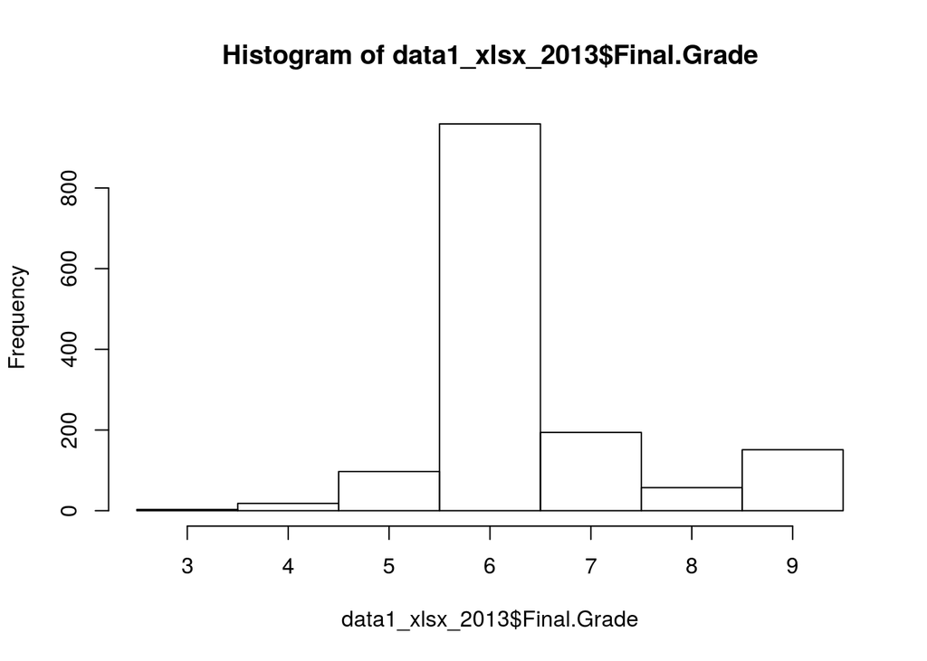

```r
  hist(data1_xlsx_2013$Final.Grade,breaks = seq(2.5,9.5,by = 1))
```

Now, for an easier notatation let us rename columns and levels according to the following logic. For this year I will use Status1 Status2 and Status3 to indicate the status in each of the files and the corresponding levels will be Yes or No. Similarly the Grade columns will be Grade1, Grade2 and Grade3, and for a more compact notation “Reference” will be “Ref”:

```r
  colnames(data1_xlsx_2013)[1]<- "Ref"
  colnames(data1_xlsx_2013)[3]<- "Status1"
  colnames(data1_xlsx_2013)[4]<- "Grade1"
  colnames(data1_xlsx_2013)
```

```
## [1] "Ref"     "Name"    "Status1" "Grade1"
```

```r
  levels(data1_xlsx_2013$Status1)[1] <- "Yes"
  levels(data1_xlsx_2013$Status1)[2] <- "No"
  levels(data1_xlsx_2013$Status1)
```

```
## [1] "Yes" "No"
```

As a consistency check let us see if the the candidates are ordered correctly

```r
  unique(data1_xlsx_2013$Grade1-sort(data1_xlsx_2013$Grade1,decreasing=TRUE))
```

```
## [1] 0
```

### 2.1.2 Ranked list after appeals

** DOWNLOAD ** We downloaded the raw data from the direct link at

```r
  file2_url_2013 <- "https://www.fct.pt/apoios/contratacaodoutorados/investigador-fct/2013/docs/IF2013-ListaOrdenadaAposAP-RankedListAfterAppeals-Locked.xlsx"
```

and chose the filename

```r
  file2_name_2013 <- "2013-file2-all_candidates_after_appeal.xlsx"
```

To download we call:

```r
  file2_rel_path_2013<-make_data_file_download(raw_dir, sub_dir2013, file2_url_2013,file2_name_2013)
```

**CLEANUP**

Now we load the file

```r
  data2_xlsx_2013 <- read.xlsx(file2_rel_path_2013,sheetIndex = 1,startRow = 3)[,1:4]
```

The structure is

```r
  str(data2_xlsx_2013)
```

```
## 'data.frame':    1480 obs. of  4 variables:
##  $ Referência...Reference : Factor w/ 1480 levels "IF/00003/2013",..: 13 15 20 23 24 29 36 38 42 49 ...
##  $ Candidato...Applicant  : Factor w/ 1480 levels "Adelino Dias Cardoso",..: 599 752 419 601 597 1299 1040 1203 1152 346 ...
##  $ Classificação...Score  : num  9 9 9 9 9 9 9 9 9 9 ...
##  $ Financiamento...Funding: Factor w/ 5 levels "Desisitiu / Withdrew",..: 5 5 5 5 5 5 5 5 5 5 ...
```

The levels for the Reference and Name seem OK because they are all unique as expected. Let us check the levels for what we will call Grade2 and Status2:

```r
  unique(data2_xlsx_2013$Classificação...Score)
```

```
## [1] 9 8 7 6 5 4 3
```

```r
  levels(data2_xlsx_2013$Financiamento...Funding)
```

```
## [1] "Desisitiu / Withdrew" "Excluída / Excluded"  "Excluído / Excluded"
## [4] "Não"                  "Sim / Yes"
```

The score are all good and numeric so we can just rename the column. The Grade has two more cases in practice (because the gender is not specified for all cases anyway). Let us first rename the columns:

```r
  colnames(data2_xlsx_2013)[1]<- "Ref"
  colnames(data2_xlsx_2013)[2]<- "Name"
  colnames(data2_xlsx_2013)[3]<- "Grade2"
  colnames(data2_xlsx_2013)[4]<- "Status2"
  colnames(data2_xlsx_2013)
```

```
## [1] "Ref"     "Name"    "Grade2"  "Status2"
```

Now let us simplify the Status2 information

```r
  levels(data2_xlsx_2013$Status2)[1] <- "Quit"
  levels(data2_xlsx_2013$Status2)[2] <- "Excluded"
  levels(data2_xlsx_2013$Status2)[4] <- "No"
  levels(data2_xlsx_2013$Status2)[5] <- "Yes"
  levels(data2_xlsx_2013$Status2)[3] <- "Excluded"
  levels(data2_xlsx_2013$Status2)
```

```
## [1] "Quit"     "Excluded" "No"       "Yes"
```

Let us histogram to make sure everything is OK

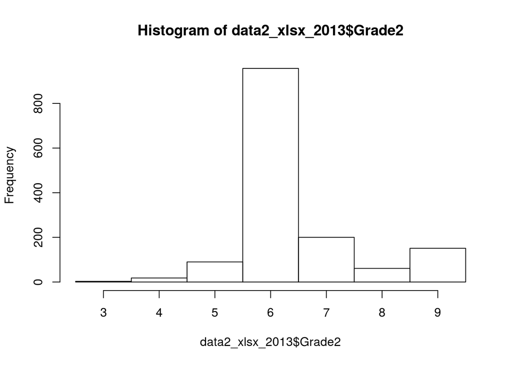

```r
  hist(data2_xlsx_2013$Grade2,breaks = seq(2.5,9.5,by = 1))
```

As a consistency check let us see if the the candidates are ordered correctly

```r
  unique(data2_xlsx_2013$Grade2-sort(data2_xlsx_2013$Grade2,decreasing=TRUE))
```

```
## [1]  0 -1  1  2
```

The discrepancy is due to the “Excluded” or “Quit” cases. Let us eliminate that from the verification

```r
  valid_2013_file2 <- as.logical((data2_xlsx_2013$Status2!="Excluded")*(data2_xlsx_2013$Status2!="Quit"))
  unique(data2_xlsx_2013[valid_2013_file2,"Grade2"]-sort(data2_xlsx_2013[valid_2013_file2,"Grade2"],decreasing=TRUE))
```

```
## [1] 0
```

### 2.1.3 Ranked list final

**DOWNLOAD**

We downloaded the raw data from the direct link at

```r
  file3_url_2013 <- "https://www.fct.pt/apoios/contratacaodoutorados/investigador-fct/2013/docs/IF2013-ListaOrdenadaFinal-RankedListFinal-Locked.xlsx"
```

and chose the filename

```r
  file3_name_2013 <- "2013-file3-all_candidates_final.xlsx"
```

To download we call:

```r
  file3_rel_path_2013 <- make_data_file_download(raw_dir, sub_dir2013, file3_url_2013,file3_name_2013)
```

**CLEANUP**

Now we load the file

```r
  data3_xlsx_2013 <- read.xlsx(file3_rel_path_2013,sheetIndex = 1,startRow = 3)[,1:4]
```

The structure is

```r
  str(data3_xlsx_2013)
```

```
## 'data.frame':    1480 obs. of  4 variables:
##  $ Referência...Reference                     : Factor w/ 1480 levels "IF/00003/2013",..: 13 15 20 23 24 29 36 38 42 49 ...
##  $ Candidato...Applicant                      : Factor w/ 1480 levels "Adelino Dias Cardoso",..: 599 752 419 601 597 1299 1040 1203 1152 346 ...
##  $ Classificação...Score                      : num  9 9 9 9 9 9 9 9 9 9 ...
##  $ Decisão.de.Financiamento...Funding.decision: Factor w/ 5 levels "Desisitiu / Withdrew",..: 5 5 5 5 5 5 5 5 5 5 ...
```

The levels for the Reference and Name seem OK because they are all unique as expected. Let us check the levels for what we will call Grade3 and Status3:

```r
  unique(data3_xlsx_2013$Classificação...Score)
```

```
## [1] 9 8 7 6 5 4 3
```

```r
  levels(data3_xlsx_2013$Decisão.de.Financiamento...Funding.decision)
```

```
## [1] "Desisitiu / Withdrew" "Excluída / Excluded"  "Excluído / Excluded"
## [4] "Não/No"               "Sim/Yes"
```

The score are all good and numeric so we can just rename the column. The Grade has two more cases in practice (because the gender is not specified for all cases anyway). Let us first rename the columns:

```r
  colnames(data3_xlsx_2013)[1]<- "Ref"
  colnames(data3_xlsx_2013)[2]<- "Name"
  colnames(data3_xlsx_2013)[3]<- "Grade3"
  colnames(data3_xlsx_2013)[4]<- "Status3"
  colnames(data3_xlsx_2013)
```

```
## [1] "Ref"     "Name"    "Grade3"  "Status3"
```

Now let us simplify the Status3 information

```r
  levels(data3_xlsx_2013$Status3)[1] <- "Quit"
  levels(data3_xlsx_2013$Status3)[2] <- "Excluded"
  levels(data3_xlsx_2013$Status3)[4] <- "No"
  levels(data3_xlsx_2013$Status3)[5] <- "Yes"
  levels(data3_xlsx_2013$Status3)[3] <- "Excluded"
  levels(data3_xlsx_2013$Status3)
```

```
## [1] "Quit"     "Excluded" "No"       "Yes"
```

Let us histogram to make sure everything is OK

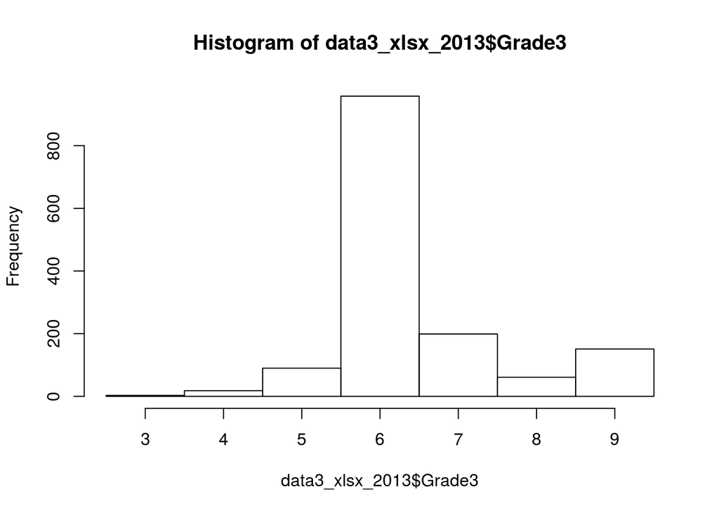

```r
  hist(data3_xlsx_2013$Grade3,breaks = seq(2.5,9.5,by = 1))
```

As a consistency check let us see if the the candidates are ordered correctly

```r
  unique(data3_xlsx_2013$Grade3-sort(data3_xlsx_2013$Grade3,decreasing=TRUE))
```

```
## [1]  0 -1  1  2
```

The discrepancy is due to the “Excluded” or “Quit” cases. Let us eliminate that from the verification

```r
  valid_2013_file3 <- as.logical((data3_xlsx_2013$Status3!="Excluded")*(data3_xlsx_2013$Status3!="Quit"))
  unique(data3_xlsx_2013[valid_2013_file3,"Grade3"]-sort(data3_xlsx_2013[valid_2013_file3,"Grade3"],decreasing=TRUE))
```

```
## [1] 0
```

### 2.1.4 Changes from file1 to file2 and file3 and final dataset

At this point we suspect that file 2 and file 3 are basically the same. Let us check

```r
  sum(data2_xlsx_2013[order(data2_xlsx_2013$Ref),"Ref"] ==data3_xlsx_2013[order(data3_xlsx_2013$Ref),"Ref"])
```

```
## [1] 1480
```

```r
  sum(data2_xlsx_2013[order(data2_xlsx_2013$Ref),"Grade2"] ==data3_xlsx_2013[order(data3_xlsx_2013$Ref),"Grade3"])
```

```
## [1] 1479
```

```r
  sum(data2_xlsx_2013[order(data2_xlsx_2013$Ref),"Status2"] ==data3_xlsx_2013[order(data3_xlsx_2013$Ref),"Status3"])
```

```
## [1] 1480
```

So we see that there was only one change in grade. Let us see which record this is

```r
  record_changef2f3_2013 <- !(data2_xlsx_2013[order(data2_xlsx_2013$Ref),"Grade2"] ==data3_xlsx_2013[order(data3_xlsx_2013$Ref),"Grade3"])
  data2_xlsx_2013[order(data2_xlsx_2013$Ref),][record_changef2f3_2013,]
```

```
##               Ref                           Name Grade2 Status2
## 241 IF/00229/2013 HERVE DIDIER CHRISTOPHE BAUDRY      7      No
```

```r
  data3_xlsx_2013[order(data3_xlsx_2013$Ref),][record_changef2f3_2013,]
```

```
##               Ref                           Name Grade3 Status3
## 412 IF/00229/2013 HERVE DIDIER CHRISTOPHE BAUDRY      6      No
```

Thus, we can safely just use file1 and file3. First we check that all candidates are in both so that we can compare directly

```r
  dim(data1_xlsx_2013)
```

```
## [1] 1479    4
```

```r
  dim(data3_xlsx_2013)
```

```
## [1] 1480    4
```

So there is one record missing in data1. We need to find which one

```r
  missing_in_file1_2013 <- setdiff(data3_xlsx_2013$Ref,data1_xlsx_2013$Ref)
  data3_xlsx_2013[data3_xlsx_2013$Ref==missing_in_file1_2013,]
```

```
##                Ref                                      Name Grade3
## 1461 IF/00122/2013 Martim Afonso Ferreira de Sousa Chichorro      4
##      Status3
## 1461      No
```

Now we can check the amount of differences if we eliminate this record.

```r
  data3_temp_2013 <-data3_xlsx_2013[-1461,]
  data3_temp_2013$Ref<-factor(data3_temp_2013$Ref)
  dim(data3_temp_2013)
```

```
## [1] 1479    4
```

```r
  sum(data1_xlsx_2013[order(data1_xlsx_2013$Ref),"Ref"] ==data3_temp_2013[order(data3_temp_2013$Ref),"Ref"])
```

```
## [1] 1479
```

```r
  sum(data1_xlsx_2013[order(data1_xlsx_2013$Ref),"Grade1"] ==data3_temp_2013[order(data3_temp_2013$Ref),"Grade3"])
```

```
## [1] 1459
```

So we can see that changes in grade were minor. In any case let us see these cases.

```r
  grade_changef1f3_2013 <- !(data1_xlsx_2013[order(data1_xlsx_2013$Ref),"Grade1"] ==data3_temp_2013[order(data3_temp_2013$Ref),"Grade3"])
  side_by_side_2013_changes <-data1_xlsx_2013[order(data1_xlsx_2013$Ref),][grade_changef1f3_2013,c("Ref","Name","Grade1")]
  side_by_side_2013_changes$Grade3 <-data3_temp_2013[order(data3_temp_2013$Ref),][grade_changef1f3_2013,"Grade3"]
  side_by_side_2013_changes$Status1 <-data1_xlsx_2013[order(data1_xlsx_2013$Ref),][grade_changef1f3_2013,"Status1"]
  side_by_side_2013_changes$Status3 <-data3_temp_2013[order(data3_temp_2013$Ref),][grade_changef1f3_2013,"Status3"]
  side_by_side_2013_changes
```

```
##                Ref                                                  Name
## 413  IF/00021/2013                        Catarina Maria Batista Vinagre
## 427  IF/00060/2013                                      Franklin Gregory
## 440  IF/00086/2013                           Sergio Filipe Maia de Sousa
## 445  IF/00099/2013                 João Manuel Monteiro da Costa e Silva
## 1372 IF/00218/2013                               VASCO JOÃO CABRAL DE SÁ
## 232  IF/00229/2013                        HERVE DIDIER CHRISTOPHE BAUDRY
## 1374 IF/00247/2013                                  Mariana Emilia Ghica
## 571  IF/00350/2013                         Pedro Jorge Fonseca Madureira
## 1383 IF/00369/2013                         Cláudia Cristina Lage Pereira
## 1462 IF/00405/2013                           Hileia Karla Silva de Souza
## 253  IF/00407/2013              Teresa Alexandra Peixoto da Rocha Santos
## 1385 IF/00470/2013                Maria Teresa Martins da Cunha Oliveira
## 1387 IF/00485/2013 Maria da Conceição da Silva Carvalho Burguete Martins
## 662  IF/00549/2013            Amélia Paula Martins Marinho Dias dos Reis
```

[output cut: 27 more lines]

So there are only a few cases of changes in the mark of the candidate after the appeal. We can histogram the differences

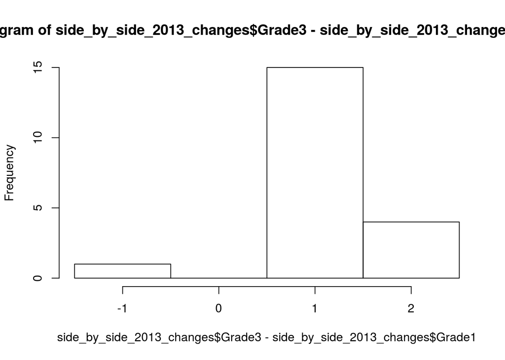

```r
  hist(side_by_side_2013_changes$Grade3-side_by_side_2013_changes$Grade1,breaks = seq(-1.5,2.5,by = 1))
```

```r
  side_by_side_2013_changes$Grade3-side_by_side_2013_changes$Grade1
```

```
##  [1]  2  1  1  1  1 -1  1  1  1  2  1  1  1  1  1  2  2  1  1  1
```

Finally we want to export a single file with all the information. But we are missing the ranking information which is implicit in the file and can be relevant. So firt we add a column

```r
  data1_xlsx_2013$Rank1 = 1:(dim(data1_xlsx_2013)[1])
  head(data1_xlsx_2013)
```

```
##             Ref                                          Name Status1
## 1 IF/00016/2013                                    Ivan Yudin     Yes
## 2 IF/00019/2013                Lilia de Fatima Gomes Perfeito     Yes
## 3 IF/00028/2013 Eurico Manuel Januário Rodrigues Morais de Sá     Yes
## 4 IF/00031/2013                Ivo Manuel Mimoso Vieira Chelo     Yes
## 5 IF/00032/2013                       Iva Hristova Pashkuleva     Yes
## 6 IF/00039/2013              Sara Guilherme Oliveira da Silva     Yes
##   Grade1 Rank1
## 1      9     1
## 2      9     2
## 3      9     3
## 4      9     4
## 5      9     5
## 6      9     6
```

```r
  data3_temp_2013$Rank3 = 1:(dim(data3_temp_2013)[1])
  head(data3_temp_2013)
```

```
##             Ref                                          Name Grade3
## 1 IF/00016/2013                                    Ivan Yudin      9
## 2 IF/00019/2013                Lilia de Fatima Gomes Perfeito      9
## 3 IF/00028/2013 Eurico Manuel Januário Rodrigues Morais de Sá      9
## 4 IF/00031/2013                Ivo Manuel Mimoso Vieira Chelo      9
## 5 IF/00032/2013                       Iva Hristova Pashkuleva      9
## 6 IF/00039/2013              Sara Guilherme Oliveira da Silva      9
##   Status3 Rank3
## 1     Yes     1
## 2     Yes     2
## 3     Yes     3
## 4     Yes     4
## 5     Yes     5
## 6     Yes     6
```

We make a data frame ordered by Ref with the candidate that was missing excluded

```r
  data_2013 <- data1_xlsx_2013[order(data1_xlsx_2013$Ref),c("Ref","Name","Grade1")]
  data_2013$Grade3<-data3_temp_2013[order(data3_temp_2013$Ref),][,"Grade3"]
  data_2013$Status1 <- data1_xlsx_2013[order(data1_xlsx_2013$Ref),"Status1"]
  data_2013$Status3<-data3_temp_2013[order(data3_temp_2013$Ref),][,"Status3"]
  data_2013$Rank1 <- data1_xlsx_2013[order(data1_xlsx_2013$Ref),"Rank1"]
  data_2013$Rank3<-data3_temp_2013[order(data3_temp_2013$Ref),][,"Rank3"]
  head(data_2013)
```

```
##               Ref                                      Name Grade1 Grade3
## 209 IF/00003/2013                 André Martinho De Almeida      7      7
## 403 IF/00004/2013                    Susana de Sousa Araujo      6      6
## 404 IF/00005/2013        Christoph Friedrich Johannes Meyer      6      6
## 210 IF/00006/2013 Jorge Almiro Barceló Caldeira Pinto Paiva      7      7
## 405 IF/00007/2013              Rui Miguel Macieira de Faria      6      6
## 406 IF/00008/2013                       André Gama Oliveira      6      6
##     Status1 Status3 Rank1 Rank3
## 209      No      No   209   215
## 403      No      No   403   413
## 404      No      No   404   414
## 210      No      No   210   216
## 405      No      No   405   415
## 406      No      No   406   416
```

**Panel info** Before exporting we will add the panel information from the auxiliary FCT file

```r
  data_which_panel_2013 <- read.xlsx(path_panel_info_2013,sheetIndex = 1,startRow = 1)[,1:3]
  colnames(data_which_panel_2013)<-c("Ref","Name","Panel")
```

Now we convert the panel names to a Standardized notation.

```r
  sort(levels(data_which_panel_2013$Panel))
```

```
## [1] "Agricultural Sciences"       "Engineering and Technology"
## [3] "Exact Sciences"              "Humanities"
## [5] "Medical and Health Sciences" "Natural Sciences"
## [7] "Social Sciences"
```

```r
  levels(data_which_panel_2013$Panel) <- c("env","eng","sci","hum","med","nat","soc")
  rownames(data_2013)<-c() #This just clears the row names
```

We remove the odd case also from the whic_panel info dataframe

```r
  data_which_panel_2013[data_which_panel_2013$Ref==setdiff(data_which_panel_2013$Ref,data_2013$Ref),]
```

```
##              Ref                                      Name Panel
## 91 IF/00122/2013 Martim Afonso Ferreira de Sousa Chichorro   nat
```

```r
  data_which_panel_2013 <- data_which_panel_2013[-91,]
  data_which_panel_2013$Ref <- factor(data_which_panel_2013$Ref)
  data_which_panel_2013$Name <- factor(data_which_panel_2013$Name)
  rownames(data_which_panel_2013)<- c()
```

Now we check that everything is OK i.e. that the Ref,Name pairs are the same in both dataframes and ordered in the same way.

```r
  sum(data_which_panel_2013[,c("Ref")]!=data_2013[,c("Ref")])
```

```
## [1] 0
```

```r
  diff_names2013 <-as.character(data_which_panel_2013[,c("Name")])!=as.character(data_2013[,c("Name")])
  data.frame(data_which_panel_2013[diff_names2013,c("Name")],data_2013[diff_names2013,c("Name")])
```

```
##    data_which_panel_2013.diff_names2013..c..Name...
## 1                 Cláudia Barreiros Macedo de Faria
## 2                              Uladzimir Khomchanka
## 3                    Andrea Catalina Galvis Sánchez
## 4                              Rafal Marcin Lukasik
## 5              Ana Filipa Naughton Henriques Andrez
## 6                        Carla Sofia da Silva Lopes
## 7                Sonia Maria Almeida Guedes de Melo
## 8                                David Cecil Cairns
## 9               Ana Margarida Vicente Cavaco Guerra
## 10                             Gopal Shankar Mishra
## 11                                   Gersende Prior
## 12                   Slavka Carvalho Andrejkovicova
## 13                                Ivan Franco Rodil
## 14                            Erkuden Perez Carrera
```

[output cut: 19 more lines]

We see that there are some typos in 16 names but all references match so we can just add an extra column with the panel information to the final data frame:

```r
  data_2013$Panel <- data_which_panel_2013$Panel
  head(data_2013)
```

```
##             Ref                                      Name Grade1 Grade3
## 1 IF/00003/2013                 André Martinho De Almeida      7      7
## 2 IF/00004/2013                    Susana de Sousa Araujo      6      6
## 3 IF/00005/2013        Christoph Friedrich Johannes Meyer      6      6
## 4 IF/00006/2013 Jorge Almiro Barceló Caldeira Pinto Paiva      7      7
## 5 IF/00007/2013              Rui Miguel Macieira de Faria      6      6
## 6 IF/00008/2013                       André Gama Oliveira      6      6
##   Status1 Status3 Rank1 Rank3 Panel
## 1      No      No   209   215   env
## 2      No      No   403   413   env
## 3      No      No   404   414   nat
## 4      No      No   210   216   env
## 5      No      No   405   415   nat
## 6      No      No   406   416   sci
```

**EXPORT** I will write all clean data in the directory:

```r
  clean_data_dir <- "clean_data"
```

For the 2013 data I will use

```r
  clean_data_subdir2013 <- "2013"
```

Now we create the directory tree:

```r
  make_data_sub_directory(clean_data_dir,clean_data_subdir2013)
```

```
## [1] "clean_data/2013"
```

And export the clean data file

```r
  write.csv(data_2013,paste(clean_data_dir,"/",clean_data_subdir2013,"/clean_data2013.csv", sep = ""),row.names = FALSE)
```

Q: The mistakes seem to always disfavour candidates? (i.e. the score goes up).

## 2.2 IF competition 2014

In this year and following the competition became a two stage process. The sub-directory name for the data for this year was chosen to be named

```r
  sub_dir2014 <- "2014"
```

### 2.2.1 Stage 1

#### 2.2.1.1 Before appeal

**DOWNLOAD**

We downloaded the raw data from the direct link at

```r
  file1_stage1_url_2014 <- "https://www.fct.pt/apoios/contratacaodoutorados/investigador-fct/2014/docs/IF2014_1stStageResultsAfterEvaluation-locked.xlsx"
```

and chose the filename

```r
  file1_stage1_name_2014 <- "2014-file1-stage1-all_candidates_before_appeal.xlsx"
```

To download we call:

```r
  file1_stage1_rel_path_2014<-make_data_file_download(raw_dir, sub_dir2014, file1_stage1_url_2014,file1_stage1_name_2014)
```

There is an auxiliary file that I asked from FCT with the panel information for each candidate. It is located at the relative path

```r
  path_panel_info_2014 <- "raw_data/data_email_fct_panels/ListaCandidaturas_IF2014.xlsx"
```

**CLEANUP**

Now we load the file

```r
  data1_stage1_xlsx_2014 <- read.xlsx(file1_stage1_rel_path_2014,sheetIndex = 1,startRow = 3, endRow = 1401)[,1:5]
```

The structure is

```r
  str(data1_stage1_xlsx_2014)
```

```
## 'data.frame':    1398 obs. of  5 variables:
##  $ Referência...Reference                              : Factor w/ 1398 levels "IF/00003/2014",..: 15 88 411 431 447 524 569 573 677 684 ...
##  $ Nome...Applicant.s.name                             : Factor w/ 1398 levels "Adelino Dias Cardoso",..: 1161 120 558 1375 552 118 5 853 92 1340 ...
##  $ Instituição.de.Acolhimento...Host.Institution       : Factor w/ 256 levels "Associação de Estudos e de Investigação Científica do ISLA Lisboa (AEIC)",..: 166 205 207 26 126 166 166 53 17 19 ...
##  $ Classificação.proposta...Recommended.score          : Factor w/ 18 levels "1","1.5","2",..: 17 17 17 17 17 17 17 17 17 17 ...
##  $ X.2ª.fase.Elegibilidade....Elegibility.for.Stage.2..: Factor w/ 2 levels "Admitido/ Admitted",..: 1 1 1 1 1 1 1 1 1 1 ...
```

```r
  head(data1_stage1_xlsx_2014)
```

```
##   Referência...Reference                Nome...Applicant.s.name
## 1          IF/00021/2014           Ricardo Jorge Leal Silvestre
## 2          IF/00109/2014 Ana Rita Guerreiro de Brito Petronilho
## 3          IF/00532/2014            Isabel Antunes Mendes Gordo
## 4          IF/00560/2014            Victor Constantin Diculescu
## 5          IF/00578/2014                 Irina de Sousa Moreira
## 6          IF/00680/2014                   Ana Rita Cruz Duarte
##            Instituição.de.Acolhimento...Host.Institution
## 1          ICVS/3B`s - Laboratório Associado (ICVS/3B`s)
## 2 Instituto de Tecnologia Química e Biológica (ITQB/UNL)
## 3              Instituto Gulbenkian de Ciência (IGC/FCG)
## 4           Centro de Engenharia Mecânica (CEMUC/FCT/UC)
## 5   Centro de Neurociências e Biologia Celular (CNBC/UC)
## 6          ICVS/3B`s - Laboratório Associado (ICVS/3B`s)
##   Classificação.proposta...Recommended.score
## 1                                          9
## 2                                          9
## 3                                          9
## 4                                          9
## 5                                          9
## 6                                          9
##   X.2ª.fase.Elegibilidade....Elegibility.for.Stage.2..
## 1                                   Admitido/ Admitted
## 2                                   Admitido/ Admitted
## 3                                   Admitido/ Admitted
## 4                                   Admitido/ Admitted
## 5                                   Admitido/ Admitted
## 6                                   Admitido/ Admitted
```

```r
  tail(data1_stage1_xlsx_2014)
```

```
##      Referência...Reference       Nome...Applicant.s.name
## 1393          IF/00693/2014                  Marco Grossi
## 1394          IF/01191/2014 Nuno Filipe Camarneiro Mendes
## 1395          IF/01334/2014        Raquel Rodriguez Monje
## 1396          IF/01339/2014            Nathan David Roche
## 1397          IF/01368/2014    Gueorgui Kostov Gueorguiev
## 1398          IF/01497/2014          Thomas Charles Scott
##                               Instituição.de.Acolhimento...Host.Institution
## 1393                Faculdade de Ciências da Universidade de Lisboa (FC/UL)
## 1394 Centro de Investigação em Materiais Cerâmicos e Compósitos (CICECO/UA)
## 1395                Faculdade de Ciências da Universidade de Lisboa (FC/UL)
## 1396                                        Centro de Astrofísica (CAUP/UP)
## 1397                            Centro de Física Computacional (CFC/FCT/UC)
## 1398                                        Centro de Astrofísica (CAUP/UP)
##      Classificação.proposta...Recommended.score
## 1393                                       NULL
## 1394                                       NULL
## 1395                                       NULL
## 1396                                       NULL
## 1397                                       NULL
## 1398                                       NULL
##      X.2ª.fase.Elegibilidade....Elegibility.for.Stage.2..
## 1393                           Não Admitido/ Not Admitted
## 1394                           Não Admitido/ Not Admitted
## 1395                           Não Admitido/ Not Admitted
## 1396                           Não Admitido/ Not Admitted
## 1397                           Não Admitido/ Not Admitted
## 1398                           Não Admitido/ Not Admitted
```

The levels for the Reference and Name seem OK because they are all unique as expected. For convenience we now rename the columns:

```r
  colnames(data1_stage1_xlsx_2014) <-c("Ref","Name","Host","Grade1","Status1")
```

Let us check the levels for Status and Final.Grade:

```r
  levels(data1_stage1_xlsx_2014$Status1)
```

```
## [1] "Admitido/ Admitted"         "Não Admitido/ Not Admitted"
```

```r
  levels(data1_stage1_xlsx_2014$Grade1)
```

```
##  [1] "1"    "1.5"  "2"    "2.5"  "3"    "3.5"  "4"    "4.5"  "5"    "5.5"
## [11] "6"    "6.5"  "7"    "7.5"  "8"    "8.5"  "9"    "NULL"
```

For a uniform notation we rename the levels for the status

```r
  levels(data1_stage1_xlsx_2014$Status1)[1]<- "Yes"
  levels(data1_stage1_xlsx_2014$Status1)[2]<- "No"
```

And the values for the grade to numeric

```r
  data1_stage1_xlsx_2014$Grade1 <- as.numeric(as.character(data1_stage1_xlsx_2014$Grade1))
```

Let us histogram to make sure everything is OK

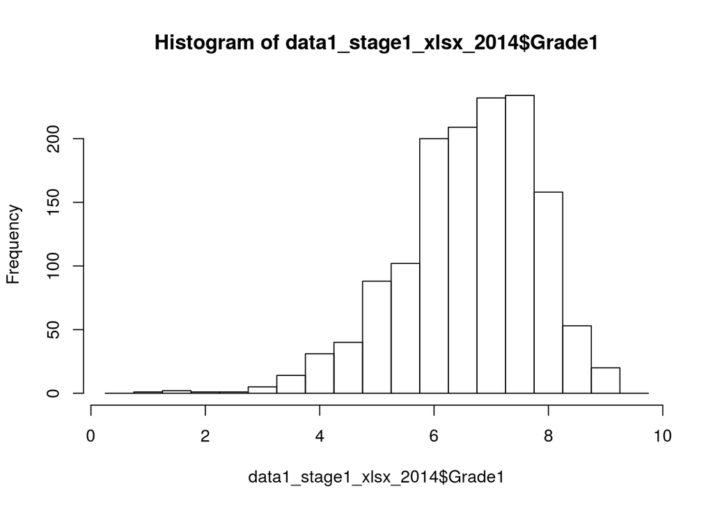

```r
  hist(data1_stage1_xlsx_2014$Grade1,breaks = seq(0.25,9.75,by = 0.5))
```

As a consistency check let us see if the the candidates are ordered correctly (removing the NA values)

```r
  unique(data1_stage1_xlsx_2014$Grade1[!is.na(data1_stage1_xlsx_2014$Grade1)]-sort(data1_stage1_xlsx_2014$Grade1[!is.na(data1_stage1_xlsx_2014$Grade1)],decreasing=TRUE))
```

```
## [1] 0
```

#### 2.2.1.2 After appeal

**DOWNLOAD**

We downloaded the raw data from the direct link at

```r
  file2_stage1_url_2014 <- "https://www.fct.pt/apoios/contratacaodoutorados/investigador-fct/2014/docs/IF2014_1stStageFinalResults-locked.xls"
```

and chose the filename

```r
  file2_stage1_name_2014 <- "2014-file2-stage1-all_candidates_after_appeal.xlsx"
```

To download we call:

```r
  file2_stage1_rel_path_2014<-make_data_file_download(raw_dir, sub_dir2014, file2_stage1_url_2014,file2_stage1_name_2014)
```

**CLEANUP**

Now we load the file and organise the global sheet

```r
  data2_stage1_xlsx_2014 <- read.xlsx(file2_stage1_rel_path_2014,sheetIndex = 1,startRow = 3, endRow = 1401)[,1:5]
```

The structure is

```r
  str(data2_stage1_xlsx_2014)
```

```
## 'data.frame':    1398 obs. of  5 variables:
##  $ Referência...Reference                            : Factor w/ 1398 levels "IF/00003/2014",..: 15 88 411 431 447 524 569 573 677 684 ...
##  $ Nome.Candidato...Applicant.s.name                 : Factor w/ 1398 levels "Adelino Dias Cardoso",..: 1161 120 558 1375 552 118 5 853 92 1340 ...
##  $ Instituição.de.Acolhimento...Host.Institution     : Factor w/ 256 levels "Associação de Estudos e de Investigação Científica do ISLA Lisboa (AEIC)",..: 166 205 207 26 126 166 166 53 17 19 ...
##  $ Classificação.proposta.Recommended.score          : Factor w/ 18 levels "1","1.5","2",..: 17 17 17 17 17 17 17 17 17 17 ...
##  $ X.2ª.fase.Elegibilidade....Elegibility.for.Stage.2: Factor w/ 2 levels "Admitido/ Admitted",..: 1 1 1 1 1 1 1 1 1 1 ...
```

The levels for the Reference and Name seem OK because they are all unique as expected. For convenience we now rename the columns:

```r
  colnames(data2_stage1_xlsx_2014) <-c("Ref","Name","Host","Grade2","Status2")
```

Let us check the levels for Status and Final.Grade:

```r
  levels(data2_stage1_xlsx_2014$Status2)
```

```
## [1] "Admitido/ Admitted"         "Não Admitido/ Not Admitted"
```

```r
  levels(data2_stage1_xlsx_2014$Grade2)
```

```
##  [1] "1"    "1.5"  "2"    "2.5"  "3"    "3.5"  "4"    "4.5"  "5"    "5.5"
## [11] "6"    "6.5"  "7"    "7.5"  "8"    "8.5"  "9"    "NULL"
```

For a uniform notation we rename the levels for the status

```r
  levels(data2_stage1_xlsx_2014$Status2)[1]<- "Yes"
  levels(data2_stage1_xlsx_2014$Status2)[2]<- "No"
```

And the values for the grade to numeric

```r
  data2_stage1_xlsx_2014$Grade2 <- as.numeric(as.character(data2_stage1_xlsx_2014$Grade2))
```

Let us histogram to make sure everything is OK

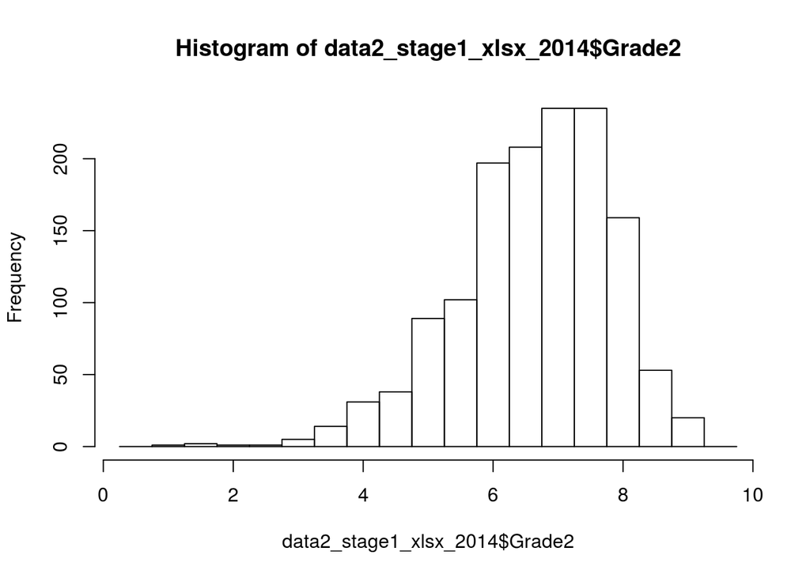

```r
  hist(data2_stage1_xlsx_2014$Grade2,breaks = seq(0.25,9.75,by = 0.5))
```

As a consistency check let us see if the the candidates are ordered correctly (removing the NA values)

```r
  unique(data2_stage1_xlsx_2014$Grade2[!is.na(data2_stage1_xlsx_2014$Grade2)]-sort(data2_stage1_xlsx_2014$Grade2[!is.na(data2_stage1_xlsx_2014$Grade2)],decreasing=TRUE))
```

```
## [1] 0
```

#### 2.2.1.3 After complaint

**DOWNLOAD**

We downloaded the raw data from the direct link at

```r
  file3_stage1_url_2014 <- "https://www.fct.pt/apoios/contratacaodoutorados/investigador-fct/2014/docs/IF2014_1stStageFinalList-locked.xlsx"
```

and chose the filename

```r
  file3_stage1_name_2014 <- "2014-file3-stage1-all_candidates_after_complaint.xlsx"
```

To download we call:

```r
  file3_stage1_rel_path_2014<-make_data_file_download(raw_dir, sub_dir2014, file3_stage1_url_2014,file3_stage1_name_2014)
```

**CLEANUP**

Now we load the file and organise the global sheet

```r
  data3_stage1_xlsx_2014 <- read.xlsx(file3_stage1_rel_path_2014,sheetIndex = 1,startRow = 3, endRow = 517)[,1:4]
```

The structure is

```r
  str(data3_stage1_xlsx_2014)
```

```
## 'data.frame':    514 obs. of  4 variables:
##  $ Referência...Reference                       : Factor w/ 514 levels "IF/00003/2014",..: 216 260 371 197 35 311 396 165 153 485 ...
##  $ Nome.Candidato...Applicant.s.name            : Factor w/ 514 levels "Adelino Dias Cardoso",..: 3 33 41 42 44 126 192 201 204 210 ...
##  $ Instituição.de.Acolhimento...Host.Institution: Factor w/ 147 levels "Associação do Instituto Superior Técnico para a Investigação e o Desenvolvimento (IST-ID)",..: 87 7 58 87 117 77 69 69 119 3 ...
##  $ Classificação.proposta.Recommended.score     : num  9 9 9 9 9 9 9 9 9 9 ...
```

The levels for the Reference and Name seem OK because they are all unique as expected. For convenience we now rename the columns:

```r
  colnames(data3_stage1_xlsx_2014) <-c("Ref","Name","Host","Grade3")
```

Let us check the values:

```r
  unique(data3_stage1_xlsx_2014$Grade3)
```

```
## [1] 9.0 8.5 8.0 7.5 7.0
```

Let us histogram to make sure everything is OK

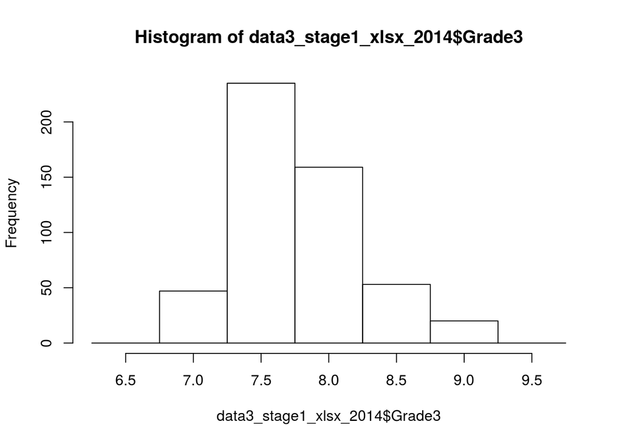

```r
  hist(data3_stage1_xlsx_2014$Grade3,breaks = seq(6.25,9.75,by = 0.5))
```

As a consistency check let us see if the the candidates are ordered correctly

```r
  unique(data3_stage1_xlsx_2014$Grade3-sort(data3_stage1_xlsx_2014$Grade3,decreasing=TRUE))
```

```
## [1] 0
```

### 2.2.2 Stage 2

#### 2.2.2.1 Before appeal

**DOWNLOAD**

We downloaded the raw data from the direct link at

```r
  file1_stage2_url_2014 <- "https://www.fct.pt/apoios/contratacaodoutorados/investigador-fct/2014/docs/IF2014_2ndStageResults-locked.xls"
```

and chose the filename

```r
  file1_stage2_name_2014 <- "2014-file1-stage2-all_candidates_before_appeal.xlsx"
```

To download we call:

```r
  file1_stage2_rel_path_2014<-make_data_file_download(raw_dir, sub_dir2014, file1_stage2_url_2014,file1_stage2_name_2014)
```

**CLEANUP**

Now we load the file and organise the global sheet

```r
  data1_stage2_xlsx_2014_global <- read.xlsx(file1_stage2_rel_path_2014,sheetIndex = 1,startRow = 7, endRow = 519)[,1:4]
```

The structure is

```r
  str(data1_stage2_xlsx_2014_global)
```

```
## 'data.frame':    512 obs. of  4 variables:
##  $ Referência...Reference                       : Factor w/ 512 levels "IF/00003/2014",..: 5 9 11 35 39 46 49 55 70 72 ...
##  $ Nome.Candidato...Applicant.s.name            : Factor w/ 512 levels "Adelino Dias Cardoso",..: 249 447 239 44 504 62 74 54 433 187 ...
##  $ Instituição.de.Acolhimento...Host.Institution: Factor w/ 147 levels "Associação do Instituto Superior Técnico para a Investigação e o Desenvolvimento (IST-ID)",..: 111 3 137 117 90 123 111 136 123 34 ...
##  $ Classificação.proposta.Overall.score         : num  9 9 9 9 9 9 9 9 9 9 ...
```

The levels for the Reference and Name seem OK because two candidates quit the competition and the remaining 512 are all unique as expected. For convenience we now rename the columns:

```r
  colnames(data1_stage2_xlsx_2014_global) <-c("Ref","Name","Host","Grade4")
```

Let us check the values:

```r
  unique(data1_stage2_xlsx_2014_global$Grade4)
```

```
## [1] 9 8 7 6 5
```

Let us histogram to make sure everything is OK

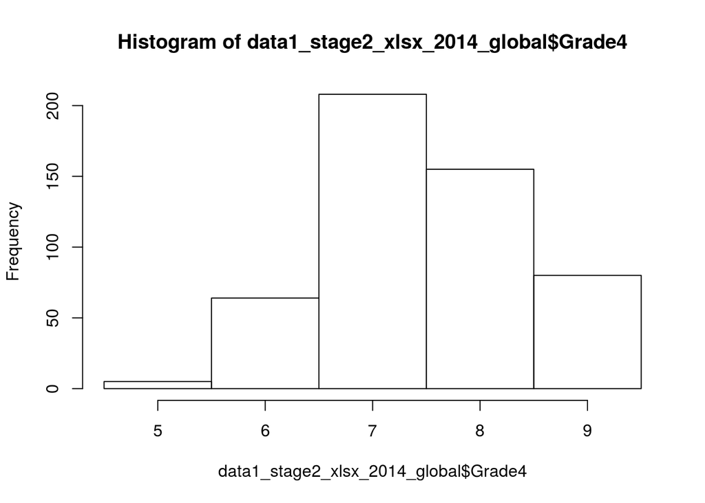

```r
  hist(data1_stage2_xlsx_2014_global$Grade4,breaks = seq(4.5,9.5,by = 1))
```

As a consistency check let us see if the the candidates are ordered correctly

```r
  unique(data1_stage2_xlsx_2014_global$Grade4-sort(data1_stage2_xlsx_2014_global$Grade4,decreasing=TRUE))
```

```
## [1] 0
```

But now, in this stage we have information for the various individual panels with detailed scores. Let us load this information. To make the process less cumbersome we first create a function

```r
  load_panel2014<- function(round,input_file,panel_name,sheet_num, start_row, end_row, ncolumns){
    # read data
    data <- read.xlsx(input_file,sheetIndex = sheet_num,startRow = start_row, endRow = end_row)[,1:ncolumns]
    # Rename columns
    colnames(data)<-c("Ref","Name","Host",paste("WGrade",round,sep = ""),paste("Grade",round,sep = ""),paste("Status",round,sep = ""))
    # Remove the level "Yes*" to be "Yes" and "*" to "Reserve"
    #levels(data[[paste("Status",round,sep = "")]])<-c("Reserve","No","Yes","Yes")
    levels(data[[paste("Status",round,sep = "")]])[tolower(levels(data[[paste("Status",round,sep = "")]]))=="yes"]<-"Yes"
    levels(data[[paste("Status",round,sep = "")]])[tolower(levels(data[[paste("Status",round,sep = "")]]))=="yes*"]<-"Yes"
    levels(data[[paste("Status",round,sep = "")]])[tolower(levels(data[[paste("Status",round,sep = "")]]))=="*"]<-"Reserve"
    levels(data[[paste("Status",round,sep = "")]])[tolower(levels(data[[paste("Status",round,sep = "")]]))=="no"]<-"No"
    data$Panel <- rep(panel_name,dim(data)[1])
    data[[paste("PanelRank",round,sep = "")]]<- 1:(dim(data)[1])
    # Return data frame after checks
    data
  }
```

** Exact Sciences **

```r
  data1_stage2_xlsx_2014_sci <-load_panel2014("4",file1_stage2_rel_path_2014,"sci",2,7,106,6)
  str(data1_stage2_xlsx_2014_sci)
```

```
## 'data.frame':    99 obs. of  8 variables:
##  $ Ref       : Factor w/ 99 levels "IF/00009/2014",..: 18 51 94 2 35 89 8 73 74 44 ...
##  $ Name      : Factor w/ 99 levels "Alexandra Martins da Silva",..: 78 50 16 85 39 41 7 57 66 20 ...
##  $ Host      : Factor w/ 45 levels "Associação do Instituto Superior Técnico para a Investigação e o Desenvolvimento (IST-ID)",..: 9 38 3 3 21 3 35 41 42 8 ...
##  $ WGrade4   : num  9 9 9 8.9 8.9 8.9 8.6 8.6 8.6 8.5 ...
##  $ Grade4    : num  9 9 9 9 9 9 9 9 9 9 ...
##  $ Status4   : Factor w/ 3 levels "Reserve","No",..: 3 3 3 3 3 3 3 3 3 3 ...
##  $ Panel     : chr  "sci" "sci" "sci" "sci" ...
##  $ PanelRank4: int  1 2 3 4 5 6 7 8 9 10 ...
```

```r
  head(data1_stage2_xlsx_2014_sci)
```

```
##             Ref                              Name
## 1 IF/00347/2014      Pedro José Gonçalves Ribeiro
## 2 IF/00820/2014               Lorenzo Cazon Boado
## 3 IF/01710/2014       Carlos Manuel Correia Silva
## 4 IF/00028/2014 Sergio Antonio Goncalves de Sousa
## 5 IF/00578/2014            Irina de Sousa Moreira
## 6 IF/01654/2014                  Jarle Brinchmann
##                                                                      Host
## 1           Centro de Física e Engenharia de Materiais Avançados (CeFEMA)
## 2 Laboratório de Instrumentação e Física Experimental de Partículas (LIP)
## 3                                         Centro de Astrofísica (CAUP/UP)
## 4                                         Centro de Astrofísica (CAUP/UP)
## 5                    Centro de Neurociências e Biologia Celular (CNBC/UC)
## 6                                         Centro de Astrofísica (CAUP/UP)
##   WGrade4 Grade4 Status4 Panel PanelRank4
## 1     9.0      9     Yes   sci          1
## 2     9.0      9     Yes   sci          2
## 3     9.0      9     Yes   sci          3
## 4     8.9      9     Yes   sci          4
## 5     8.9      9     Yes   sci          5
## 6     8.9      9     Yes   sci          6
```

```r
  tail(data1_stage2_xlsx_2014_sci)
```

```
##              Ref                                     Name
## 94 IF/01443/2014                Marta C. Parracho C.Corvo
## 95 IF/01691/2014            Sílvia Cristina Cláudio Nunes
## 96 IF/00098/2014            Pedro Miguel da Silva Martins
## 97 IF/00806/2014                       Dmytro S. Nesterov
## 98 IF/00568/2014 Paula Cristina Ferreira da Silva Brandao
## 99 IF/00491/2014                     Sónia Duarte Barroso
##                                                                                               Host
## 94 REQUIMTE (Rede de Química e Tecnologia) - Laboratório Associado para a Química Verde (REQUIMTE)
## 95                                                            Universidade da Beira Interior (UBI)
## 96                                        Instituto de Ciências Biomédicas Abel Salazar (ICBAS/UP)
## 97                                                      Centro de Química Estrutural (CQE/IST/UTL)
## 98                          Centro de Investigação em Materiais Cerâmicos e Compósitos (CICECO/UA)
## 99                                                      Centro de Química Estrutural (CQE/IST/UTL)
##    WGrade4 Grade4 Status4 Panel PanelRank4
## 94     6.5      7 Reserve   sci         94
## 95     6.5      7 Reserve   sci         95
## 96     6.2      6      No   sci         96
## 97     6.1      6      No   sci         97
## 98     5.7      6      No   sci         98
## 99     5.6      6      No   sci         99
```

** Engineering and Technology **

```r
  data1_stage2_xlsx_2014_eng <-load_panel2014("4",file1_stage2_rel_path_2014,"eng",3,7,96,6)
  str(data1_stage2_xlsx_2014_eng)
```

```
## 'data.frame':    89 obs. of  8 variables:
##  $ Ref       : Factor w/ 89 levels "IF/00036/2014",..: 25 87 20 77 85 2 7 88 6 8 ...
##  $ Name      : Factor w/ 89 levels "Albino Manuel Pereira Martins",..: 12 44 19 43 45 8 5 55 53 39 ...
##  $ Host      : Factor w/ 37 levels "Centro de Biologia Molecular e Ambiental (CBMA)",..: 14 26 32 34 10 17 26 35 20 26 ...
##  $ WGrade4   : num  9 9 8.9 8.6 8.5 8.1 8.1 8.1 8 8 ...
##  $ Grade4    : num  9 9 9 9 9 8 8 8 8 8 ...
##  $ Status4   : Factor w/ 3 levels "Reserve","No",..: 3 3 3 3 3 3 3 3 3 3 ...
##  $ Panel     : chr  "eng" "eng" "eng" "eng" ...
##  $ PanelRank4: int  1 2 3 4 5 6 7 8 9 10 ...
```

```r
  head(data1_stage2_xlsx_2014_eng)
```

```
##             Ref                                         Name
## 1 IF/00680/2014                         Ana Rita Cruz Duarte
## 2 IF/01741/2014              Ligia Maria de Oliveira Martins
## 3 IF/00514/2014          Cláudia Sofia Castro Gomes da Silva
## 4 IF/01595/2014                                   Lifeng Liu
## 5 IF/01712/2014                       Lino da Silva Ferreira
## 6 IF/00048/2014 Ana Margarida Nunes da Mata Pires de Azevedo
##                                                           Host WGrade4
## 1                ICVS/3B`s - Laboratório Associado (ICVS/3B`s)     9.0
## 2       Instituto de Tecnologia Química e Biológica (ITQB/UNL)     9.0
## 3 Laboratório de Processos de Separação e Reacção (LSRE/FE/UP)     8.9
## 4   Laboratório Ibérico Internacional de Nanotecnologias (INL)     8.6
## 5         Centro de Neurociências e Biologia Celular (CNBC/UC)     8.5
## 6             Instituto de Biotecnologia e Bioengenharia (IBB)     8.1
##   Grade4 Status4 Panel PanelRank4
## 1      9     Yes   eng          1
## 2      9     Yes   eng          2
## 3      9     Yes   eng          3
## 4      9     Yes   eng          4
## 5      9     Yes   eng          5
## 6      8     Yes   eng          6
```

```r
  tail(data1_stage2_xlsx_2014_eng)
```

```
##              Ref                                   Name
## 84 IF/01103/2014      Ana Paula Valagão Amadeu do Serro
## 85 IF/00158/2014                   Mariana Emilia Ghica
## 86 IF/01042/2014            Pedro António Palma Madeira
## 87 IF/00910/2014                  Joao Oliveira Ventura
## 88 IF/01502/2014 Pedro Alexandre Lopes de Sousa Martins
## 89 IF/01614/2014                Rui Pedro da Costa Neto
##                                                                   Host
## 84                          Centro de Química Estrutural (CQE/IST/UTL)
## 85                                         Instituto Pedro Nunes (IPN)
## 86        Laboratório de Processos de Separação e Reacção (LSRE/FE/UP)
## 87                                        Instituto de Nanotecnologias
## 88     Instituto de Engenharia Mecânica e Gestão Industrial (INEGI/UP)
## 89 Laboratório Associado de Energia, Transportes e Aeronáutica (LAETA)
##    WGrade4 Grade4 Status4 Panel PanelRank4
## 84     6.8      6      No   eng         84
## 85     6.5      6      No   eng         85
## 86     6.5      6      No   eng         86
## 87     6.0      6      No   eng         87
## 88     6.0      6      No   eng         88
## 89     6.0      6      No   eng         89
```

** Medical Health Sciences **

```r
  data1_stage2_xlsx_2014_med <-load_panel2014("4",file1_stage2_rel_path_2014,"med",4,7,71,6)
  str(data1_stage2_xlsx_2014_med)
```

```
## 'data.frame':    64 obs. of  8 variables:
##  $ Ref       : Factor w/ 64 levels "IF/00004/2014",..: 10 26 64 2 36 22 1 5 34 57 ...
##  $ Name      : Factor w/ 64 levels "Agostinho Albérico Rodrigues de Carvalho",..: 12 42 64 31 19 20 32 52 1 21 ...
##  $ Host      : Factor w/ 22 levels "Centro de Engenharia Biológica da Universidade do Minho (CEB/UM)",..: 11 11 11 11 11 2 11 7 7 7 ...
##  $ WGrade4   : num  8.9 8.6 8.6 8.5 8.5 8.2 8.5 8.5 8.5 8.5 ...
##  $ Grade4    : num  9 9 9 9 9 9 8 8 8 8 ...
##  $ Status4   : Factor w/ 3 levels "Reserve","No",..: 3 3 3 3 3 3 3 3 3 3 ...
##  $ Panel     : chr  "med" "med" "med" "med" ...
##  $ PanelRank4: int  1 2 3 4 5 6 7 8 9 10 ...
```

```r
  head(data1_stage2_xlsx_2014_med)
```

```
##             Ref                                         Name
## 1 IF/00166/2014              Bruno Miguel Bernardes de Jesus
## 2 IF/00595/2014                     Nuno Luís Barbosa Morais
## 3 IF/01693/2014 Vanessa Alexandra dos Santos Morais Epifanio
## 4 IF/00013/2014                                  Julie Ribot
## 5 IF/00787/2014                      Diana Maria Pinto Prata
## 6 IF/00501/2014                Duarte Custal Ferreira Barral
##                                                    Host WGrade4 Grade4
## 1           Instituto de Medicina Molecular (IMM/FM/UL)     8.9      9
## 2           Instituto de Medicina Molecular (IMM/FM/UL)     8.6      9
## 3           Instituto de Medicina Molecular (IMM/FM/UL)     8.6      9
## 4           Instituto de Medicina Molecular (IMM/FM/UL)     8.5      9
## 5           Instituto de Medicina Molecular (IMM/FM/UL)     8.5      9
## 6 Centro de Estudos de Doenças Crónicas (CEDOC/FCM/UNL)     8.2      9
##   Status4 Panel PanelRank4
## 1     Yes   med          1
## 2     Yes   med          2
## 3     Yes   med          3
## 4     Yes   med          4
## 5     Yes   med          5
## 6     Yes   med          6
```

```r
  tail(data1_stage2_xlsx_2014_med)
```

```
##              Ref                                   Name
## 59 IF/00317/2014           SÓNIA CARINA MORAIS DA SILVA
## 60 IF/00379/2014                 Maria João Jorge Pinho
## 61 IF/00939/2014                Jorge Valero Gómez-Lobo
## 62 IF/00391/2014 Maria Teresa Martins da Cunha Oliveira
## 63 IF/01397/2014       Luis Miguel Andrade de Magalhães
## 64 IF/00719/2014                 Salomé Soares de Pinho
##                                                                                               Host
## 59                                Centro de Engenharia Biológica da Universidade do Minho (CEB/UM)
## 60                               Instituto Biomédico de Investigação de Luz e Imagem (IBILI/FM/UC)
## 61                                            Centro de Neurociências e Biologia Celular (CNBC/UC)
## 62                                            Centro de Neurociências e Biologia Celular (CNBC/UC)
## 63 REQUIMTE (Rede de Química e Tecnologia) - Laboratório Associado para a Química Verde (REQUIMTE)
## 64                                     Instituto de Patologia e Imunologia Molecular (IPATIMUP/UP)
##    WGrade4 Grade4 Status4 Panel PanelRank4
## 59     6.6      7 Reserve   med         59
## 60     6.6      7 Reserve   med         60
## 61     6.6      7 Reserve   med         61
## 62     6.2      7 Reserve   med         62
## 63     6.6      6      No   med         63
## 64     6.5      6      No   med         64
```

** Environmental Agricultural Sciences **

```r
  data1_stage2_xlsx_2014_env <-load_panel2014("4",file1_stage2_rel_path_2014,"env",5,7,75,6)
  str(data1_stage2_xlsx_2014_env)
```

```
## 'data.frame':    68 obs. of  8 variables:
##  $ Ref       : Factor w/ 68 levels "IF/00010/2014",..: 20 38 13 30 45 49 56 15 17 57 ...
##  $ Name      : Factor w/ 68 levels "Ana Alexandra Figueiredo Matias",..: 43 24 14 15 44 53 37 32 20 58 ...
##  $ Host      : Factor w/ 31 levels "Centro de Biotecnologia e Química Fina (CBQF/ESB/UCP)",..: 1 22 17 12 2 30 22 17 30 22 ...
##  $ WGrade4   : num  9 9 8.9 8.9 8.9 8.9 8.9 8.8 8.8 8.8 ...
##  $ Grade4    : num  9 9 9 9 9 9 9 9 9 9 ...
##  $ Status4   : Factor w/ 3 levels "Reserve","No",..: 3 3 3 3 3 3 3 3 3 3 ...
##  $ Panel     : chr  "env" "env" "env" "env" ...
##  $ PanelRank4: int  1 2 3 4 5 6 7 8 9 10 ...
```

```r
  head(data1_stage2_xlsx_2014_env)
```

```
##             Ref                                      Name
## 1 IF/00506/2014 Marta Wilton Pereira Leite de Vasconcelos
## 2 IF/00764/2014          Isabel Alexandra Aguiar de Abreu
## 3 IF/00311/2014                          Eric claude Font
## 4 IF/00661/2014                               Erwan GAREL
## 5 IF/00998/2014              Mercedes Gonzalez Wanguemert
## 6 IF/01054/2014            Paulo Alexandre da Costa Lemos
##                                                                                              Host
## 1                                           Centro de Biotecnologia e Química Fina (CBQF/ESB/UCP)
## 2                                          Instituto de Tecnologia Química e Biológica (ITQB/UNL)
## 3                                         Faculdade de Ciências da Universidade de Lisboa (FC/UL)
## 4                                     Centro de Investigação Marinha e Ambiental (CIMA/FCMA/UAlg)
## 5                                                         Centro de Ciências do Mar (CCMar/CIMAR)
## 6 REQUIMTE (Rede de Química e Tecnologia) - Laboratório Associado para a Química Verde (REQUIMTE)
##   WGrade4 Grade4 Status4 Panel PanelRank4
## 1     9.0      9     Yes   env          1
## 2     9.0      9     Yes   env          2
## 3     8.9      9     Yes   env          3
## 4     8.9      9     Yes   env          4
## 5     8.9      9     Yes   env          5
## 6     8.9      9     Yes   env          6
```

```r
  tail(data1_stage2_xlsx_2014_env)
```

```
##              Ref                              Name
## 63 IF/00010/2014           Pedro Manuel Broa Costa
## 64 IF/00340/2014 Maria Teresa Gomes Afonso do Paço
## 65 IF/00667/2014    Ana Catarina Ferreira da Silva
## 66 IF/00911/2014         Pedro Miguel Matos Soares
## 67 IF/00947/2014                 Marta Mega Rufino
## 68 IF/00236/2014   Patricia Sofia Matos dos Santos
##                                                       Host WGrade4 Grade4
## 63                IMAR - Centro do Mar e Ambiente (CMA/UC)     6.1      6
## 64            Centro de Engenharia dos Biossistemas (CEER)     6.1      6
## 65                   Centro de Geo-Sistemas (CVRM/IST/UTL)     6.1      6
## 66 Faculdade de Ciências da Universidade de Lisboa (FC/UL)     6.1      6
## 67 Instituto Português do Mar e da Atmosfera, I. P. (IPMA)     6.1      6
## 68       Centro de Estudos do Ambiente e do Mar (CESAM/UA)     6.0      6
##    Status4 Panel PanelRank4
## 63      No   env         63
## 64      No   env         64
## 65      No   env         65
## 66      No   env         66
## 67      No   env         67
## 68      No   env         68
```

** Natural Animal Sciences **

```r
  data1_stage2_xlsx_2014_nat <-load_panel2014("4",file1_stage2_rel_path_2014,"nat",6,7,93,6)
  str(data1_stage2_xlsx_2014_nat)
```

```
## 'data.frame':    86 obs. of  8 variables:
##  $ Ref       : Factor w/ 86 levels "IF/00003/2014",..: 42 7 9 13 19 21 55 68 78 82 ...
##  $ Name      : Factor w/ 86 levels "Afonso Miguel dos Santos Duarte",..: 14 85 8 60 46 35 71 47 63 23 ...
##  $ Host      : Factor w/ 32 levels "Centro de Biologia Ambiental (CBA/FC/UL)",..: 28 16 27 27 30 24 5 13 11 28 ...
##  $ WGrade4   : num  9 8.6 8.6 8.6 8.6 8.6 8.6 8.6 8.6 8.6 ...
##  $ Grade4    : num  9 9 9 9 9 9 9 9 9 9 ...
##  $ Status4   : Factor w/ 2 levels "Reserve","Yes": 2 2 2 2 2 2 2 2 2 2 ...
##  $ Panel     : chr  "nat" "nat" "nat" "nat" ...
##  $ PanelRank4: int  1 2 3 4 5 6 7 8 9 10 ...
```

```r
  head(data1_stage2_xlsx_2014_nat)
```

```
##             Ref                            Name
## 1 IF/00866/2014            Catarina Jorge Ginja
## 2 IF/00129/2014 Verónica Jacinta Lopes Ferreira
## 3 IF/00209/2014               Angelica Crottini
## 4 IF/00283/2014     Miguel Jorge Pinto Carneiro
## 5 IF/00437/2014        Liana Casquinha da Silva
## 6 IF/00532/2014     Isabel Antunes Mendes Gordo
##                                                                                 Host
## 1 Rede de Investigação em Biodiversidade e Biologia Evolutiva (InBIO/ICETA-Porto/UP)
## 2                                           IMAR - Centro do Mar e Ambiente (CMA/UC)
## 3                        Rede de Investigação em Biodiversidade e Biologia Evolutiva
## 4                        Rede de Investigação em Biodiversidade e Biologia Evolutiva
## 5             Research Institute for Medicines and Pharmaceutical Sciences (iMed.UL)
## 6                                          Instituto Gulbenkian de Ciência (IGC/FCG)
##   WGrade4 Grade4 Status4 Panel PanelRank4
## 1     9.0      9     Yes   nat          1
## 2     8.6      9     Yes   nat          2
## 3     8.6      9     Yes   nat          3
## 4     8.6      9     Yes   nat          4
## 5     8.6      9     Yes   nat          5
## 6     8.6      9     Yes   nat          6
```

```r
  tail(data1_stage2_xlsx_2014_nat)
```

```
##              Ref                                                Name
## 81 IF/00563/2014 Cristina Maria Lourenco da Cunha Correia de Azevedo
## 82 IF/00600/2014                      Nelson Eduardo do Vale Martins
## 83 IF/00976/2014            Maria João de Medeiros Brazão Lopes Feio
## 84 IF/01756/2014                              João José Inácio Silva
## 85 IF/00570/2014     Rita Isabel de Oliveira Soares Branco Domingues
## 86 IF/01197/2014           Herlânder Anselmo Queirós Pereira Azevedo
##                                                                                  Host
## 81                                Instituto de Biologia Molecular e Celular (IBMC/UP)
## 82                                          Instituto Gulbenkian de Ciência (IGC/FCG)
## 83                                           IMAR - Centro do Mar e Ambiente (CMA/UC)
## 84                                Instituto de Higiene e Medicina Tropical (IHMT/UNL)
## 85                        Centro de Investigação Marinha e Ambiental (CIMA/FCMA/UAlg)
## 86 Rede de Investigação em Biodiversidade e Biologia Evolutiva (InBIO/ICETA-Porto/UP)
##    WGrade4 Grade4 Status4 Panel PanelRank4
## 81     6.5      7 Reserve   nat         81
## 82     6.5      7 Reserve   nat         82
## 83     6.5      7 Reserve   nat         83
## 84     6.5      7 Reserve   nat         84
## 85     6.0      7 Reserve   nat         85
## 86     5.7      7 Reserve   nat         86
```

** Social Sciences ** NOTE: In this panel I have removed the last candidate that quit the competition.

```r
  data1_stage2_xlsx_2014_soc <-load_panel2014("4",file1_stage2_rel_path_2014,"soc",7,7,66,6)
  str(data1_stage2_xlsx_2014_soc)
```

```
## 'data.frame':    59 obs. of  8 variables:
##  $ Ref       : Factor w/ 59 levels "IF/00054/2014",..: 49 21 41 57 37 38 6 11 43 8 ...
##  $ Name      : Factor w/ 59 levels "Amilcar Manuel Reis Moreira",..: 10 39 25 7 8 22 28 50 5 59 ...
##  $ Host      : Factor w/ 27 levels "Centro de Economia e Finanças (CEFUP)",..: 10 20 15 16 18 18 18 23 15 11 ...
##  $ WGrade4   : num  9 8.6 8.6 8.6 8.6 8.6 8 8 8 7.6 ...
##  $ Grade4    : num  9 9 9 9 8 8 8 8 8 8 ...
##  $ Status4   : Factor w/ 3 levels "Reserve","No",..: 3 3 3 3 3 3 3 3 3 3 ...
##  $ Panel     : chr  "soc" "soc" "soc" "soc" ...
##  $ PanelRank4: int  1 2 3 4 5 6 7 8 9 10 ...
```

```r
  head(data1_stage2_xlsx_2014_soc)
```

```
##             Ref                       Name
## 1 IF/01405/2014            Ben Mark Harvey
## 2 IF/00513/2014             Manuel adelino
## 3 IF/01219/2014   Eva Martins da Conceição
## 4 IF/01612/2014   André Otelo Paraíba Mata
## 5 IF/01063/2014                Anna Fedele
## 6 IF/01128/2014 Dr Kimberley Jane Hockings
##                                                                                           Host
## 1 Centro de Investigação do Núcleo de Estudos e Intervenção Cognitivo-Comportamental (CINEICC)
## 2                                Faculdade de Economia da Universidade Nova de Lisboa (FE/UNL)
## 3                                              Centro de Investigação em Psicologia (CIPsi/UM)
## 4                               CENTRO DE INVESTIGAÇÂO EM PSICOLOGIA DA UNIVERSIDADE DE LISBOA
## 5                                        Centro em Rede de Investigação em Antropologia (CRIA)
## 6                                        Centro em Rede de Investigação em Antropologia (CRIA)
##   WGrade4 Grade4 Status4 Panel PanelRank4
## 1     9.0      9     Yes   soc          1
## 2     8.6      9     Yes   soc          2
## 3     8.6      9     Yes   soc          3
## 4     8.6      9     Yes   soc          4
## 5     8.6      8     Yes   soc          5
## 6     8.6      8     Yes   soc          6
```

```r
  tail(data1_stage2_xlsx_2014_soc)
```

```
##              Ref                                     Name
## 54 IF/00122/2014        Sandra Raquel Gonçalves Fernandes
## 55 IF/00396/2014        Patrícia Susana Pinho Castanheira
## 56 IF/00927/2014  Carmen Maria de Freitas Diego Gonçalves
## 57 IF/01572/2014                          RICCARDO MARCHI
## 58 IF/00585/2014 Miguel Farinha dos Santos da Silva Graça
## 59 IF/00252/2014                  Filomena Carvalho Sousa
##                                                                                                     Host
## 54                                             Centro de Investigação em Estudos da Criança (CIEC/UM/UM)
## 55                Centro de Investigação em Didáctica e Tecnologia na Formação de Formadores (CIDTFF/UA)
## 56                                                             Centro de Estudos Geográficos (CEG/FL/UL)
## 57                                                                Instituto de Ciências Sociais (ICS/UL)
## 58                                              Centro de Investigação em Engenharia Civil (CIEC/FCT/UC)
## 59 IELT - Instituto de Estudos de Literatura Tradicional - Patrimónios, Artes e Culturas (IELT/FCSH/UNL)
##    WGrade4 Grade4 Status4 Panel PanelRank4
## 54     6.0      6      No   soc         54
## 55     6.0      6      No   soc         55
## 56     6.0      6      No   soc         56
## 57     6.0      6      No   soc         57
## 58     5.7      6      No   soc         58
## 59     5.1      5      No   soc         59
```

** Humanities **

```r
  data1_stage2_xlsx_2014_hum <-load_panel2014("4",file1_stage2_rel_path_2014,"hum",8,8,55,6)
  str(data1_stage2_xlsx_2014_hum)
```

```
## 'data.frame':    47 obs. of  8 variables:
##  $ Ref       : Factor w/ 47 levels "IF/00068/2014",..: 22 25 43 47 16 18 19 34 3 12 ...
##  $ Name      : Factor w/ 47 levels "Adelino Dias Cardoso",..: 14 25 9 7 16 5 37 12 22 2 ...
##  $ Host      : Factor w/ 25 levels "Centro de Estudos Arqueológicos das Universidades de Coimbra e Porto (CEA)",..: 13 21 2 9 21 25 12 18 24 16 ...
##  $ WGrade4   : num  9 9 9 8.9 8.6 8.5 8.5 8.4 8.2 8.1 ...
##  $ Grade4    : num  9 9 9 9 8 8 8 8 8 8 ...
##  $ Status4   : Factor w/ 3 levels "Reserve","No",..: 3 3 3 3 3 3 3 3 3 3 ...
##  $ Panel     : chr  "hum" "hum" "hum" "hum" ...
##  $ PanelRank4: int  1 2 3 4 5 6 7 8 9 10 ...
```

```r
  head(data1_stage2_xlsx_2014_hum)
```

```
##             Ref                                           Name
## 1 IF/00835/2014                   FRANCISCO J MARTINEZ-ANTONIO
## 2 IF/00966/2014 Luís Manuel Duarte Antunes Figueiredo Trindade
## 3 IF/01533/2014                            Eftychia Bathrellou
## 4 IF/01736/2014                                    David Yates
## 5 IF/00631/2014       Helena Sofia Rodrigues Ferreira da Silva
## 6 IF/00709/2014                              Boban Arsenijevic
##                                                                      Host
## 1 Centro Interdisciplinar de História, Culturas e Sociedades (CIDEHUS/UE)
## 2                      Instituto de História Contemporânea (IHC/FCSH/UNL)
## 3                                 Centro de Estudos Clássicos (CEC/FL/UL)
## 4                                             Centro de Filosofia (CF/UL)
## 5                      Instituto de História Contemporânea (IHC/FCSH/UNL)
## 6                                              Universidade do Minho (UM)
##   WGrade4 Grade4 Status4 Panel PanelRank4
## 1     9.0      9     Yes   hum          1
## 2     9.0      9     Yes   hum          2
## 3     9.0      9     Yes   hum          3
## 4     8.9      9     Yes   hum          4
## 5     8.6      8     Yes   hum          5
## 6     8.5      8     Yes   hum          6
```

```r
  tail(data1_stage2_xlsx_2014_hum)
```

```
##              Ref                                                     Name
## 42 IF/01150/2014                              Teresa Salomé Alves da Mota
## 43 IF/01449/2014                                           Samuel GESSNER
## 44 IF/00312/2014                                     Adelino Dias Cardoso
## 45 IF/00504/2014                                         Giuseppina Raggi
## 46 IF/01234/2014                  Catarina Pombo Martins de Castro Nabais
## 47 IF/01701/2014 Patricia Catarina Rosa Silveirinha Pinto Castello Branco
##                                                                       Host
## 42                 Faculdade de Ciências da Universidade de Lisboa (FC/UL)
## 43                 Faculdade de Ciências da Universidade de Lisboa (FC/UL)
## 44                          Centro de História de Além-Mar (CHAM/FCSH/UNL)
## 45                          Centro de História de Além-Mar (CHAM/FCSH/UNL)
## 46 Fundação da Faculdade de Ciências da Universidade de Lisboa (FFC/FC/UL)
## 47                      Instituto de Filosofia da Linguagem (IFL/FCSH/UNL)
##    WGrade4 Grade4 Status4 Panel PanelRank4
## 42     5.6      6      No   hum         42
## 43     5.6      6      No   hum         43
## 44     5.6      5      No   hum         44
## 45     5.5      6      No   hum         45
## 46     5.5      5      No   hum         46
## 47     5.5      5      No   hum         47
```

#### 2.2.2.2 After appeal

** DOWNLOAD**

We downloaded the raw data from the direct link at

```r
  file2_stage2_url_2014 <- "https://www.fct.pt/apoios/contratacaodoutorados/investigador-fct/2014/docs/IF2014_2ndStageResults_AfterAppeals_Locked-230615.xlsx"
```

and chose the filename

```r
  file2_stage2_name_2014 <- "2014-file2-stage2-all_candidates_after_appeal.xlsx"
```

To download we call:

```r
  file2_stage2_rel_path_2014 <- make_data_file_download(raw_dir, sub_dir2014, file2_stage2_url_2014,file2_stage2_name_2014)
```

**CLEANUP**

Now we load the file and organise the global sheet

```r
  data2_stage2_xlsx_2014_global <- read.xlsx(file2_stage2_rel_path_2014,sheetIndex = 1,startRow = 6, endRow = 518)[,1:4]
```

The structure is

```r
  str(data2_stage2_xlsx_2014_global)
```

```
## 'data.frame':    512 obs. of  4 variables:
##  $ Referência...Reference                       : Factor w/ 512 levels "IF/00003/2014",..: 5 9 11 35 39 46 49 55 70 72 ...
##  $ Nome.Candidato...Applicant.s.name            : Factor w/ 512 levels "Adelino Dias Cardoso",..: 249 448 239 44 504 63 75 54 434 186 ...
##  $ Instituição.de.Acolhimento...Host.Institution: Factor w/ 148 levels "Associação do Instituto Superior Técnico para a Investigação e o Desenvolvimento (IST-ID)",..: 111 3 138 117 90 123 111 137 123 34 ...
##  $ Classificação.proposta.Overall.score         : num  9 9 9 9 9 9 9 9 9 9 ...
```

The levels for the Reference and Name seem OK because two candidates quit the competition and the remaining 512 are all unique as expected. For convenience we now rename the columns:

```r
  colnames(data2_stage2_xlsx_2014_global) <-c("Ref","Name","Host","Grade5")
```

Let us check the values:

```r
  unique(data2_stage2_xlsx_2014_global$Grade5)
```

```
## [1] 9 8 7 6 5
```

Let us histogram to make sure everything is OK

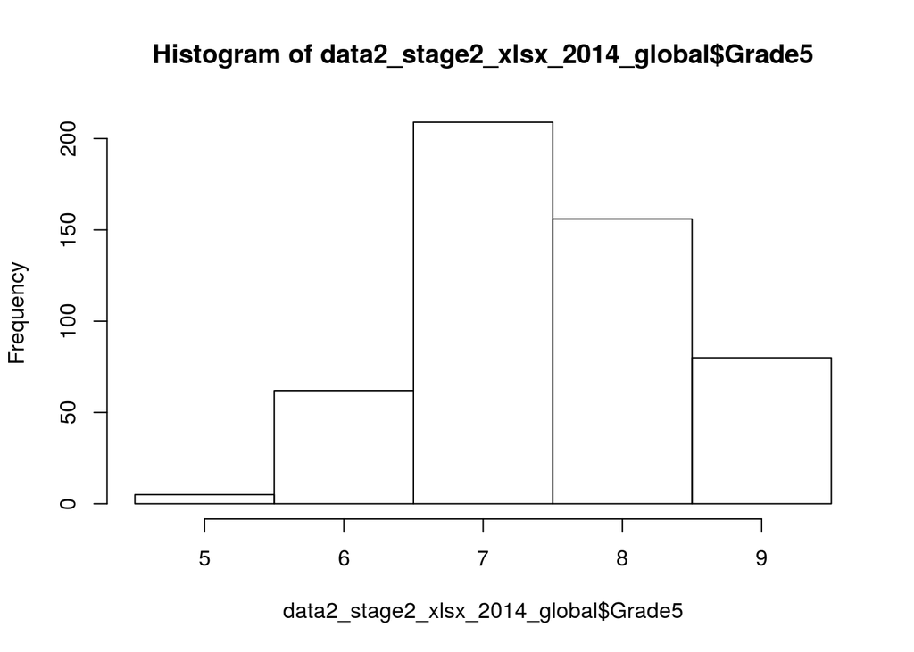

```r
  hist(data2_stage2_xlsx_2014_global$Grade5,breaks = seq(4.5,9.5,by = 1))
```

As a consistency check let us see if the the candidates are ordered correctly

```r
  unique(data2_stage2_xlsx_2014_global$Grade5-sort(data2_stage2_xlsx_2014_global$Grade5,decreasing=TRUE))
```

```
## [1] 0
```

** Exact Sciences **

```r
  data2_stage2_xlsx_2014_sci <-load_panel2014("5",file2_stage2_rel_path_2014,"sci",2,7,106,6)
  str(data2_stage2_xlsx_2014_sci)
```

```
## 'data.frame':    99 obs. of  8 variables:
##  $ Ref       : Factor w/ 99 levels "IF/00009/2014",..: 18 51 94 2 35 89 8 73 74 44 ...
##  $ Name      : Factor w/ 99 levels "Alexandra Martins da Silva",..: 78 50 16 85 39 41 7 57 66 20 ...
##  $ Host      : Factor w/ 45 levels "Associação do Instituto Superior Técnico para a Investigação e o Desenvolvimento (IST-ID)",..: 9 38 3 3 21 3 35 41 42 8 ...
##  $ WGrade5   : num  9 9 9 8.9 8.9 8.9 8.6 8.6 8.6 8.5 ...
##  $ Grade5    : num  9 9 9 9 9 9 9 9 9 9 ...
##  $ Status5   : Factor w/ 3 levels "Reserve","No",..: 3 3 3 3 3 3 3 3 3 3 ...
##  $ Panel     : chr  "sci" "sci" "sci" "sci" ...
##  $ PanelRank5: int  1 2 3 4 5 6 7 8 9 10 ...
```

```r
  head(data2_stage2_xlsx_2014_sci)
```

```
##             Ref                              Name
## 1 IF/00347/2014      Pedro José Gonçalves Ribeiro
## 2 IF/00820/2014               Lorenzo Cazon Boado
## 3 IF/01710/2014       Carlos Manuel Correia Silva
## 4 IF/00028/2014 Sergio Antonio Goncalves de Sousa
## 5 IF/00578/2014            Irina de Sousa Moreira
## 6 IF/01654/2014                  Jarle Brinchmann
##                                                                      Host
## 1           Centro de Física e Engenharia de Materiais Avançados (CeFEMA)
## 2 Laboratório de Instrumentação e Física Experimental de Partículas (LIP)
## 3                                         Centro de Astrofísica (CAUP/UP)
## 4                                         Centro de Astrofísica (CAUP/UP)
## 5                    Centro de Neurociências e Biologia Celular (CNBC/UC)
## 6                                         Centro de Astrofísica (CAUP/UP)
##   WGrade5 Grade5 Status5 Panel PanelRank5
## 1     9.0      9     Yes   sci          1
## 2     9.0      9     Yes   sci          2
## 3     9.0      9     Yes   sci          3
## 4     8.9      9     Yes   sci          4
## 5     8.9      9     Yes   sci          5
## 6     8.9      9     Yes   sci          6
```

```r
  tail(data2_stage2_xlsx_2014_sci)
```

```
##              Ref                                     Name
## 94 IF/01443/2014                Marta C. Parracho C.Corvo
## 95 IF/01691/2014            Sílvia Cristina Cláudio Nunes
## 96 IF/00098/2014            Pedro Miguel da Silva Martins
## 97 IF/00806/2014                       Dmytro S. Nesterov
## 98 IF/00568/2014 Paula Cristina Ferreira da Silva Brandao
## 99 IF/00491/2014                     Sónia Duarte Barroso
##                                                                                               Host
## 94 REQUIMTE (Rede de Química e Tecnologia) - Laboratório Associado para a Química Verde (REQUIMTE)
## 95                                                            Universidade da Beira Interior (UBI)
## 96                                        Instituto de Ciências Biomédicas Abel Salazar (ICBAS/UP)
## 97                                                      Centro de Química Estrutural (CQE/IST/UTL)
## 98                          Centro de Investigação em Materiais Cerâmicos e Compósitos (CICECO/UA)
## 99                                                      Centro de Química Estrutural (CQE/IST/UTL)
##    WGrade5 Grade5 Status5 Panel PanelRank5
## 94     6.5      7 Reserve   sci         94
## 95     6.5      7 Reserve   sci         95
## 96     6.2      6      No   sci         96
## 97     6.1      6      No   sci         97
## 98     5.7      6      No   sci         98
## 99     5.6      6      No   sci         99
```

```r
  levels(data2_stage2_xlsx_2014_sci$Status5)
```

```
## [1] "Reserve" "No"      "Yes"
```

** Engineering and Technology **

```r
  data2_stage2_xlsx_2014_eng <-load_panel2014("5",file2_stage2_rel_path_2014,"eng",3,7,96,6)
  str(data2_stage2_xlsx_2014_eng)
```

```
## 'data.frame':    89 obs. of  8 variables:
##  $ Ref       : Factor w/ 89 levels "IF/00036/2014",..: 25 87 20 77 85 2 7 88 6 8 ...
##  $ Name      : Factor w/ 89 levels "Albino Manuel Pereira Martins",..: 12 45 19 44 46 8 5 56 54 40 ...
##  $ Host      : Factor w/ 37 levels "Centro de Biologia Molecular e Ambiental (CBMA)",..: 14 26 32 34 10 17 26 35 20 26 ...
##  $ WGrade5   : num  9 9 8.9 8.6 8.5 8.1 8.1 8.1 8 8 ...
##  $ Grade5    : num  9 9 9 9 9 8 8 8 8 8 ...
##  $ Status5   : Factor w/ 3 levels "Reserve","No",..: 3 3 3 3 3 3 3 3 3 3 ...
##  $ Panel     : chr  "eng" "eng" "eng" "eng" ...
##  $ PanelRank5: int  1 2 3 4 5 6 7 8 9 10 ...
```

```r
  head(data2_stage2_xlsx_2014_eng)
```

```
##             Ref                                         Name
## 1 IF/00680/2014                         Ana Rita Cruz Duarte
## 2 IF/01741/2014              Ligia Maria de Oliveira Martins
## 3 IF/00514/2014          Cláudia Sofia Castro Gomes da Silva
## 4 IF/01595/2014                                   Lifeng Liu
## 5 IF/01712/2014                       Lino da Silva Ferreira
## 6 IF/00048/2014 Ana Margarida Nunes da Mata Pires de Azevedo
##                                                           Host WGrade5
## 1                ICVS/3B`s - Laboratório Associado (ICVS/3B`s)     9.0
## 2       Instituto de Tecnologia Química e Biológica (ITQB/UNL)     9.0
## 3 Laboratório de Processos de Separação e Reacção (LSRE/FE/UP)     8.9
## 4   Laboratório Ibérico Internacional de Nanotecnologias (INL)     8.6
## 5         Centro de Neurociências e Biologia Celular (CNBC/UC)     8.5
## 6             Instituto de Biotecnologia e Bioengenharia (IBB)     8.1
##   Grade5 Status5 Panel PanelRank5
## 1      9     Yes   eng          1
## 2      9     Yes   eng          2
## 3      9     Yes   eng          3
## 4      9     Yes   eng          4
## 5      9     Yes   eng          5
## 6      8     Yes   eng          6
```

```r
  tail(data2_stage2_xlsx_2014_eng)
```

```
##              Ref                                   Name
## 84 IF/00061/2014    João Manuel do Paço Quesado Delgado
## 85 IF/00158/2014                   Mariana Emilia Ghica
## 86 IF/01042/2014            Pedro António Palma Madeira
## 87 IF/00910/2014                  Joao Oliveira Ventura
## 88 IF/01502/2014 Pedro Alexandre Lopes de Sousa Martins
## 89 IF/01614/2014                Rui Pedro da Costa Neto
##                                                                   Host
## 84            Faculdade de Engenharia da Universidade do Porto (FE/UP)
## 85                                         Instituto Pedro Nunes (IPN)
## 86        Laboratório de Processos de Separação e Reacção (LSRE/FE/UP)
## 87                                        Instituto de Nanotecnologias
## 88     Instituto de Engenharia Mecânica e Gestão Industrial (INEGI/UP)
## 89 Laboratório Associado de Energia, Transportes e Aeronáutica (LAETA)
##    WGrade5 Grade5 Status5 Panel PanelRank5
## 84     7.0      6      No   eng         84
## 85     6.5      6      No   eng         85
## 86     6.5      6      No   eng         86
## 87     6.0      6      No   eng         87
## 88     6.0      6      No   eng         88
## 89     6.0      6      No   eng         89
```

** Medical Health Sciences **

```r
  data2_stage2_xlsx_2014_med <-load_panel2014("5",file2_stage2_rel_path_2014,"med",4,7,71,6)
  str(data2_stage2_xlsx_2014_med)
```

```
## 'data.frame':    64 obs. of  8 variables:
##  $ Ref       : Factor w/ 64 levels "IF/00004/2014",..: 10 26 64 2 36 22 1 5 34 57 ...
##  $ Name      : Factor w/ 64 levels "Agostinho Albérico Rodrigues de Carvalho",..: 12 42 64 31 19 20 32 52 1 21 ...
##  $ Host      : Factor w/ 22 levels "Centro de Engenharia Biológica da Universidade do Minho (CEB/UM)",..: 11 11 11 11 11 2 11 7 7 7 ...
##  $ WGrade5   : num  8.9 8.6 8.6 8.5 8.5 8.2 8.5 8.5 8.5 8.5 ...
##  $ Grade5    : num  9 9 9 9 9 9 8 8 8 8 ...
##  $ Status5   : Factor w/ 3 levels "Reserve","No",..: 3 3 3 3 3 3 3 3 3 3 ...
##  $ Panel     : chr  "med" "med" "med" "med" ...
##  $ PanelRank5: int  1 2 3 4 5 6 7 8 9 10 ...
```

```r
  head(data2_stage2_xlsx_2014_med)
```

```
##             Ref                                         Name
## 1 IF/00166/2014              Bruno Miguel Bernardes de Jesus
## 2 IF/00595/2014                     Nuno Luís Barbosa Morais
## 3 IF/01693/2014 Vanessa Alexandra dos Santos Morais Epifanio
## 4 IF/00013/2014                                  Julie Ribot
## 5 IF/00787/2014                      Diana Maria Pinto Prata
## 6 IF/00501/2014                Duarte Custal Ferreira Barral
##                                                    Host WGrade5 Grade5
## 1           Instituto de Medicina Molecular (IMM/FM/UL)     8.9      9
## 2           Instituto de Medicina Molecular (IMM/FM/UL)     8.6      9
## 3           Instituto de Medicina Molecular (IMM/FM/UL)     8.6      9
## 4           Instituto de Medicina Molecular (IMM/FM/UL)     8.5      9
## 5           Instituto de Medicina Molecular (IMM/FM/UL)     8.5      9
## 6 Centro de Estudos de Doenças Crónicas (CEDOC/FCM/UNL)     8.2      9
##   Status5 Panel PanelRank5
## 1     Yes   med          1
## 2     Yes   med          2
## 3     Yes   med          3
## 4     Yes   med          4
## 5     Yes   med          5
## 6     Yes   med          6
```

```r
  tail(data2_stage2_xlsx_2014_med)
```

```
##              Ref                                   Name
## 59 IF/00317/2014           Sónia Carina Morais da Silva
## 60 IF/00379/2014                 Maria João Jorge Pinho
## 61 IF/00939/2014                Jorge Valero Gómez-Lobo
## 62 IF/00391/2014 Maria Teresa Martins da Cunha Oliveira
## 63 IF/01397/2014       Luis Miguel Andrade de Magalhães
## 64 IF/00719/2014                 Salomé Soares de Pinho
##                                                                                               Host
## 59                                Centro de Engenharia Biológica da Universidade do Minho (CEB/UM)
## 60                               Instituto Biomédico de Investigação de Luz e Imagem (IBILI/FM/UC)
## 61                                            Centro de Neurociências e Biologia Celular (CNBC/UC)
## 62                                            Centro de Neurociências e Biologia Celular (CNBC/UC)
## 63 REQUIMTE (Rede de Química e Tecnologia) - Laboratório Associado para a Química Verde (REQUIMTE)
## 64                                     Instituto de Patologia e Imunologia Molecular (IPATIMUP/UP)
##    WGrade5 Grade5 Status5 Panel PanelRank5
## 59     6.6      7 Reserve   med         59
## 60     6.6      7 Reserve   med         60
## 61     6.6      7 Reserve   med         61
## 62     6.2      7 Reserve   med         62
## 63     6.6      6      No   med         63
## 64     6.5      6      No   med         64
```

** Environmental Agricultural Sciences **

```r
  data2_stage2_xlsx_2014_env <-load_panel2014("5",file2_stage2_rel_path_2014,"env",5,7,75,6)
  str(data2_stage2_xlsx_2014_env)
```

```
## 'data.frame':    68 obs. of  8 variables:
##  $ Ref       : Factor w/ 68 levels "IF/00010/2014",..: 20 38 13 30 45 49 56 15 17 57 ...
##  $ Name      : Factor w/ 68 levels "Ana Alexandra Figueiredo Matias",..: 43 24 14 15 44 53 37 32 20 58 ...
##  $ Host      : Factor w/ 31 levels "Centro de Biotecnologia e Química Fina (CBQF/ESB/UCP)",..: 1 22 17 12 2 30 22 17 30 22 ...
##  $ WGrade5   : num  9 9 8.9 8.9 8.9 8.9 8.9 8.8 8.8 8.8 ...
##  $ Grade5    : num  9 9 9 9 9 9 9 9 9 9 ...
##  $ Status5   : Factor w/ 3 levels "Reserve","No",..: 3 3 3 3 3 3 3 3 3 3 ...
##  $ Panel     : chr  "env" "env" "env" "env" ...
##  $ PanelRank5: int  1 2 3 4 5 6 7 8 9 10 ...
```

```r
  head(data2_stage2_xlsx_2014_env)
```

```
##             Ref                                      Name
## 1 IF/00506/2014 Marta Wilton Pereira Leite de Vasconcelos
## 2 IF/00764/2014          Isabel Alexandra Aguiar de Abreu
## 3 IF/00311/2014                          Eric claude Font
## 4 IF/00661/2014                               Erwan Garel
## 5 IF/00998/2014              Mercedes Gonzalez Wanguemert
## 6 IF/01054/2014            Paulo Alexandre da Costa Lemos
##                                                                                              Host
## 1                                           Centro de Biotecnologia e Química Fina (CBQF/ESB/UCP)
## 2                                          Instituto de Tecnologia Química e Biológica (ITQB/UNL)
## 3                                         Faculdade de Ciências da Universidade de Lisboa (FC/UL)
## 4                                     Centro de Investigação Marinha e Ambiental (CIMA/FCMA/UAlg)
## 5                                                         Centro de Ciências do Mar (CCMar/CIMAR)
## 6 REQUIMTE (Rede de Química e Tecnologia) - Laboratório Associado para a Química Verde (REQUIMTE)
##   WGrade5 Grade5 Status5 Panel PanelRank5
## 1     9.0      9     Yes   env          1
## 2     9.0      9     Yes   env          2
## 3     8.9      9     Yes   env          3
## 4     8.9      9     Yes   env          4
## 5     8.9      9     Yes   env          5
## 6     8.9      9     Yes   env          6
```

```r
  tail(data2_stage2_xlsx_2014_env)
```

```
##              Ref                            Name
## 63 IF/01504/2014     Filipe Manuel Vidas Ribeiro
## 64 IF/00010/2014         Pedro Manuel Broa Costa
## 65 IF/00667/2014  Ana Catarina Ferreira da Silva
## 66 IF/00911/2014       Pedro Miguel Matos Soares
## 67 IF/00947/2014               Marta Mega Rufino
## 68 IF/00236/2014 Patricia Sofia Matos dos Santos
##                                                       Host WGrade5 Grade5
## 63 Faculdade de Ciências da Universidade de Lisboa (FC/UL)     6.2      6
## 64                IMAR - Centro do Mar e Ambiente (CMA/UC)     6.1      6
## 65                   Centro de Geo-Sistemas (CVRM/IST/UTL)     6.1      6
## 66 Faculdade de Ciências da Universidade de Lisboa (FC/UL)     6.1      6
## 67 Instituto Português do Mar e da Atmosfera, I. P. (IPMA)     6.1      6
## 68       Centro de Estudos do Ambiente e do Mar (CESAM/UA)     6.0      6
##    Status5 Panel PanelRank5
## 63      No   env         63
## 64      No   env         64
## 65      No   env         65
## 66      No   env         66
## 67      No   env         67
## 68      No   env         68
```

** Natural Animal Sciences **

```r
  data2_stage2_xlsx_2014_nat <-load_panel2014("5",file2_stage2_rel_path_2014,"nat",6,7,93,6)
  str(data2_stage2_xlsx_2014_nat)
```

```
## 'data.frame':    86 obs. of  8 variables:
##  $ Ref       : Factor w/ 86 levels "IF/00003/2014",..: 42 7 9 13 19 21 55 68 78 82 ...
##  $ Name      : Factor w/ 86 levels "Afonso Miguel dos Santos Duarte",..: 14 85 8 60 46 35 71 47 63 23 ...
##  $ Host      : Factor w/ 32 levels "Centro de Biologia Ambiental (CBA/FC/UL)",..: 28 16 27 27 30 24 5 13 11 28 ...
##  $ WGrade5   : num  9 8.6 8.6 8.6 8.6 8.6 8.6 8.6 8.6 8.6 ...
##  $ Grade5    : num  9 9 9 9 9 9 9 9 9 9 ...
##  $ Status5   : Factor w/ 2 levels "Reserve","Yes": 2 2 2 2 2 2 2 2 2 2 ...
##  $ Panel     : chr  "nat" "nat" "nat" "nat" ...
##  $ PanelRank5: int  1 2 3 4 5 6 7 8 9 10 ...
```

```r
  head(data2_stage2_xlsx_2014_nat)
```

```
##             Ref                            Name
## 1 IF/00866/2014            Catarina Jorge Ginja
## 2 IF/00129/2014 Verónica Jacinta Lopes Ferreira
## 3 IF/00209/2014               Angelica Crottini
## 4 IF/00283/2014     Miguel Jorge Pinto Carneiro
## 5 IF/00437/2014        Liana Casquinha da Silva
## 6 IF/00532/2014     Isabel Antunes Mendes Gordo
##                                                                                 Host
## 1 Rede de Investigação em Biodiversidade e Biologia Evolutiva (InBIO/ICETA-Porto/UP)
## 2                                           IMAR - Centro do Mar e Ambiente (CMA/UC)
## 3                        Rede de Investigação em Biodiversidade e Biologia Evolutiva
## 4                        Rede de Investigação em Biodiversidade e Biologia Evolutiva
## 5             Research Institute for Medicines and Pharmaceutical Sciences (iMed.UL)
## 6                                          Instituto Gulbenkian de Ciência (IGC/FCG)
##   WGrade5 Grade5 Status5 Panel PanelRank5
## 1     9.0      9     Yes   nat          1
## 2     8.6      9     Yes   nat          2
## 3     8.6      9     Yes   nat          3
## 4     8.6      9     Yes   nat          4
## 5     8.6      9     Yes   nat          5
## 6     8.6      9     Yes   nat          6
```

```r
  tail(data2_stage2_xlsx_2014_nat)
```

```
##              Ref                                                Name
## 81 IF/00563/2014 Cristina Maria Lourenco da Cunha Correia de Azevedo
## 82 IF/00600/2014                      Nelson Eduardo do Vale Martins
## 83 IF/00976/2014            Maria João de Medeiros Brazão Lopes Feio
## 84 IF/01756/2014                              João José Inácio Silva
## 85 IF/00570/2014     Rita Isabel de Oliveira Soares Branco Domingues
## 86 IF/01197/2014           Herlânder Anselmo Queirós Pereira Azevedo
##                                                                                  Host
## 81                                Instituto de Biologia Molecular e Celular (IBMC/UP)
## 82                                          Instituto Gulbenkian de Ciência (IGC/FCG)
## 83                                           IMAR - Centro do Mar e Ambiente (CMA/UC)
## 84                                Instituto de Higiene e Medicina Tropical (IHMT/UNL)
## 85                        Centro de Investigação Marinha e Ambiental (CIMA/FCMA/UAlg)
## 86 Rede de Investigação em Biodiversidade e Biologia Evolutiva (InBIO/ICETA-Porto/UP)
##    WGrade5 Grade5 Status5 Panel PanelRank5
## 81     6.5      7 Reserve   nat         81
## 82     6.5      7 Reserve   nat         82
## 83     6.5      7 Reserve   nat         83
## 84     6.5      7 Reserve   nat         84
## 85     6.0      7 Reserve   nat         85
## 86     5.7      7 Reserve   nat         86
```

** Social Sciences ** NOTE: In this panel I have removed the last candidate that quit the competition.

```r
  data2_stage2_xlsx_2014_soc <-load_panel2014("5",file2_stage2_rel_path_2014,"soc",7,7,66,6)
  str(data2_stage2_xlsx_2014_soc)
```

```
## 'data.frame':    59 obs. of  8 variables:
##  $ Ref       : Factor w/ 59 levels "IF/00054/2014",..: 49 21 41 57 37 38 6 11 43 8 ...
##  $ Name      : Factor w/ 59 levels "Amilcar Manuel Reis Moreira",..: 10 39 24 7 8 36 27 50 5 59 ...
##  $ Host      : Factor w/ 27 levels "Centro de Economia e Finanças (CEFUP)",..: 10 20 15 16 18 18 18 23 15 11 ...
##  $ WGrade5   : num  9 8.6 8.6 8.6 8.6 8.6 8 8 8 7.6 ...
##  $ Grade5    : num  9 9 9 9 8 8 8 8 8 8 ...
##  $ Status5   : Factor w/ 3 levels "Reserve","No",..: 3 3 3 3 3 3 3 3 3 3 ...
##  $ Panel     : chr  "soc" "soc" "soc" "soc" ...
##  $ PanelRank5: int  1 2 3 4 5 6 7 8 9 10 ...
```

```r
  head(data2_stage2_xlsx_2014_soc)
```

```
##             Ref                     Name
## 1 IF/01405/2014          Ben Mark Harvey
## 2 IF/00513/2014           Manuel Adelino
## 3 IF/01219/2014 Eva Martins da Conceição
## 4 IF/01612/2014 André Otelo Paraíba Mata
## 5 IF/01063/2014              Anna Fedele
## 6 IF/01128/2014  Kimberley Jane Hockings
##                                                                                           Host
## 1 Centro de Investigação do Núcleo de Estudos e Intervenção Cognitivo-Comportamental (CINEICC)
## 2                                Faculdade de Economia da Universidade Nova de Lisboa (FE/UNL)
## 3                                              Centro de Investigação em Psicologia (CIPsi/UM)
## 4                               CENTRO DE INVESTIGAÇÂO EM PSICOLOGIA DA UNIVERSIDADE DE LISBOA
## 5                                        Centro em Rede de Investigação em Antropologia (CRIA)
## 6                                        Centro em Rede de Investigação em Antropologia (CRIA)
##   WGrade5 Grade5 Status5 Panel PanelRank5
## 1     9.0      9     Yes   soc          1
## 2     8.6      9     Yes   soc          2
## 3     8.6      9     Yes   soc          3
## 4     8.6      9     Yes   soc          4
## 5     8.6      8     Yes   soc          5
## 6     8.6      8     Yes   soc          6
```

```r
  tail(data2_stage2_xlsx_2014_soc)
```

```
##              Ref                                     Name
## 54 IF/00122/2014        Sandra Raquel Gonçalves Fernandes
## 55 IF/00396/2014        Patrícia Susana Pinho Castanheira
## 56 IF/00927/2014  Carmen Maria de Freitas Diego Gonçalves
## 57 IF/01572/2014                          Riccardo Marchi
## 58 IF/00585/2014 Miguel Farinha dos Santos da Silva Graça
## 59 IF/00252/2014                  Filomena Carvalho Sousa
##                                                                                                     Host
## 54                                             Centro de Investigação em Estudos da Criança (CIEC/UM/UM)
## 55                Centro de Investigação em Didáctica e Tecnologia na Formação de Formadores (CIDTFF/UA)
## 56                                                             Centro de Estudos Geográficos (CEG/FL/UL)
## 57                                                                Instituto de Ciências Sociais (ICS/UL)
## 58                                              Centro de Investigação em Engenharia Civil (CIEC/FCT/UC)
## 59 IELT - Instituto de Estudos de Literatura Tradicional - Patrimónios, Artes e Culturas (IELT/FCSH/UNL)
##    WGrade5 Grade5 Status5 Panel PanelRank5
## 54     6.0      6      No   soc         54
## 55     6.0      6      No   soc         55
## 56     6.0      6      No   soc         56
## 57     6.0      6      No   soc         57
## 58     5.7      6      No   soc         58
## 59     5.1      5      No   soc         59
```

** Humanities ** NOTE: Some candidate was eliminated after appeal.

```r
  data2_stage2_xlsx_2014_hum <-load_panel2014("5",file2_stage2_rel_path_2014,"hum",8,7,54,6)
  str(data2_stage2_xlsx_2014_hum)
```

```
## 'data.frame':    47 obs. of  8 variables:
##  $ Ref       : Factor w/ 47 levels "IF/00068/2014",..: 22 25 43 47 16 18 19 34 3 12 ...
##  $ Name      : Factor w/ 47 levels "Adelino Dias Cardoso",..: 14 25 9 7 16 5 37 12 22 2 ...
##  $ Host      : Factor w/ 25 levels "Centro de Estudos Arqueológicos das Universidades de Coimbra e Porto (CEA)",..: 13 21 2 9 21 25 12 18 24 16 ...
##  $ WGrade5   : num  9 9 9 8.9 8.6 8.5 8.5 8.4 8.2 8.1 ...
##  $ Grade5    : num  9 9 9 9 8 8 8 8 8 8 ...
##  $ Status5   : Factor w/ 3 levels "Reserve","No",..: 3 3 3 3 3 3 3 3 3 3 ...
##  $ Panel     : chr  "hum" "hum" "hum" "hum" ...
##  $ PanelRank5: int  1 2 3 4 5 6 7 8 9 10 ...
```

```r
  head(data2_stage2_xlsx_2014_hum)
```

```
##             Ref                                           Name
## 1 IF/00835/2014                   Francisco J Martinez-Antonio
## 2 IF/00966/2014 Luís Manuel Duarte Antunes Figueiredo Trindade
## 3 IF/01533/2014                            Eftychia Bathrellou
## 4 IF/01736/2014                                    David Yates
## 5 IF/00631/2014       Helena Sofia Rodrigues Ferreira da Silva
## 6 IF/00709/2014                              Boban Arsenijevic
##                                                                      Host
## 1 Centro Interdisciplinar de História, Culturas e Sociedades (CIDEHUS/UE)
## 2                      Instituto de História Contemporânea (IHC/FCSH/UNL)
## 3                                 Centro de Estudos Clássicos (CEC/FL/UL)
## 4                                             Centro de Filosofia (CF/UL)
## 5                      Instituto de História Contemporânea (IHC/FCSH/UNL)
## 6                                              Universidade do Minho (UM)
##   WGrade5 Grade5 Status5 Panel PanelRank5
## 1     9.0      9     Yes   hum          1
## 2     9.0      9     Yes   hum          2
## 3     9.0      9     Yes   hum          3
## 4     8.9      9     Yes   hum          4
## 5     8.6      8     Yes   hum          5
## 6     8.5      8     Yes   hum          6
```

```r
  tail(data2_stage2_xlsx_2014_hum)
```

```
##              Ref                                                     Name
## 42 IF/01150/2014                              Teresa Salomé Alves da Mota
## 43 IF/01449/2014                                           Samuel Gessner
## 44 IF/00312/2014                                     Adelino Dias Cardoso
## 45 IF/00504/2014                                         Giuseppina Raggi
## 46 IF/01234/2014                  Catarina Pombo Martins de Castro Nabais
## 47 IF/01701/2014 Patricia Catarina Rosa Silveirinha Pinto Castello Branco
##                                                                       Host
## 42                 Faculdade de Ciências da Universidade de Lisboa (FC/UL)
## 43                 Faculdade de Ciências da Universidade de Lisboa (FC/UL)
## 44                          Centro de História de Além-Mar (CHAM/FCSH/UNL)
## 45                          Centro de História de Além-Mar (CHAM/FCSH/UNL)
## 46 Fundação da Faculdade de Ciências da Universidade de Lisboa (FFC/FC/UL)
## 47                      Instituto de Filosofia da Linguagem (IFL/FCSH/UNL)
##    WGrade5 Grade5 Status5 Panel PanelRank5
## 42     5.6      6      No   hum         42
## 43     5.6      6      No   hum         43
## 44     5.6      5      No   hum         44
## 45     5.5      6      No   hum         45
## 46     5.5      5      No   hum         46
## 47     5.5      5      No   hum         47
```

#### 2.2.2.3 Final results

**DOWNLOAD**

We downloaded the raw data from the direct link at

```r
  file3_stage2_url_2014 <- "https://www.fct.pt/apoios/contratacaodoutorados/investigador-fct/2014/docs/IF2014_2ndStageFinalResults-locked.xlsx"
```

and chose the filename

```r
  file3_stage2_name_2014 <- "2014-file3-stage2-all_candidates_final.xlsx"
```

To download we call:

```r
  file3_stage2_rel_path_2014<-make_data_file_download(raw_dir, sub_dir2014, file3_stage2_url_2014,file3_stage2_name_2014)
```

**CLEANUP**

Now we load the file and organise the global sheet

```r
  data3_stage2_xlsx_2014_global <- read.xlsx(file3_stage2_rel_path_2014,sheetIndex = 1,startRow = 6, endRow = 518)[,1:4]
```

The structure is

```r
  str(data3_stage2_xlsx_2014_global)
```

```
## 'data.frame':    512 obs. of  4 variables:
##  $ Referência...Reference                       : Factor w/ 512 levels "IF/00003/2014",..: 377 480 197 35 81 471 55 435 164 46 ...
##  $ Nome.Candidato...Applicant.s.name            : Factor w/ 512 levels "Adelino Dias Cardoso",..: 6 20 42 44 51 52 54 57 59 63 ...
##  $ Instituição.de.Acolhimento...Host.Institution: Factor w/ 147 levels "Associação do Instituto Superior Técnico para a Investigação e o Desenvolvimento (IST-ID)",..: 114 136 87 117 63 59 136 123 8 123 ...
##  $ Classificação.proposta.Overall.score         : num  9 9 9 9 9 9 9 9 9 9 ...
```

The levels for the Reference and Name seem OK because two candidates quit the competition and the remaining 512 are all unique as expected. For convenience we now rename the columns:

```r
  colnames(data3_stage2_xlsx_2014_global) <-c("Ref","Name","Host","Grade6")
```

Let us check the values:

```r
  unique(data3_stage2_xlsx_2014_global$Grade6)
```

```
## [1] 9 8 7 6 5
```

Let us histogram to make sure everything is OK

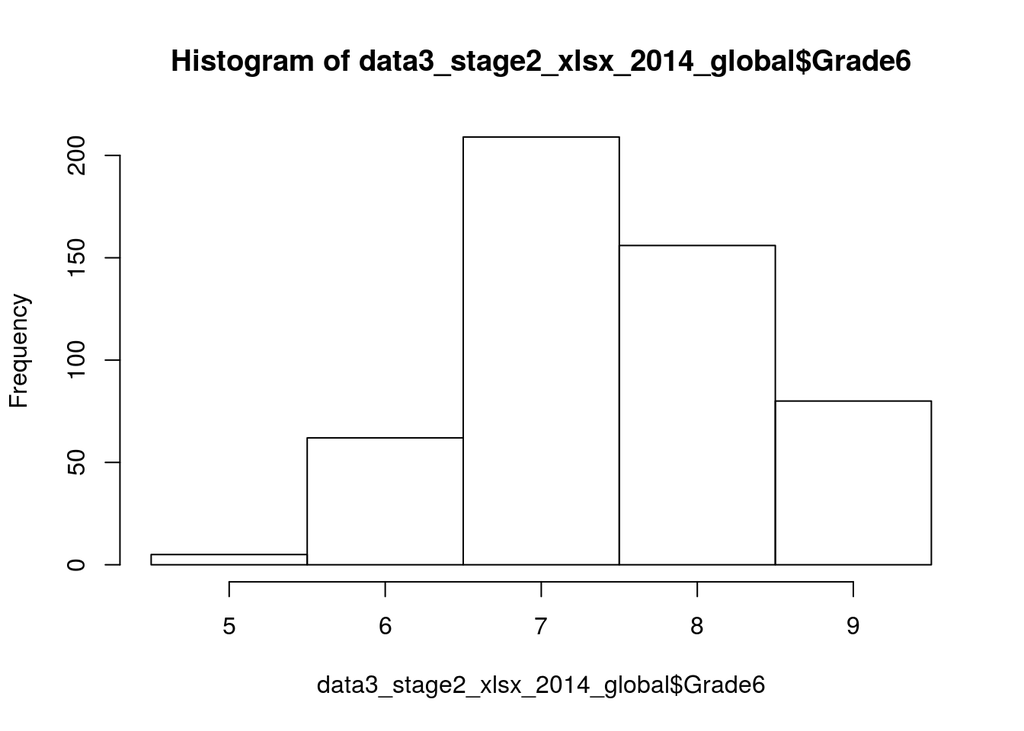

```r
  hist(data3_stage2_xlsx_2014_global$Grade6,breaks = seq(4.5,9.5,by = 1))
```

As a consistency check let us see if the the candidates are ordered correctly

```r
  unique(data3_stage2_xlsx_2014_global$Grade6-sort(data3_stage2_xlsx_2014_global$Grade6,decreasing=TRUE))
```

```
## [1] 0
```

** Exact Sciences **

```r
  data3_stage2_xlsx_2014_sci <-load_panel2014("6",file3_stage2_rel_path_2014,"sci",2,6,105,6)
  str(data3_stage2_xlsx_2014_sci)
```

```
## 'data.frame':    99 obs. of  8 variables:
##  $ Ref       : Factor w/ 99 levels "IF/00009/2014",..: 94 51 18 35 89 2 8 73 74 44 ...
##  $ Name      : Factor w/ 99 levels "Alexandra Martins da Silva",..: 16 50 78 39 41 85 7 57 66 20 ...
##  $ Host      : Factor w/ 45 levels "Associação do Instituto Superior Técnico para a Investigação e o Desenvolvimento (IST-ID)",..: 3 38 9 21 3 3 35 41 42 8 ...
##  $ WGrade6   : num  9 9 9 8.9 8.9 8.9 8.6 8.6 8.6 8.5 ...
##  $ Grade6    : num  9 9 9 9 9 9 9 9 9 9 ...
##  $ Status6   : Factor w/ 3 levels "Reserve","No",..: 3 3 3 3 3 3 3 3 3 3 ...
##  $ Panel     : chr  "sci" "sci" "sci" "sci" ...
##  $ PanelRank6: int  1 2 3 4 5 6 7 8 9 10 ...
```

```r
  head(data3_stage2_xlsx_2014_sci)
```

```
##             Ref                              Name
## 1 IF/01710/2014       Carlos Manuel Correia Silva
## 2 IF/00820/2014               Lorenzo Cazon Boado
## 3 IF/00347/2014      Pedro José Gonçalves Ribeiro
## 4 IF/00578/2014            Irina de Sousa Moreira
## 5 IF/01654/2014                  Jarle Brinchmann
## 6 IF/00028/2014 Sergio Antonio Goncalves de Sousa
##                                                                      Host
## 1                                         Centro de Astrofísica (CAUP/UP)
## 2 Laboratório de Instrumentação e Física Experimental de Partículas (LIP)
## 3           Centro de Física e Engenharia de Materiais Avançados (CeFEMA)
## 4                    Centro de Neurociências e Biologia Celular (CNBC/UC)
## 5                                         Centro de Astrofísica (CAUP/UP)
## 6                                         Centro de Astrofísica (CAUP/UP)
##   WGrade6 Grade6 Status6 Panel PanelRank6
## 1     9.0      9     Yes   sci          1
## 2     9.0      9     Yes   sci          2
## 3     9.0      9     Yes   sci          3
## 4     8.9      9     Yes   sci          4
## 5     8.9      9     Yes   sci          5
## 6     8.9      9     Yes   sci          6
```

```r
  tail(data3_stage2_xlsx_2014_sci)
```

```
##              Ref                                     Name
## 94 IF/01443/2014                Marta C. Parracho C.Corvo
## 95 IF/01691/2014            Sílvia Cristina Cláudio Nunes
## 96 IF/00098/2014            Pedro Miguel da Silva Martins
## 97 IF/00806/2014                       Dmytro S. Nesterov
## 98 IF/00568/2014 Paula Cristina Ferreira da Silva Brandao
## 99 IF/00491/2014                     Sónia Duarte Barroso
##                                                                                               Host
## 94 REQUIMTE (Rede de Química e Tecnologia) - Laboratório Associado para a Química Verde (REQUIMTE)
## 95                                                            Universidade da Beira Interior (UBI)
## 96                                        Instituto de Ciências Biomédicas Abel Salazar (ICBAS/UP)
## 97                                                      Centro de Química Estrutural (CQE/IST/UTL)
## 98                          Centro de Investigação em Materiais Cerâmicos e Compósitos (CICECO/UA)
## 99                                                      Centro de Química Estrutural (CQE/IST/UTL)
##    WGrade6 Grade6 Status6 Panel PanelRank6
## 94     6.5      7 Reserve   sci         94
## 95     6.5      7 Reserve   sci         95
## 96     6.2      6      No   sci         96
## 97     6.1      6      No   sci         97
## 98     5.7      6      No   sci         98
## 99     5.6      6      No   sci         99
```

```r
  levels(data3_stage2_xlsx_2014_sci$Status6)
```

```
## [1] "Reserve" "No"      "Yes"
```

** Engineering and Technology **

```r
  data3_stage2_xlsx_2014_eng <-load_panel2014("6",file3_stage2_rel_path_2014,"eng",3,6,95,6)
  str(data3_stage2_xlsx_2014_eng)
```

```
## 'data.frame':    89 obs. of  8 variables:
##  $ Ref       : Factor w/ 89 levels "IF/00036/2014",..: 25 87 20 77 85 7 2 88 38 18 ...
##  $ Name      : Factor w/ 89 levels "Albino Manuel Pereira Martins",..: 12 44 19 43 45 5 8 55 2 6 ...
##  $ Host      : Factor w/ 37 levels "Centro de Biologia Molecular e Ambiental (CBMA)",..: 14 26 32 34 10 26 17 35 14 9 ...
##  $ WGrade6   : num  9 9 8.9 8.6 8.5 8.1 8.1 8.1 8 8 ...
##  $ Grade6    : num  9 9 9 9 9 8 8 8 8 8 ...
##  $ Status6   : Factor w/ 3 levels "Reserve","No",..: 3 3 3 3 3 3 3 3 3 3 ...
##  $ Panel     : chr  "eng" "eng" "eng" "eng" ...
##  $ PanelRank6: int  1 2 3 4 5 6 7 8 9 10 ...
```

```r
  head(data3_stage2_xlsx_2014_eng)
```

```
##             Ref                                Name
## 1 IF/00680/2014                Ana Rita Cruz Duarte
## 2 IF/01741/2014     Ligia Maria de Oliveira Martins
## 3 IF/00514/2014 Cláudia Sofia Castro Gomes da Silva
## 4 IF/01595/2014                          Lifeng Liu
## 5 IF/01712/2014              Lino da Silva Ferreira
## 6 IF/00190/2014           Ana Belén Pereiro Estévez
##                                                           Host WGrade6
## 1                ICVS/3B`s - Laboratório Associado (ICVS/3B`s)     9.0
## 2       Instituto de Tecnologia Química e Biológica (ITQB/UNL)     9.0
## 3 Laboratório de Processos de Separação e Reacção (LSRE/FE/UP)     8.9
## 4   Laboratório Ibérico Internacional de Nanotecnologias (INL)     8.6
## 5         Centro de Neurociências e Biologia Celular (CNBC/UC)     8.5
## 6       Instituto de Tecnologia Química e Biológica (ITQB/UNL)     8.1
##   Grade6 Status6 Panel PanelRank6
## 1      9     Yes   eng          1
## 2      9     Yes   eng          2
## 3      9     Yes   eng          3
## 4      9     Yes   eng          4
## 5      9     Yes   eng          5
## 6      8     Yes   eng          6
```

```r
  tail(data3_stage2_xlsx_2014_eng)
```

```
##              Ref                                   Name
## 84 IF/00061/2014    João Manuel do Paço Quesado Delgado
## 85 IF/00158/2014                   Mariana Emilia Ghica
## 86 IF/01042/2014            Pedro António Palma Madeira
## 87 IF/00910/2014                  Joao Oliveira Ventura
## 88 IF/01502/2014 Pedro Alexandre Lopes de Sousa Martins
## 89 IF/01614/2014                Rui Pedro da Costa Neto
##                                                                   Host
## 84            Faculdade de Engenharia da Universidade do Porto (FE/UP)
## 85                                         Instituto Pedro Nunes (IPN)
## 86        Laboratório de Processos de Separação e Reacção (LSRE/FE/UP)
## 87                                        Instituto de Nanotecnologias
## 88     Instituto de Engenharia Mecânica e Gestão Industrial (INEGI/UP)
## 89 Laboratório Associado de Energia, Transportes e Aeronáutica (LAETA)
##    WGrade6 Grade6 Status6 Panel PanelRank6
## 84     7.0      6      No   eng         84
## 85     6.5      6      No   eng         85
## 86     6.5      6      No   eng         86
## 87     6.0      6      No   eng         87
## 88     6.0      6      No   eng         88
## 89     6.0      6      No   eng         89
```

** Medical Health Sciences **

```r
  data3_stage2_xlsx_2014_med <-load_panel2014("6",file3_stage2_rel_path_2014,"med",4,6,70,6)
  str(data3_stage2_xlsx_2014_med)
```

```
## 'data.frame':    64 obs. of  8 variables:
##  $ Ref       : Factor w/ 64 levels "IF/00004/2014",..: 10 26 64 34 36 57 2 1 5 53 ...
##  $ Name      : Factor w/ 64 levels "Agostinho Albérico Rodrigues de Carvalho",..: 12 42 64 1 19 21 31 32 52 54 ...
##  $ Host      : Factor w/ 22 levels "Centro de Engenharia Biológica da Universidade do Minho (CEB/UM)",..: 11 11 11 7 11 7 11 11 7 19 ...
##  $ WGrade6   : num  8.9 8.6 8.6 8.5 8.5 8.5 8.5 8.5 8.5 8.3 ...
##  $ Grade6    : num  9 9 9 8 9 8 9 8 8 8 ...
##  $ Status6   : Factor w/ 3 levels "Reserve","No",..: 3 3 3 3 3 3 3 3 3 3 ...
##  $ Panel     : chr  "med" "med" "med" "med" ...
##  $ PanelRank6: int  1 2 3 4 5 6 7 8 9 10 ...
```

```r
  head(data3_stage2_xlsx_2014_med)
```

```
##             Ref                                         Name
## 1 IF/00166/2014              Bruno Miguel Bernardes de Jesus
## 2 IF/00595/2014                     Nuno Luís Barbosa Morais
## 3 IF/01693/2014 Vanessa Alexandra dos Santos Morais Epifanio
## 4 IF/00735/2014     Agostinho Albérico Rodrigues de Carvalho
## 5 IF/00787/2014                      Diana Maria Pinto Prata
## 6 IF/01390/2014                  Egidio Manuel Pires Torrado
##                                            Host WGrade6 Grade6 Status6
## 1   Instituto de Medicina Molecular (IMM/FM/UL)     8.9      9     Yes
## 2   Instituto de Medicina Molecular (IMM/FM/UL)     8.6      9     Yes
## 3   Instituto de Medicina Molecular (IMM/FM/UL)     8.6      9     Yes
## 4 ICVS/3B`s - Laboratório Associado (ICVS/3B`s)     8.5      8     Yes
## 5   Instituto de Medicina Molecular (IMM/FM/UL)     8.5      9     Yes
## 6 ICVS/3B`s - Laboratório Associado (ICVS/3B`s)     8.5      8     Yes
##   Panel PanelRank6
## 1   med          1
## 2   med          2
## 3   med          3
## 4   med          4
## 5   med          5
## 6   med          6
```

```r
  tail(data3_stage2_xlsx_2014_med)
```

```
##              Ref                                   Name
## 59 IF/00939/2014                Jorge Valero Gómez-Lobo
## 60 IF/01397/2014       Luis Miguel Andrade de Magalhães
## 61 IF/00379/2014                 Maria João Jorge Pinho
## 62 IF/00317/2014           SÓNIA CARINA MORAIS DA SILVA
## 63 IF/00719/2014                 Salomé Soares de Pinho
## 64 IF/00391/2014 Maria Teresa Martins da Cunha Oliveira
##                                                                                               Host
## 59                                            Centro de Neurociências e Biologia Celular (CNBC/UC)
## 60 REQUIMTE (Rede de Química e Tecnologia) - Laboratório Associado para a Química Verde (REQUIMTE)
## 61                               Instituto Biomédico de Investigação de Luz e Imagem (IBILI/FM/UC)
## 62                                Centro de Engenharia Biológica da Universidade do Minho (CEB/UM)
## 63                                     Instituto de Patologia e Imunologia Molecular (IPATIMUP/UP)
## 64                                            Centro de Neurociências e Biologia Celular (CNBC/UC)
##    WGrade6 Grade6 Status6 Panel PanelRank6
## 59     6.6      7 Reserve   med         59
## 60     6.6      6      No   med         60
## 61     6.6      7 Reserve   med         61
## 62     6.6      7 Reserve   med         62
## 63     6.5      6      No   med         63
## 64     6.2      7 Reserve   med         64
```

** Environmental Agricultural Sciences **

```r
  data3_stage2_xlsx_2014_env <-load_panel2014("6",file3_stage2_rel_path_2014,"env",5,6,74,6)
  str(data3_stage2_xlsx_2014_env)
```

```
## 'data.frame':    68 obs. of  8 variables:
##  $ Ref       : Factor w/ 68 levels "IF/00010/2014",..: 38 20 13 30 56 45 49 17 15 57 ...
##  $ Name      : Factor w/ 68 levels "Ana Alexandra Figueiredo Matias",..: 24 43 14 15 37 44 53 20 32 58 ...
##  $ Host      : Factor w/ 31 levels "Centro de Biotecnologia e Química Fina (CBQF/ESB/UCP)",..: 22 1 17 12 22 2 30 30 17 22 ...
##  $ WGrade6   : num  9 9 8.9 8.9 8.9 8.9 8.9 8.8 8.8 8.8 ...
##  $ Grade6    : num  9 9 9 9 9 9 9 9 9 9 ...
##  $ Status6   : Factor w/ 3 levels "Reserve","No",..: 3 3 3 3 3 3 3 3 3 3 ...
##  $ Panel     : chr  "env" "env" "env" "env" ...
##  $ PanelRank6: int  1 2 3 4 5 6 7 8 9 10 ...
```

```r
  head(data3_stage2_xlsx_2014_env)
```

```
##             Ref                                      Name
## 1 IF/00764/2014          Isabel Alexandra Aguiar de Abreu
## 2 IF/00506/2014 Marta Wilton Pereira Leite de Vasconcelos
## 3 IF/00311/2014                          Eric claude Font
## 4 IF/00661/2014                               Erwan GAREL
## 5 IF/01337/2014    Maria Carlota Morais e Cunha Vaz Patto
## 6 IF/00998/2014              Mercedes Gonzalez Wanguemert
##                                                          Host WGrade6
## 1      Instituto de Tecnologia Química e Biológica (ITQB/UNL)     9.0
## 2       Centro de Biotecnologia e Química Fina (CBQF/ESB/UCP)     9.0
## 3     Faculdade de Ciências da Universidade de Lisboa (FC/UL)     8.9
## 4 Centro de Investigação Marinha e Ambiental (CIMA/FCMA/UAlg)     8.9
## 5      Instituto de Tecnologia Química e Biológica (ITQB/UNL)     8.9
## 6                     Centro de Ciências do Mar (CCMar/CIMAR)     8.9
##   Grade6 Status6 Panel PanelRank6
## 1      9     Yes   env          1
## 2      9     Yes   env          2
## 3      9     Yes   env          3
## 4      9     Yes   env          4
## 5      9     Yes   env          5
## 6      9     Yes   env          6
```

```r
  tail(data3_stage2_xlsx_2014_env)
```

```
##              Ref                              Name
## 63 IF/00218/2014 Patricia María Rodríguez González
## 64 IF/00667/2014    Ana Catarina Ferreira da Silva
## 65 IF/00947/2014                 Marta Mega Rufino
## 66 IF/00010/2014           Pedro Manuel Broa Costa
## 67 IF/00911/2014         Pedro Miguel Matos Soares
## 68 IF/00236/2014   Patricia Sofia Matos dos Santos
##                                                       Host WGrade6 Grade6
## 63               Instituto Superior de Agronomia (ISA/UTL)     6.2      6
## 64                   Centro de Geo-Sistemas (CVRM/IST/UTL)     6.1      6
## 65 Instituto Português do Mar e da Atmosfera, I. P. (IPMA)     6.1      6
## 66                IMAR - Centro do Mar e Ambiente (CMA/UC)     6.1      6
## 67 Faculdade de Ciências da Universidade de Lisboa (FC/UL)     6.1      6
## 68       Centro de Estudos do Ambiente e do Mar (CESAM/UA)     6.0      6
##    Status6 Panel PanelRank6
## 63      No   env         63
## 64      No   env         64
## 65      No   env         65
## 66      No   env         66
## 67      No   env         67
## 68      No   env         68
```

** Natural Animal Sciences **

```r
  data3_stage2_xlsx_2014_nat <-load_panel2014("6",file3_stage2_rel_path_2014,"nat",6,6,92,6)
  str(data3_stage2_xlsx_2014_nat)
```

```
## 'data.frame':    86 obs. of  8 variables:
##  $ Ref       : Factor w/ 86 levels "IF/00003/2014",..: 42 9 82 21 19 68 13 78 55 7 ...
##  $ Name      : Factor w/ 86 levels "Afonso Miguel dos Santos Duarte",..: 14 8 23 35 46 47 60 63 71 85 ...
##  $ Host      : Factor w/ 32 levels "Centro de Biologia Ambiental (CBA/FC/UL)",..: 28 27 28 24 30 13 27 11 5 16 ...
##  $ WGrade6   : num  9 8.6 8.6 8.6 8.6 8.6 8.6 8.6 8.6 8.6 ...
##  $ Grade6    : num  9 9 9 9 9 9 9 9 9 9 ...
##  $ Status6   : Factor w/ 2 levels "Reserve","Yes": 2 2 2 2 2 2 2 2 2 2 ...
##  $ Panel     : chr  "nat" "nat" "nat" "nat" ...
##  $ PanelRank6: int  1 2 3 4 5 6 7 8 9 10 ...
```

```r
  head(data3_stage2_xlsx_2014_nat)
```

```
##             Ref                                        Name
## 1 IF/00866/2014                        Catarina Jorge Ginja
## 2 IF/00209/2014                           Angelica Crottini
## 3 IF/01627/2014         David James Alexander Edward Harris
## 4 IF/00532/2014                 Isabel Antunes Mendes Gordo
## 5 IF/00437/2014                    Liana Casquinha da Silva
## 6 IF/01284/2014 Luisa Mafalda Gigante Rodrigues Carvalheiro
##                                                                                 Host
## 1 Rede de Investigação em Biodiversidade e Biologia Evolutiva (InBIO/ICETA-Porto/UP)
## 2                        Rede de Investigação em Biodiversidade e Biologia Evolutiva
## 3 Rede de Investigação em Biodiversidade e Biologia Evolutiva (InBIO/ICETA-Porto/UP)
## 4                                          Instituto Gulbenkian de Ciência (IGC/FCG)
## 5             Research Institute for Medicines and Pharmaceutical Sciences (iMed.UL)
## 6                            Faculdade de Ciências da Universidade de Lisboa (FC/UL)
##   WGrade6 Grade6 Status6 Panel PanelRank6
## 1     9.0      9     Yes   nat          1
## 2     8.6      9     Yes   nat          2
## 3     8.6      9     Yes   nat          3
## 4     8.6      9     Yes   nat          4
## 5     8.6      9     Yes   nat          5
## 6     8.6      9     Yes   nat          6
```

```r
  tail(data3_stage2_xlsx_2014_nat)
```

```
##              Ref                                            Name
## 81 IF/01756/2014                          João José Inácio Silva
## 82 IF/00976/2014        Maria João de Medeiros Brazão Lopes Feio
## 83 IF/00600/2014                  Nelson Eduardo do Vale Martins
## 84 IF/00352/2014                      Vitor Hugo Rodrigues Paiva
## 85 IF/00570/2014 Rita Isabel de Oliveira Soares Branco Domingues
## 86 IF/01197/2014       Herlânder Anselmo Queirós Pereira Azevedo
##                                                                                  Host
## 81                                Instituto de Higiene e Medicina Tropical (IHMT/UNL)
## 82                                           IMAR - Centro do Mar e Ambiente (CMA/UC)
## 83                                          Instituto Gulbenkian de Ciência (IGC/FCG)
## 84                                           IMAR - Centro do Mar e Ambiente (CMA/UC)
## 85                        Centro de Investigação Marinha e Ambiental (CIMA/FCMA/UAlg)
## 86 Rede de Investigação em Biodiversidade e Biologia Evolutiva (InBIO/ICETA-Porto/UP)
##    WGrade6 Grade6 Status6 Panel PanelRank6
## 81     6.5      7 Reserve   nat         81
## 82     6.5      7 Reserve   nat         82
## 83     6.5      7 Reserve   nat         83
## 84     6.5      7 Reserve   nat         84
## 85     6.0      7 Reserve   nat         85
## 86     5.7      7 Reserve   nat         86
```

** Social Sciences ** NOTE: In this panel I have removed the last candidate that quit the competition.

```r
  data3_stage2_xlsx_2014_soc <-load_panel2014("6",file3_stage2_rel_path_2014,"soc",7,6,65,6)
  str(data3_stage2_xlsx_2014_soc)
```

```
## 'data.frame':    59 obs. of  8 variables:
##  $ Ref       : Factor w/ 59 levels "IF/00054/2014",..: 49 57 37 38 41 21 43 6 11 27 ...
##  $ Name      : Factor w/ 59 levels "Amilcar Manuel Reis Moreira",..: 10 7 8 22 25 39 5 28 50 2 ...
##  $ Host      : Factor w/ 27 levels "Centro de Economia e Finanças (CEFUP)",..: 10 16 18 18 15 20 15 18 23 22 ...
##  $ WGrade6   : num  9 8.6 8.6 8.6 8.6 8.6 8 8 8 7.6 ...
##  $ Grade6    : num  9 9 8 8 9 9 8 8 8 7 ...
##  $ Status6   : Factor w/ 3 levels "Reserve","No",..: 3 3 3 3 3 3 3 3 3 3 ...
##  $ Panel     : chr  "soc" "soc" "soc" "soc" ...
##  $ PanelRank6: int  1 2 3 4 5 6 7 8 9 10 ...
```

```r
  head(data3_stage2_xlsx_2014_soc)
```

```
##             Ref                       Name
## 1 IF/01405/2014            Ben Mark Harvey
## 2 IF/01612/2014   André Otelo Paraíba Mata
## 3 IF/01063/2014                Anna Fedele
## 4 IF/01128/2014 Dr Kimberley Jane Hockings
## 5 IF/01219/2014   Eva Martins da Conceição
## 6 IF/00513/2014             Manuel adelino
##                                                                                           Host
## 1 Centro de Investigação do Núcleo de Estudos e Intervenção Cognitivo-Comportamental (CINEICC)
## 2                               CENTRO DE INVESTIGAÇÂO EM PSICOLOGIA DA UNIVERSIDADE DE LISBOA
## 3                                        Centro em Rede de Investigação em Antropologia (CRIA)
## 4                                        Centro em Rede de Investigação em Antropologia (CRIA)
## 5                                              Centro de Investigação em Psicologia (CIPsi/UM)
## 6                                Faculdade de Economia da Universidade Nova de Lisboa (FE/UNL)
##   WGrade6 Grade6 Status6 Panel PanelRank6
## 1     9.0      9     Yes   soc          1
## 2     8.6      9     Yes   soc          2
## 3     8.6      8     Yes   soc          3
## 4     8.6      8     Yes   soc          4
## 5     8.6      9     Yes   soc          5
## 6     8.6      9     Yes   soc          6
```

```r
  tail(data3_stage2_xlsx_2014_soc)
```

```
##              Ref                                     Name
## 54 IF/00927/2014  Carmen Maria de Freitas Diego Gonçalves
## 55 IF/00396/2014        Patrícia Susana Pinho Castanheira
## 56 IF/01572/2014                          RICCARDO MARCHI
## 57 IF/00122/2014        Sandra Raquel Gonçalves Fernandes
## 58 IF/00585/2014 Miguel Farinha dos Santos da Silva Graça
## 59 IF/00252/2014                  Filomena Carvalho Sousa
##                                                                                                     Host
## 54                                                             Centro de Estudos Geográficos (CEG/FL/UL)
## 55                Centro de Investigação em Didáctica e Tecnologia na Formação de Formadores (CIDTFF/UA)
## 56                                                                Instituto de Ciências Sociais (ICS/UL)
## 57                                             Centro de Investigação em Estudos da Criança (CIEC/UM/UM)
## 58                                              Centro de Investigação em Engenharia Civil (CIEC/FCT/UC)
## 59 IELT - Instituto de Estudos de Literatura Tradicional - Patrimónios, Artes e Culturas (IELT/FCSH/UNL)
##    WGrade6 Grade6 Status6 Panel PanelRank6
## 54     6.0      6      No   soc         54
## 55     6.0      6      No   soc         55
## 56     6.0      6      No   soc         56
## 57     6.0      6      No   soc         57
## 58     5.7      6      No   soc         58
## 59     5.1      5      No   soc         59
```

** Humanities ** NOTE: Some candidate was eliminated after appeal.

```r
  data3_stage2_xlsx_2014_hum <-load_panel2014("6",file3_stage2_rel_path_2014,"hum",8,6,53,6)
  str(data3_stage2_xlsx_2014_hum)
```

```
## 'data.frame':    47 obs. of  8 variables:
##  $ Ref       : Factor w/ 47 levels "IF/00068/2014",..: 43 22 25 47 16 18 19 34 3 12 ...
##  $ Name      : Factor w/ 47 levels "Adelino Dias Cardoso",..: 9 14 25 7 16 5 37 12 22 2 ...
##  $ Host      : Factor w/ 25 levels "Centro de Estudos Arqueológicos das Universidades de Coimbra e Porto (CEA)",..: 2 13 21 9 21 25 12 18 24 16 ...
##  $ WGrade6   : num  9 9 9 8.9 8.6 8.5 8.5 8.4 8.2 8.1 ...
##  $ Grade6    : num  9 9 9 9 8 8 8 8 8 8 ...
##  $ Status6   : Factor w/ 3 levels "Reserve","No",..: 3 3 3 3 3 3 3 3 3 3 ...
##  $ Panel     : chr  "hum" "hum" "hum" "hum" ...
##  $ PanelRank6: int  1 2 3 4 5 6 7 8 9 10 ...
```

```r
  head(data3_stage2_xlsx_2014_hum)
```

```
##             Ref                                           Name
## 1 IF/01533/2014                            Eftychia Bathrellou
## 2 IF/00835/2014                   FRANCISCO J MARTINEZ-ANTONIO
## 3 IF/00966/2014 Luís Manuel Duarte Antunes Figueiredo Trindade
## 4 IF/01736/2014                                    David Yates
## 5 IF/00631/2014       Helena Sofia Rodrigues Ferreira da Silva
## 6 IF/00709/2014                              Boban Arsenijevic
##                                                                      Host
## 1                                 Centro de Estudos Clássicos (CEC/FL/UL)
## 2 Centro Interdisciplinar de História, Culturas e Sociedades (CIDEHUS/UE)
## 3                      Instituto de História Contemporânea (IHC/FCSH/UNL)
## 4                                             Centro de Filosofia (CF/UL)
## 5                      Instituto de História Contemporânea (IHC/FCSH/UNL)
## 6                                              Universidade do Minho (UM)
##   WGrade6 Grade6 Status6 Panel PanelRank6
## 1     9.0      9     Yes   hum          1
## 2     9.0      9     Yes   hum          2
## 3     9.0      9     Yes   hum          3
## 4     8.9      9     Yes   hum          4
## 5     8.6      8     Yes   hum          5
## 6     8.5      8     Yes   hum          6
```

```r
  tail(data3_stage2_xlsx_2014_hum)
```

```
##              Ref                                                     Name
## 42 IF/01449/2014                                           Samuel GESSNER
## 43 IF/01059/2014                                    Saúl Martínez Bermejo
## 44 IF/01150/2014                              Teresa Salomé Alves da Mota
## 45 IF/01234/2014                  Catarina Pombo Martins de Castro Nabais
## 46 IF/00504/2014                                         Giuseppina Raggi
## 47 IF/01701/2014 Patricia Catarina Rosa Silveirinha Pinto Castello Branco
##                                                                       Host
## 42                 Faculdade de Ciências da Universidade de Lisboa (FC/UL)
## 43                          Centro de História de Além-Mar (CHAM/FCSH/UNL)
## 44                 Faculdade de Ciências da Universidade de Lisboa (FC/UL)
## 45 Fundação da Faculdade de Ciências da Universidade de Lisboa (FFC/FC/UL)
## 46                          Centro de História de Além-Mar (CHAM/FCSH/UNL)
## 47                      Instituto de Filosofia da Linguagem (IFL/FCSH/UNL)
##    WGrade6 Grade6 Status6 Panel PanelRank6
## 42     5.6      6      No   hum         42
## 43     5.6      6      No   hum         43
## 44     5.6      6      No   hum         44
## 45     5.5      5      No   hum         45
## 46     5.5      6      No   hum         46
## 47     5.5      5      No   hum         47
```

### 2.2.3 FINAL DATA FRAME OUTPUT

Now we are going to merge all the data from the various data frames. We want a data frame with the following columns:

- Ref
- Name
- Host
- Panel
- Grade1
- Rank1
- Status1
- Grade2
- Rank2
- Status2
- Grade3
- Rank3
- Status3
- Grade4
- WGrade4
- Rank4
- PanelRank4
- Status4
- Grade5
- WGrade5
- Rank5
- PanelRank5
- Status5
- Grade6
- WGrade6
- Rank6
- PanelRank6
- Status6

Let us first list the global data_frames and their dimensions

```r
  dim(data1_stage1_xlsx_2014)
```

```
## [1] 1398    5
```

```r
  dim(data2_stage1_xlsx_2014)
```

```
## [1] 1398    5
```

```r
  dim(data3_stage1_xlsx_2014)
```

```
## [1] 514   4
```

```r
  dim(data1_stage2_xlsx_2014_global)
```

```
## [1] 512   4
```

```r
  dim(data2_stage2_xlsx_2014_global)
```

```
## [1] 512   4
```

```r
  dim(data3_stage2_xlsx_2014_global)
```

```
## [1] 512   4
```

Now it is easier to start by creating a data frame only with the candidate details ordered by IF reference.

```r
  data_2014 <- data1_stage1_xlsx_2014[order(data1_stage1_xlsx_2014$Ref),1:3]
  head(data_2014)
```

```
##               Ref                                   Name
## 232 IF/00003/2014 Luís Miguel Nunes Valente Afonso Reino
## 74  IF/00004/2014                           Karine Serre
## 698 IF/00006/2014                Manuel Algarra Gonzalez
## 511 IF/00007/2014                      Adria Gil Mestres
## 512 IF/00008/2014                    André Gama Oliveira
## 233 IF/00009/2014              Luís Miguel Teodoro Frija
##                                                                                   Host
## 232 Rede de Investigação em Biodiversidade e Biologia Evolutiva (InBIO/ICETA-Porto/UP)
## 74                                         Instituto de Medicina Molecular (IMM/FM/UL)
## 698                                    Centro de Investigação em Química (CIQ/FCUP/UP)
## 511                            Faculdade de Ciências da Universidade de Lisboa (FC/UL)
## 512                                           Centro de Matemática (CM/ADFCUP/FCUP/UP)
## 233                                         Centro de Química Estrutural (CQE/IST/UTL)
```

```r
  tail(data_2014)
```

```
##                Ref                              Name
## 906  IF/01771/2014              Ana Serrano Tellería
## 465  IF/01772/2014         Valter Bruno Reis e Silva
## 697  IF/01773/2014    Cristóvão Fernando Macedo Lima
## 1381 IF/01774/2014 Manuel Jacinto de Ascensão Jardim
## 1106 IF/01778/2014            ALICIA MIGUÉLEZ CAVERO
## 1367 IF/01780/2014 António Carlos Almeida Figueiredo
##                                                                                   Host
## 906                                               Universidade da Beira Interior (UBI)
## 465                    Instituto de Engenharia Mecânica e Gestão Industrial (INEGI/UP)
## 697  Centro de Investigação e de Tecnologias Agro-Ambientais e Biológicas (CITAB/UTAD)
## 1381              Centro de Literaturas e Culturas Lusófonas e Europeia (CLEPUL/FL/UL)
## 1106                                     Instituto de Estudos Medievais (IEM/FCSH/UNL)
## 1367                                Instituto de Plasma e Fusão Nuclear (IPFN/IST/UTL)
```

Next, we create all all the columns we want to exist.

```r
  nrecords <- dim(data_2014)[1]
  data_2014$Panel <- rep("empty",nrecords)

  data_2014$Grade1 <- rep(NA,nrecords)
  data_2014$Rank1 <- rep(NA,nrecords)
  data_2014$Status1 <- rep("empty",nrecords)

  data_2014$Grade2 <- rep(NA,nrecords)
  data_2014$Rank2 <- rep(NA,nrecords)
  data_2014$Status2 <- rep("empty",nrecords)

  data_2014$Grade3 <- rep(NA,nrecords)
  data_2014$Rank3 <- rep(NA,nrecords)
  data_2014$Status3 <- rep("empty",nrecords)

  data_2014$Grade4 <- rep(NA,nrecords)
  data_2014$WGrade4 <- rep(NA,nrecords)
  data_2014$Rank4 <- rep(NA,nrecords)
  data_2014$PanelRank4 <- rep(NA,nrecords)
  data_2014$Status4 <- rep("empty",nrecords)

  data_2014$Grade5 <- rep(NA,nrecords)
  data_2014$WGrade5 <- rep(NA,nrecords)
  data_2014$Rank5 <- rep(NA,nrecords)
  data_2014$PanelRank5 <- rep(NA,nrecords)
  data_2014$Status5 <- rep("empty",nrecords)

  data_2014$Grade6 <- rep(NA,nrecords)
  data_2014$WGrade6 <- rep(NA,nrecords)
  data_2014$Rank6 <- rep(NA,nrecords)
  data_2014$PanelRank6 <- rep(NA,nrecords)
  data_2014$Status6 <- rep("empty",nrecords)

  head(data_2014)
```

```
##               Ref                                   Name
## 232 IF/00003/2014 Luís Miguel Nunes Valente Afonso Reino
## 74  IF/00004/2014                           Karine Serre
## 698 IF/00006/2014                Manuel Algarra Gonzalez
## 511 IF/00007/2014                      Adria Gil Mestres
## 512 IF/00008/2014                    André Gama Oliveira
## 233 IF/00009/2014              Luís Miguel Teodoro Frija
##                                                                                   Host
## 232 Rede de Investigação em Biodiversidade e Biologia Evolutiva (InBIO/ICETA-Porto/UP)
## 74                                         Instituto de Medicina Molecular (IMM/FM/UL)
## 698                                    Centro de Investigação em Química (CIQ/FCUP/UP)
## 511                            Faculdade de Ciências da Universidade de Lisboa (FC/UL)
## 512                                           Centro de Matemática (CM/ADFCUP/FCUP/UP)
## 233                                         Centro de Química Estrutural (CQE/IST/UTL)
##     Panel Grade1 Rank1 Status1 Grade2 Rank2 Status2 Grade3 Rank3 Status3
```

[output cut: 20 more lines]

```r
  tail(data_2014)
```

```
##                Ref                              Name
## 906  IF/01771/2014              Ana Serrano Tellería
## 465  IF/01772/2014         Valter Bruno Reis e Silva
## 697  IF/01773/2014    Cristóvão Fernando Macedo Lima
## 1381 IF/01774/2014 Manuel Jacinto de Ascensão Jardim
## 1106 IF/01778/2014            ALICIA MIGUÉLEZ CAVERO
## 1367 IF/01780/2014 António Carlos Almeida Figueiredo
##                                                                                   Host
## 906                                               Universidade da Beira Interior (UBI)
## 465                    Instituto de Engenharia Mecânica e Gestão Industrial (INEGI/UP)
## 697  Centro de Investigação e de Tecnologias Agro-Ambientais e Biológicas (CITAB/UTAD)
## 1381              Centro de Literaturas e Culturas Lusófonas e Europeia (CLEPUL/FL/UL)
## 1106                                     Instituto de Estudos Medievais (IEM/FCSH/UNL)
## 1367                                Instituto de Plasma e Fusão Nuclear (IPFN/IST/UTL)
##      Panel Grade1 Rank1 Status1 Grade2 Rank2 Status2 Grade3 Rank3 Status3
```

[output cut: 20 more lines]

Next we populate each column by retrieving the information from each data frame. The first data_frame is the easiest

```r
  data_2014$Grade1 <- data1_stage1_xlsx_2014[order(data1_stage1_xlsx_2014$Ref),"Grade1"]
  data_2014$Status1 <- data1_stage1_xlsx_2014[order(data1_stage1_xlsx_2014$Ref),"Status1"]
  data1_stage1_xlsx_2014$Rank1 <- 1:nrecords
  data_2014$Rank1 <- data1_stage1_xlsx_2014[order(data1_stage1_xlsx_2014$Ref),"Rank1"]
  head(data_2014)
```

```
##               Ref                                   Name
## 232 IF/00003/2014 Luís Miguel Nunes Valente Afonso Reino
## 74  IF/00004/2014                           Karine Serre
## 698 IF/00006/2014                Manuel Algarra Gonzalez
## 511 IF/00007/2014                      Adria Gil Mestres
## 512 IF/00008/2014                    André Gama Oliveira
## 233 IF/00009/2014              Luís Miguel Teodoro Frija
##                                                                                   Host
## 232 Rede de Investigação em Biodiversidade e Biologia Evolutiva (InBIO/ICETA-Porto/UP)
## 74                                         Instituto de Medicina Molecular (IMM/FM/UL)
## 698                                    Centro de Investigação em Química (CIQ/FCUP/UP)
## 511                            Faculdade de Ciências da Universidade de Lisboa (FC/UL)
## 512                                           Centro de Matemática (CM/ADFCUP/FCUP/UP)
## 233                                         Centro de Química Estrutural (CQE/IST/UTL)
##     Panel Grade1 Rank1 Status1 Grade2 Rank2 Status2 Grade3 Rank3 Status3
```

[output cut: 20 more lines]

```r
  tail(data_2014)
```

```
##                Ref                              Name
## 906  IF/01771/2014              Ana Serrano Tellería
## 465  IF/01772/2014         Valter Bruno Reis e Silva
## 697  IF/01773/2014    Cristóvão Fernando Macedo Lima
## 1381 IF/01774/2014 Manuel Jacinto de Ascensão Jardim
## 1106 IF/01778/2014            ALICIA MIGUÉLEZ CAVERO
## 1367 IF/01780/2014 António Carlos Almeida Figueiredo
##                                                                                   Host
## 906                                               Universidade da Beira Interior (UBI)
## 465                    Instituto de Engenharia Mecânica e Gestão Industrial (INEGI/UP)
## 697  Centro de Investigação e de Tecnologias Agro-Ambientais e Biológicas (CITAB/UTAD)
## 1381              Centro de Literaturas e Culturas Lusófonas e Europeia (CLEPUL/FL/UL)
## 1106                                     Instituto de Estudos Medievais (IEM/FCSH/UNL)
## 1367                                Instituto de Plasma e Fusão Nuclear (IPFN/IST/UTL)
##      Panel Grade1 Rank1 Status1 Grade2 Rank2 Status2 Grade3 Rank3 Status3
```

[output cut: 20 more lines]

```r
  rownames(data_2014)<-NULL
  head(data_2014)
```

```
##             Ref                                   Name
## 1 IF/00003/2014 Luís Miguel Nunes Valente Afonso Reino
## 2 IF/00004/2014                           Karine Serre
## 3 IF/00006/2014                Manuel Algarra Gonzalez
## 4 IF/00007/2014                      Adria Gil Mestres
## 5 IF/00008/2014                    André Gama Oliveira
## 6 IF/00009/2014              Luís Miguel Teodoro Frija
##                                                                                 Host
## 1 Rede de Investigação em Biodiversidade e Biologia Evolutiva (InBIO/ICETA-Porto/UP)
## 2                                        Instituto de Medicina Molecular (IMM/FM/UL)
## 3                                    Centro de Investigação em Química (CIQ/FCUP/UP)
## 4                            Faculdade de Ciências da Universidade de Lisboa (FC/UL)
## 5                                           Centro de Matemática (CM/ADFCUP/FCUP/UP)
## 6                                         Centro de Química Estrutural (CQE/IST/UTL)
##   Panel Grade1 Rank1 Status1 Grade2 Rank2 Status2 Grade3 Rank3 Status3
```

[output cut: 20 more lines]

```r
  tail(data_2014)
```

```
##                Ref                              Name
## 1393 IF/01771/2014              Ana Serrano Tellería
## 1394 IF/01772/2014         Valter Bruno Reis e Silva
## 1395 IF/01773/2014    Cristóvão Fernando Macedo Lima
## 1396 IF/01774/2014 Manuel Jacinto de Ascensão Jardim
## 1397 IF/01778/2014            ALICIA MIGUÉLEZ CAVERO
## 1398 IF/01780/2014 António Carlos Almeida Figueiredo
##                                                                                   Host
## 1393                                              Universidade da Beira Interior (UBI)
## 1394                   Instituto de Engenharia Mecânica e Gestão Industrial (INEGI/UP)
## 1395 Centro de Investigação e de Tecnologias Agro-Ambientais e Biológicas (CITAB/UTAD)
## 1396              Centro de Literaturas e Culturas Lusófonas e Europeia (CLEPUL/FL/UL)
## 1397                                     Instituto de Estudos Medievais (IEM/FCSH/UNL)
## 1398                                Instituto de Plasma e Fusão Nuclear (IPFN/IST/UTL)
##      Panel Grade1 Rank1 Status1 Grade2 Rank2 Status2 Grade3 Rank3 Status3
```

[output cut: 20 more lines]

The last step was to remove the original rownames and number them from 1 to nrecords ordered by reference.

For the information in the second file we first check if we can take advantage of the fact that they are almost identical. Let us see if the ordering produced from the Ref are the same

```r
  sum(!(data1_stage1_xlsx_2014$Ref[order(data1_stage1_xlsx_2014$Ref)]==data2_stage1_xlsx_2014$Ref[order(data2_stage1_xlsx_2014$Ref)]))
```

```
## [1] 0
```

So we can just add the file 2 information easily

```r
  data_2014$Grade2 <- data2_stage1_xlsx_2014[order(data2_stage1_xlsx_2014$Ref),"Grade2"]
  data_2014$Status2 <- data2_stage1_xlsx_2014[order(data2_stage1_xlsx_2014$Ref),"Status2"]
  data2_stage1_xlsx_2014$Rank2 <- 1:nrecords
  data_2014$Rank2 <- data2_stage1_xlsx_2014[order(data2_stage1_xlsx_2014$Ref),"Rank2"]
  head(data_2014)
```

```
##             Ref                                   Name
## 1 IF/00003/2014 Luís Miguel Nunes Valente Afonso Reino
## 2 IF/00004/2014                           Karine Serre
## 3 IF/00006/2014                Manuel Algarra Gonzalez
## 4 IF/00007/2014                      Adria Gil Mestres
## 5 IF/00008/2014                    André Gama Oliveira
## 6 IF/00009/2014              Luís Miguel Teodoro Frija
##                                                                                 Host
## 1 Rede de Investigação em Biodiversidade e Biologia Evolutiva (InBIO/ICETA-Porto/UP)
## 2                                        Instituto de Medicina Molecular (IMM/FM/UL)
## 3                                    Centro de Investigação em Química (CIQ/FCUP/UP)
## 4                            Faculdade de Ciências da Universidade de Lisboa (FC/UL)
## 5                                           Centro de Matemática (CM/ADFCUP/FCUP/UP)
## 6                                         Centro de Química Estrutural (CQE/IST/UTL)
##   Panel Grade1 Rank1 Status1 Grade2 Rank2 Status2 Grade3 Rank3 Status3
```

[output cut: 20 more lines]

```r
  tail(data_2014)
```

```
##                Ref                              Name
## 1393 IF/01771/2014              Ana Serrano Tellería
## 1394 IF/01772/2014         Valter Bruno Reis e Silva
## 1395 IF/01773/2014    Cristóvão Fernando Macedo Lima
## 1396 IF/01774/2014 Manuel Jacinto de Ascensão Jardim
## 1397 IF/01778/2014            ALICIA MIGUÉLEZ CAVERO
## 1398 IF/01780/2014 António Carlos Almeida Figueiredo
##                                                                                   Host
## 1393                                              Universidade da Beira Interior (UBI)
## 1394                   Instituto de Engenharia Mecânica e Gestão Industrial (INEGI/UP)
## 1395 Centro de Investigação e de Tecnologias Agro-Ambientais e Biológicas (CITAB/UTAD)
## 1396              Centro de Literaturas e Culturas Lusófonas e Europeia (CLEPUL/FL/UL)
## 1397                                     Instituto de Estudos Medievais (IEM/FCSH/UNL)
## 1398                                Instituto de Plasma e Fusão Nuclear (IPFN/IST/UTL)
##      Panel Grade1 Rank1 Status1 Grade2 Rank2 Status2 Grade3 Rank3 Status3
```

[output cut: 20 more lines]

Let us just check that there are only small differences.

```r
  sum(is.na(data_2014$Grade1))
```

```
## [1] 7
```

```r
  sum(is.na(data_2014$Grade2))
```

```
## [1] 7
```

```r
  sum(!(data_2014$Grade2[!is.na(data_2014$Grade2)]==data_2014$Grade1[!is.na(data_2014$Grade1)]))
```

```
## [1] 10
```

```r
  sum(is.na(data_2014$Status1))
```

```
## [1] 0
```

```r
  sum(is.na(data_2014$Status2))
```

```
## [1] 0
```

```r
  sum(!(data_2014$Status2[!is.na(data_2014$Status2)]==data_2014$Status1[!is.na(data_2014$Status1)]))
```

```
## [1] 4
```

Now to add the file3 information we need to loop over the entries and place the values in the correct place

```r
  nrecords3 <- dim(data3_stage1_xlsx_2014)[1]
  data3_stage1_xlsx_2014$Rank3 <- 1:nrecords3
  for (i in 1:nrecords3) {
    # Determine position of record in final data_fram
    rowpos <- data_2014$Ref==as.character(data3_stage1_xlsx_2014[i,"Ref"])
    data_2014$Grade3[rowpos] <- data3_stage1_xlsx_2014[i,"Grade3"]
    data_2014$Rank3[rowpos] <- data3_stage1_xlsx_2014[i,"Rank3"]
    data_2014$Status3[rowpos] <- "Yes"
  }
  head(data_2014)
```

```
##             Ref                                   Name
## 1 IF/00003/2014 Luís Miguel Nunes Valente Afonso Reino
## 2 IF/00004/2014                           Karine Serre
## 3 IF/00006/2014                Manuel Algarra Gonzalez
## 4 IF/00007/2014                      Adria Gil Mestres
## 5 IF/00008/2014                    André Gama Oliveira
## 6 IF/00009/2014              Luís Miguel Teodoro Frija
##                                                                                 Host
## 1 Rede de Investigação em Biodiversidade e Biologia Evolutiva (InBIO/ICETA-Porto/UP)
## 2                                        Instituto de Medicina Molecular (IMM/FM/UL)
## 3                                    Centro de Investigação em Química (CIQ/FCUP/UP)
## 4                            Faculdade de Ciências da Universidade de Lisboa (FC/UL)
## 5                                           Centro de Matemática (CM/ADFCUP/FCUP/UP)
## 6                                         Centro de Química Estrutural (CQE/IST/UTL)
##   Panel Grade1 Rank1 Status1 Grade2 Rank2 Status2 Grade3 Rank3 Status3
```

[output cut: 20 more lines]

```r
  tail(data_2014)
```

```
##                Ref                              Name
## 1393 IF/01771/2014              Ana Serrano Tellería
## 1394 IF/01772/2014         Valter Bruno Reis e Silva
## 1395 IF/01773/2014    Cristóvão Fernando Macedo Lima
## 1396 IF/01774/2014 Manuel Jacinto de Ascensão Jardim
## 1397 IF/01778/2014            ALICIA MIGUÉLEZ CAVERO
## 1398 IF/01780/2014 António Carlos Almeida Figueiredo
##                                                                                   Host
## 1393                                              Universidade da Beira Interior (UBI)
## 1394                   Instituto de Engenharia Mecânica e Gestão Industrial (INEGI/UP)
## 1395 Centro de Investigação e de Tecnologias Agro-Ambientais e Biológicas (CITAB/UTAD)
## 1396              Centro de Literaturas e Culturas Lusófonas e Europeia (CLEPUL/FL/UL)
## 1397                                     Instituto de Estudos Medievais (IEM/FCSH/UNL)
## 1398                                Instituto de Plasma e Fusão Nuclear (IPFN/IST/UTL)
##      Panel Grade1 Rank1 Status1 Grade2 Rank2 Status2 Grade3 Rank3 Status3
```

[output cut: 20 more lines]

For the remaining files we follow a similar strategy. **file 4**

```r
  nrecords4 <- dim(data1_stage2_xlsx_2014_global)[1]
  data1_stage2_xlsx_2014_global$Rank4 <- 1:nrecords4
  for (i in 1:nrecords4) {
    # Determine position of record in final data_fram
    rowpos <- data_2014$Ref==as.character(data1_stage2_xlsx_2014_global[i,"Ref"])
    data_2014$Rank4[rowpos] <- data1_stage2_xlsx_2014_global[i,"Rank4"]
  }
  head(data_2014)
```

```
##             Ref                                   Name
## 1 IF/00003/2014 Luís Miguel Nunes Valente Afonso Reino
## 2 IF/00004/2014                           Karine Serre
## 3 IF/00006/2014                Manuel Algarra Gonzalez
## 4 IF/00007/2014                      Adria Gil Mestres
## 5 IF/00008/2014                    André Gama Oliveira
## 6 IF/00009/2014              Luís Miguel Teodoro Frija
##                                                                                 Host
## 1 Rede de Investigação em Biodiversidade e Biologia Evolutiva (InBIO/ICETA-Porto/UP)
## 2                                        Instituto de Medicina Molecular (IMM/FM/UL)
## 3                                    Centro de Investigação em Química (CIQ/FCUP/UP)
## 4                            Faculdade de Ciências da Universidade de Lisboa (FC/UL)
## 5                                           Centro de Matemática (CM/ADFCUP/FCUP/UP)
## 6                                         Centro de Química Estrutural (CQE/IST/UTL)
##   Panel Grade1 Rank1 Status1 Grade2 Rank2 Status2 Grade3 Rank3 Status3
```

[output cut: 20 more lines]

```r
  tail(data_2014)
```

```
##                Ref                              Name
## 1393 IF/01771/2014              Ana Serrano Tellería
## 1394 IF/01772/2014         Valter Bruno Reis e Silva
## 1395 IF/01773/2014    Cristóvão Fernando Macedo Lima
## 1396 IF/01774/2014 Manuel Jacinto de Ascensão Jardim
## 1397 IF/01778/2014            ALICIA MIGUÉLEZ CAVERO
## 1398 IF/01780/2014 António Carlos Almeida Figueiredo
##                                                                                   Host
## 1393                                              Universidade da Beira Interior (UBI)
## 1394                   Instituto de Engenharia Mecânica e Gestão Industrial (INEGI/UP)
## 1395 Centro de Investigação e de Tecnologias Agro-Ambientais e Biológicas (CITAB/UTAD)
## 1396              Centro de Literaturas e Culturas Lusófonas e Europeia (CLEPUL/FL/UL)
## 1397                                     Instituto de Estudos Medievais (IEM/FCSH/UNL)
## 1398                                Instituto de Plasma e Fusão Nuclear (IPFN/IST/UTL)
##      Panel Grade1 Rank1 Status1 Grade2 Rank2 Status2 Grade3 Rank3 Status3
```

[output cut: 20 more lines]

Now we retrieve information from each panel but we first concatenate in a big dataframe

```r
  data1_stage2_xlsx_2014_panels<-rbind(data1_stage2_xlsx_2014_hum,data1_stage2_xlsx_2014_soc,data1_stage2_xlsx_2014_nat,data1_stage2_xlsx_2014_env,data1_stage2_xlsx_2014_med,data1_stage2_xlsx_2014_eng,data1_stage2_xlsx_2014_sci)
```

And finally we re-distribute the values

```r
  nrecords4 <- dim(data1_stage2_xlsx_2014_panels)[1]
  for (i in 1:nrecords4) {
    # Determine position of record in final data_fram
    rowpos <- data_2014$Ref==as.character(data1_stage2_xlsx_2014_panels[i,"Ref"])
    data_2014$Grade4[rowpos] <- data1_stage2_xlsx_2014_panels[i,"Grade4"]
    data_2014$WGrade4[rowpos] <- data1_stage2_xlsx_2014_panels[i,"WGrade4"]
    data_2014$Status4[rowpos] <- as.character(data1_stage2_xlsx_2014_panels[i,"Status4"])
    data_2014$PanelRank4[rowpos] <- data1_stage2_xlsx_2014_panels[i,"PanelRank4"]
    data_2014$Panel[rowpos] <- data1_stage2_xlsx_2014_panels[i,"Panel"]
  }
  head(data_2014)
```

```
##             Ref                                   Name
## 1 IF/00003/2014 Luís Miguel Nunes Valente Afonso Reino
## 2 IF/00004/2014                           Karine Serre
## 3 IF/00006/2014                Manuel Algarra Gonzalez
## 4 IF/00007/2014                      Adria Gil Mestres
## 5 IF/00008/2014                    André Gama Oliveira
## 6 IF/00009/2014              Luís Miguel Teodoro Frija
##                                                                                 Host
## 1 Rede de Investigação em Biodiversidade e Biologia Evolutiva (InBIO/ICETA-Porto/UP)
## 2                                        Instituto de Medicina Molecular (IMM/FM/UL)
## 3                                    Centro de Investigação em Química (CIQ/FCUP/UP)
## 4                            Faculdade de Ciências da Universidade de Lisboa (FC/UL)
## 5                                           Centro de Matemática (CM/ADFCUP/FCUP/UP)
## 6                                         Centro de Química Estrutural (CQE/IST/UTL)
##   Panel Grade1 Rank1 Status1 Grade2 Rank2 Status2 Grade3 Rank3 Status3
```

[output cut: 20 more lines]

```r
  tail(data_2014)
```

```
##                Ref                              Name
## 1393 IF/01771/2014              Ana Serrano Tellería
## 1394 IF/01772/2014         Valter Bruno Reis e Silva
## 1395 IF/01773/2014    Cristóvão Fernando Macedo Lima
## 1396 IF/01774/2014 Manuel Jacinto de Ascensão Jardim
## 1397 IF/01778/2014            ALICIA MIGUÉLEZ CAVERO
## 1398 IF/01780/2014 António Carlos Almeida Figueiredo
##                                                                                   Host
## 1393                                              Universidade da Beira Interior (UBI)
## 1394                   Instituto de Engenharia Mecânica e Gestão Industrial (INEGI/UP)
## 1395 Centro de Investigação e de Tecnologias Agro-Ambientais e Biológicas (CITAB/UTAD)
## 1396              Centro de Literaturas e Culturas Lusófonas e Europeia (CLEPUL/FL/UL)
## 1397                                     Instituto de Estudos Medievais (IEM/FCSH/UNL)
## 1398                                Instituto de Plasma e Fusão Nuclear (IPFN/IST/UTL)
##      Panel Grade1 Rank1 Status1 Grade2 Rank2 Status2 Grade3 Rank3 Status3
```

[output cut: 20 more lines]

Finally let us perform a check to see if the grades match between the global data frame and the panels data frames:

```r
  sum(data_2014[!is.na(data_2014$Grade4),"Grade4"]-data1_stage2_xlsx_2014_global[order(data1_stage2_xlsx_2014_global$Ref),"Grade4"])
```

```
## [1] 0
```

**file 5**

```r
  nrecords5 <- dim(data2_stage2_xlsx_2014_global)[1]
  data2_stage2_xlsx_2014_global$Rank5 <- 1:nrecords5
  for (i in 1:nrecords5) {
    # Determine position of record in final data_fram
    rowpos <- data_2014$Ref==as.character(data2_stage2_xlsx_2014_global[i,"Ref"])
    data_2014$Rank5[rowpos] <- data2_stage2_xlsx_2014_global[i,"Rank5"]
  }
  head(data_2014)
```

```
##             Ref                                   Name
## 1 IF/00003/2014 Luís Miguel Nunes Valente Afonso Reino
## 2 IF/00004/2014                           Karine Serre
## 3 IF/00006/2014                Manuel Algarra Gonzalez
## 4 IF/00007/2014                      Adria Gil Mestres
## 5 IF/00008/2014                    André Gama Oliveira
## 6 IF/00009/2014              Luís Miguel Teodoro Frija
##                                                                                 Host
## 1 Rede de Investigação em Biodiversidade e Biologia Evolutiva (InBIO/ICETA-Porto/UP)
## 2                                        Instituto de Medicina Molecular (IMM/FM/UL)
## 3                                    Centro de Investigação em Química (CIQ/FCUP/UP)
## 4                            Faculdade de Ciências da Universidade de Lisboa (FC/UL)
## 5                                           Centro de Matemática (CM/ADFCUP/FCUP/UP)
## 6                                         Centro de Química Estrutural (CQE/IST/UTL)
##   Panel Grade1 Rank1 Status1 Grade2 Rank2 Status2 Grade3 Rank3 Status3
```

[output cut: 20 more lines]

```r
  tail(data_2014)
```

```
##                Ref                              Name
## 1393 IF/01771/2014              Ana Serrano Tellería
## 1394 IF/01772/2014         Valter Bruno Reis e Silva
## 1395 IF/01773/2014    Cristóvão Fernando Macedo Lima
## 1396 IF/01774/2014 Manuel Jacinto de Ascensão Jardim
## 1397 IF/01778/2014            ALICIA MIGUÉLEZ CAVERO
## 1398 IF/01780/2014 António Carlos Almeida Figueiredo
##                                                                                   Host
## 1393                                              Universidade da Beira Interior (UBI)
## 1394                   Instituto de Engenharia Mecânica e Gestão Industrial (INEGI/UP)
## 1395 Centro de Investigação e de Tecnologias Agro-Ambientais e Biológicas (CITAB/UTAD)
## 1396              Centro de Literaturas e Culturas Lusófonas e Europeia (CLEPUL/FL/UL)
## 1397                                     Instituto de Estudos Medievais (IEM/FCSH/UNL)
## 1398                                Instituto de Plasma e Fusão Nuclear (IPFN/IST/UTL)
##      Panel Grade1 Rank1 Status1 Grade2 Rank2 Status2 Grade3 Rank3 Status3
```

[output cut: 20 more lines]

Now we retrieve information from each panel but we first concatenate in a big dataframe

```r
  data2_stage2_xlsx_2014_panels<-rbind(data2_stage2_xlsx_2014_hum,data2_stage2_xlsx_2014_soc,data2_stage2_xlsx_2014_nat,data2_stage2_xlsx_2014_env,data2_stage2_xlsx_2014_med,data2_stage2_xlsx_2014_eng,data2_stage2_xlsx_2014_sci)
```

And finally we re-distribute the values

```r
  nrecords5 <- dim(data2_stage2_xlsx_2014_panels)[1]
  for (i in 1:nrecords5) {
    # Determine position of record in final data_fram
    rowpos <- data_2014$Ref==as.character(data2_stage2_xlsx_2014_panels[i,"Ref"])
    data_2014$Grade5[rowpos] <- data2_stage2_xlsx_2014_panels[i,"Grade5"]
    data_2014$WGrade5[rowpos] <- data2_stage2_xlsx_2014_panels[i,"WGrade5"]
    data_2014$Status5[rowpos] <- as.character(data2_stage2_xlsx_2014_panels[i,"Status5"])
    data_2014$PanelRank5[rowpos] <- data2_stage2_xlsx_2014_panels[i,"PanelRank5"]
    if(data_2014$Panel[rowpos] != data2_stage2_xlsx_2014_panels[i,"Panel"]){
      warning("Bad panel info!!!!")
      break
    }
  }
  head(data_2014)
```

```
##             Ref                                   Name
## 1 IF/00003/2014 Luís Miguel Nunes Valente Afonso Reino
## 2 IF/00004/2014                           Karine Serre
## 3 IF/00006/2014                Manuel Algarra Gonzalez
## 4 IF/00007/2014                      Adria Gil Mestres
## 5 IF/00008/2014                    André Gama Oliveira
## 6 IF/00009/2014              Luís Miguel Teodoro Frija
##                                                                                 Host
## 1 Rede de Investigação em Biodiversidade e Biologia Evolutiva (InBIO/ICETA-Porto/UP)
## 2                                        Instituto de Medicina Molecular (IMM/FM/UL)
## 3                                    Centro de Investigação em Química (CIQ/FCUP/UP)
## 4                            Faculdade de Ciências da Universidade de Lisboa (FC/UL)
## 5                                           Centro de Matemática (CM/ADFCUP/FCUP/UP)
## 6                                         Centro de Química Estrutural (CQE/IST/UTL)
##   Panel Grade1 Rank1 Status1 Grade2 Rank2 Status2 Grade3 Rank3 Status3
```

[output cut: 20 more lines]

```r
  tail(data_2014)
```

```
##                Ref                              Name
## 1393 IF/01771/2014              Ana Serrano Tellería
## 1394 IF/01772/2014         Valter Bruno Reis e Silva
## 1395 IF/01773/2014    Cristóvão Fernando Macedo Lima
## 1396 IF/01774/2014 Manuel Jacinto de Ascensão Jardim
## 1397 IF/01778/2014            ALICIA MIGUÉLEZ CAVERO
## 1398 IF/01780/2014 António Carlos Almeida Figueiredo
##                                                                                   Host
## 1393                                              Universidade da Beira Interior (UBI)
## 1394                   Instituto de Engenharia Mecânica e Gestão Industrial (INEGI/UP)
## 1395 Centro de Investigação e de Tecnologias Agro-Ambientais e Biológicas (CITAB/UTAD)
## 1396              Centro de Literaturas e Culturas Lusófonas e Europeia (CLEPUL/FL/UL)
## 1397                                     Instituto de Estudos Medievais (IEM/FCSH/UNL)
## 1398                                Instituto de Plasma e Fusão Nuclear (IPFN/IST/UTL)
##      Panel Grade1 Rank1 Status1 Grade2 Rank2 Status2 Grade3 Rank3 Status3
```

[output cut: 20 more lines]

Finally let us perform a check to see if the grades match between the global data frame and the panels data frames:

```r
  sum(data_2014[!is.na(data_2014$Grade5),"Grade5"]-data2_stage2_xlsx_2014_global[order(data2_stage2_xlsx_2014_global$Ref),"Grade5"])
```

```
## [1] 0
```

**file 6**

```r
  nrecords6 <- dim(data3_stage2_xlsx_2014_global)[1]
  data3_stage2_xlsx_2014_global$Rank6 <- 1:nrecords6
  for (i in 1:nrecords6) {
    # Determine position of record in final data_fram
    rowpos <- data_2014$Ref==as.character(data3_stage2_xlsx_2014_global[i,"Ref"])
    data_2014$Rank6[rowpos] <- data3_stage2_xlsx_2014_global[i,"Rank6"]
  }
  head(data_2014)
```

```
##             Ref                                   Name
## 1 IF/00003/2014 Luís Miguel Nunes Valente Afonso Reino
## 2 IF/00004/2014                           Karine Serre
## 3 IF/00006/2014                Manuel Algarra Gonzalez
## 4 IF/00007/2014                      Adria Gil Mestres
## 5 IF/00008/2014                    André Gama Oliveira
## 6 IF/00009/2014              Luís Miguel Teodoro Frija
##                                                                                 Host
## 1 Rede de Investigação em Biodiversidade e Biologia Evolutiva (InBIO/ICETA-Porto/UP)
## 2                                        Instituto de Medicina Molecular (IMM/FM/UL)
## 3                                    Centro de Investigação em Química (CIQ/FCUP/UP)
## 4                            Faculdade de Ciências da Universidade de Lisboa (FC/UL)
## 5                                           Centro de Matemática (CM/ADFCUP/FCUP/UP)
## 6                                         Centro de Química Estrutural (CQE/IST/UTL)
##   Panel Grade1 Rank1 Status1 Grade2 Rank2 Status2 Grade3 Rank3 Status3
```

[output cut: 20 more lines]

```r
  tail(data_2014)
```

```
##                Ref                              Name
## 1393 IF/01771/2014              Ana Serrano Tellería
## 1394 IF/01772/2014         Valter Bruno Reis e Silva
## 1395 IF/01773/2014    Cristóvão Fernando Macedo Lima
## 1396 IF/01774/2014 Manuel Jacinto de Ascensão Jardim
## 1397 IF/01778/2014            ALICIA MIGUÉLEZ CAVERO
## 1398 IF/01780/2014 António Carlos Almeida Figueiredo
##                                                                                   Host
## 1393                                              Universidade da Beira Interior (UBI)
## 1394                   Instituto de Engenharia Mecânica e Gestão Industrial (INEGI/UP)
## 1395 Centro de Investigação e de Tecnologias Agro-Ambientais e Biológicas (CITAB/UTAD)
## 1396              Centro de Literaturas e Culturas Lusófonas e Europeia (CLEPUL/FL/UL)
## 1397                                     Instituto de Estudos Medievais (IEM/FCSH/UNL)
## 1398                                Instituto de Plasma e Fusão Nuclear (IPFN/IST/UTL)
##      Panel Grade1 Rank1 Status1 Grade2 Rank2 Status2 Grade3 Rank3 Status3
```

[output cut: 20 more lines]

Now we retrieve information from each panel but we first concatenate in a big dataframe

```r
  data3_stage2_xlsx_2014_panels<-rbind(data3_stage2_xlsx_2014_hum,data3_stage2_xlsx_2014_soc,data3_stage2_xlsx_2014_nat,data3_stage2_xlsx_2014_env,data3_stage2_xlsx_2014_med,data3_stage2_xlsx_2014_eng,data3_stage2_xlsx_2014_sci)
```

And finally we re-distribute the values

```r
  nrecords6 <- dim(data3_stage2_xlsx_2014_panels)[1]
  for (i in 1:nrecords6) {
    # Determine position of record in final data_fram
    rowpos <- data_2014$Ref==as.character(data3_stage2_xlsx_2014_panels[i,"Ref"])
    data_2014$Grade6[rowpos] <- data3_stage2_xlsx_2014_panels[i,"Grade6"]
    data_2014$WGrade6[rowpos] <- data3_stage2_xlsx_2014_panels[i,"WGrade6"]
    data_2014$Status6[rowpos] <- as.character(data3_stage2_xlsx_2014_panels[i,"Status6"])
    data_2014$PanelRank6[rowpos] <- data3_stage2_xlsx_2014_panels[i,"PanelRank6"]
    if(data_2014$Panel[rowpos] != data3_stage2_xlsx_2014_panels[i,"Panel"]){
      warning("Bad panel info!!!!")
      break
    }
  }
  head(data_2014)
```

```
##             Ref                                   Name
## 1 IF/00003/2014 Luís Miguel Nunes Valente Afonso Reino
## 2 IF/00004/2014                           Karine Serre
## 3 IF/00006/2014                Manuel Algarra Gonzalez
## 4 IF/00007/2014                      Adria Gil Mestres
## 5 IF/00008/2014                    André Gama Oliveira
## 6 IF/00009/2014              Luís Miguel Teodoro Frija
##                                                                                 Host
## 1 Rede de Investigação em Biodiversidade e Biologia Evolutiva (InBIO/ICETA-Porto/UP)
## 2                                        Instituto de Medicina Molecular (IMM/FM/UL)
## 3                                    Centro de Investigação em Química (CIQ/FCUP/UP)
## 4                            Faculdade de Ciências da Universidade de Lisboa (FC/UL)
## 5                                           Centro de Matemática (CM/ADFCUP/FCUP/UP)
## 6                                         Centro de Química Estrutural (CQE/IST/UTL)
##   Panel Grade1 Rank1 Status1 Grade2 Rank2 Status2 Grade3 Rank3 Status3
```

[output cut: 20 more lines]

```r
  tail(data_2014)
```

```
##                Ref                              Name
## 1393 IF/01771/2014              Ana Serrano Tellería
## 1394 IF/01772/2014         Valter Bruno Reis e Silva
## 1395 IF/01773/2014    Cristóvão Fernando Macedo Lima
## 1396 IF/01774/2014 Manuel Jacinto de Ascensão Jardim
## 1397 IF/01778/2014            ALICIA MIGUÉLEZ CAVERO
## 1398 IF/01780/2014 António Carlos Almeida Figueiredo
##                                                                                   Host
## 1393                                              Universidade da Beira Interior (UBI)
## 1394                   Instituto de Engenharia Mecânica e Gestão Industrial (INEGI/UP)
## 1395 Centro de Investigação e de Tecnologias Agro-Ambientais e Biológicas (CITAB/UTAD)
## 1396              Centro de Literaturas e Culturas Lusófonas e Europeia (CLEPUL/FL/UL)
## 1397                                     Instituto de Estudos Medievais (IEM/FCSH/UNL)
## 1398                                Instituto de Plasma e Fusão Nuclear (IPFN/IST/UTL)
##      Panel Grade1 Rank1 Status1 Grade2 Rank2 Status2 Grade3 Rank3 Status3
```

[output cut: 20 more lines]

Finally let us perform a check to see if the grades match between the global data frame and the panels data frames:

```r
  sum(data_2014[!is.na(data_2014$Grade6),"Grade6"]-data3_stage2_xlsx_2014_global[order(data3_stage2_xlsx_2014_global$Ref),"Grade6"])
```

```
## [1] 0
```

**Panel info**

Before exporting we will add the panel information from the auxiliary FCT file

```r
  data_which_panel_2014 <- read.xlsx(path_panel_info_2014,sheetIndex = 1,startRow = 1)[,1:3]
  colnames(data_which_panel_2014)<-c("Ref","Name","Panel")
```

Now we convert the panel names to a Standardized notation. But before that we need to remove the candidates that are not eligible.

```r
  non_eligible2014<-setdiff(sort(data_which_panel_2014$Ref),sort(data_2014$Ref))
  for(item_ref in non_eligible2014){
    data_which_panel_2014 <- data_which_panel_2014[-as.integer(rownames(data_which_panel_2014[data_which_panel_2014$Ref == item_ref,])),]
      rownames(data_which_panel_2014)<- c()
  }
  data_which_panel_2014$Ref <- factor(data_which_panel_2014$Ref)
  dim(data_which_panel_2014)
```

```
## [1] 1398    3
```

Now we check that everything is OK i.e. that the Ref,Name pairs are the same in both dataframes and ordered in the same way.

```r
  sum(data_which_panel_2014[,c("Ref")]!=data_2014[,c("Ref")])
```

```
## [1] 0
```

Next let’s check differences in cadidate names

```r
  diff_names2014 <-as.character(data_which_panel_2014[,c("Name")])!=as.character(data_2014[,c("Name")])
  data.frame(data_which_panel_2014[diff_names2014,c("Name")],data_2014[diff_names2014,c("Name")])
```

```
##   data_which_panel_2014.diff_names2014..c..Name...
## 1                   Andrea Catalina Galvis Sánchez
## 2                   Slavka Carvalho Andrejkovicova
## 3                             Uladzimir Khomchanka
## 4                          Kimberley Jane Hockings
## 5                           JEAN AKILIMALI SUMAILI
## 6                       Nancy Ann Duxbury Carreiro
##   data_2014.diff_names2014..c..Name...
## 1       Andrea Catalina Galvis Sanchez
## 2                Slavka Andrejkovicova
## 3                  Vladimir Khomchenko
## 4           Dr Kimberley Jane Hockings
## 5               SUMAILI AKILIMALI JEAN
## 6                    Nancy Ann Duxbury
```

So all is fine. Now we can change the levels of the panel to the standard form

```r
  levels(data_which_panel_2014$Panel)<- c("env","eng","sci","hum","med","nat","soc")
```

Finally… we can check that the panel information that we had already worked out was correct (for the cases where we had such info):

```r
  pos2014_panel_webfiles <- data_2014$Panel != "empty"
  setdiff(data_2014[pos2014_panel_webfiles,"Panel"],data_which_panel_2014[pos2014_panel_webfiles,"Panel"])
```

```
## character(0)
```

So now we can just safely replace the Panel column

```r
  setdiff(data_2014$Ref,data_which_panel_2014$Ref)
```

```
## character(0)
```

```r
  data_2014$Panel <-data_which_panel_2014$Panel
  head(data_2014)
```

```
##             Ref                                   Name
## 1 IF/00003/2014 Luís Miguel Nunes Valente Afonso Reino
## 2 IF/00004/2014                           Karine Serre
## 3 IF/00006/2014                Manuel Algarra Gonzalez
## 4 IF/00007/2014                      Adria Gil Mestres
## 5 IF/00008/2014                    André Gama Oliveira
## 6 IF/00009/2014              Luís Miguel Teodoro Frija
##                                                                                 Host
## 1 Rede de Investigação em Biodiversidade e Biologia Evolutiva (InBIO/ICETA-Porto/UP)
## 2                                        Instituto de Medicina Molecular (IMM/FM/UL)
## 3                                    Centro de Investigação em Química (CIQ/FCUP/UP)
## 4                            Faculdade de Ciências da Universidade de Lisboa (FC/UL)
## 5                                           Centro de Matemática (CM/ADFCUP/FCUP/UP)
## 6                                         Centro de Química Estrutural (CQE/IST/UTL)
##   Panel Grade1 Rank1 Status1 Grade2 Rank2 Status2 Grade3 Rank3 Status3
```

[output cut: 20 more lines]

**EXPORT** I will write all clean data in the directory:

```r
  clean_data_dir <- "clean_data"
```

For the 2014 data I will use

```r
  clean_data_subdir2014 <- "2014"
```

Now we create the directory tree:

```r
  make_data_sub_directory(clean_data_dir,clean_data_subdir2014)
```

```
## [1] "clean_data/2014"
```

And export the clean data file

```r
  write.csv(data_2014,paste(clean_data_dir,"/",clean_data_subdir2014,"/clean_data2014.csv", sep = ""),row.names = FALSE)
```

## 2.3 IF competition 2015

In this year and following the competition became a two stage process. The sub-directory name for the data for this year was chosen to be named

```r
  sub_dir2015 <- "2015"
```

### 2.3.1 Stage 1

#### 2.3.1.1 Before appeal

**DOWNLOAD**

We downloaded the raw data from the direct link at

```r
  file1_stage1_url_2015 <- "https://www.fct.pt/apoios/contratacaodoutorados/investigador-fct/2015/docs/IF2015_Fase1_AposAvaliacao-Locked.xlsx"
```

and chose the filename

```r
  file1_stage1_name_2015 <- "2015-file1-stage1-all_candidates_before_appeal.xlsx"
```

To download we call:

```r
  file1_stage1_rel_path_2015 <- make_data_file_download(raw_dir, sub_dir2015, file1_stage1_url_2015,file1_stage1_name_2015)
```

There is an auxiliary file that I asked from FCT with the panel information for each candidate. It is located at the relative path

```r
  path_panel_info_2015 <- "raw_data/data_email_fct_panels/ListaCandidaturas_IF2015.xlsx"
```

**CLEANUP**

Now we load the file

```r
  data1_stage1_xlsx_2015 <- read.xlsx(file1_stage1_rel_path_2015,sheetIndex = 1,startRow = 3, endRow = 1370)[,1:5]
```

The structure is

```r
  str(data1_stage1_xlsx_2015)
```

```
## 'data.frame':    1367 obs. of  5 variables:
##  $ Referência...Reference                               : Factor w/ 1367 levels "IF/00001/2015",..: 62 110 197 470 489 501 550 603 644 872 ...
##  $ Nome.Candidato...Applicant.s.name                    : Factor w/ 1367 levels "Adelino Filipe Carrapatoso Cunha",..: 1046 91 1084 523 249 750 1175 469 105 122 ...
##  $ Instituição.de.Acolhimento...Host.Institution        : Factor w/ 236 levels "Academia das Ciências de Lisboa (ACL)",..: 123 155 213 174 106 131 148 222 86 106 ...
##  $ Classificação.proposta...Recommended.score           : num  9 9 9 9 9 9 9 9 9 9 ...
##  $ X.2ª.fase.Elegibilidade....Elegibility.for.Stage.2...: Factor w/ 2 levels "Admitido/Admitted",..: 1 1 1 1 1 1 1 1 1 1 ...
```

```r
  head(data1_stage1_xlsx_2015)
```

```
##   Referência...Reference   Nome.Candidato...Applicant.s.name
## 1          IF/00079/2015     Paula Cristina Fernandes Campos
## 2          IF/00142/2015        Ana Margarida Palma Teixeira
## 3          IF/00265/2015             Pedro Manuel Broa Costa
## 4          IF/00624/2015        Gonçalo José Lopes Bernardes
## 5          IF/00646/2015 Carlos Filipe Ribeiro Lemos Pereira
## 6          IF/00663/2015                      Luca Bizzocchi
##                                Instituição.de.Acolhimento...Host.Institution
## 1 Centro Interdisciplinar de Investigação Marinha e Ambiental (CIIMAR/CIMAR)
## 2                    Instituto de Biologia Experimental e Tecnológica (IBET)
## 3                      MARE - Centro de Ciências do Mar e do Ambiente (MARE)
## 4                           Instituto de Medicina Molecular (IMM/FM/ULisboa)
## 5                       Centro de Neurociências e Biologia Celular (CNBC/UC)
## 6                    Faculdade de Ciências da Universidade de Lisboa (FC/UL)
##   Classificação.proposta...Recommended.score
## 1                                          9
## 2                                          9
## 3                                          9
## 4                                          9
## 5                                          9
## 6                                          9
##   X.2ª.fase.Elegibilidade....Elegibility.for.Stage.2...
## 1                                     Admitido/Admitted
## 2                                     Admitido/Admitted
## 3                                     Admitido/Admitted
## 4                                     Admitido/Admitted
## 5                                     Admitido/Admitted
## 6                                     Admitido/Admitted
```

```r
  tail(data1_stage1_xlsx_2015)
```

```
##      Referência...Reference Nome.Candidato...Applicant.s.name
## 1362          IF/00833/2015        Esteban Fullana Torregrosa
## 1363          IF/01068/2015                  Claudia Paladini
## 1364          IF/01220/2015              Tania Natalie Robens
## 1365          IF/01506/2015        Mauricio Martinez Guerrero
## 1366          IF/01615/2015                      Ines de Vega
## 1367          IF/01649/2015          René Luis Bobe Quinteros
##                                                 Instituição.de.Acolhimento...Host.Institution
## 1362                  Laboratório de Instrumentação e Física Experimental de Partículas (LIP)
## 1363                              Centro Multidisciplinar de Astrofísica (CENTRA/IST/ULisboa)
## 1364                                  Faculdade de Ciências da Universidade de Lisboa (FC/UL)
## 1365                              Centro Multidisciplinar de Astrofísica (CENTRA/IST/ULisboa)
## 1366                                                       Instituto de Telecomunicações (IT)
## 1367 Centro Interdisciplinar de Arqueologia e Evolução do Comportamento Humano (ICArEHB/UAlg)
##      Classificação.proposta...Recommended.score
## 1362                                          1
## 1363                                          1
## 1364                                          1
## 1365                                          1
## 1366                                          1
## 1367                                          1
##      X.2ª.fase.Elegibilidade....Elegibility.for.Stage.2...
## 1362                             Não Admitido/Not Admitted
## 1363                             Não Admitido/Not Admitted
## 1364                             Não Admitido/Not Admitted
## 1365                             Não Admitido/Not Admitted
## 1366                             Não Admitido/Not Admitted
## 1367                             Não Admitido/Not Admitted
```

The levels for the Reference and Name seem OK because they are all unique as expected. For convenience we now rename the columns:

```r
  colnames(data1_stage1_xlsx_2015) <-c("Ref","Name","Host","Grade1","Status1")
```

Let us check the levels for Status and Final.Grade:

```r
  levels(data1_stage1_xlsx_2015$Status1)
```

```
## [1] "Admitido/Admitted"         "Não Admitido/Not Admitted"
```

```r
  unique(data1_stage1_xlsx_2015$Grade1)
```

```
##  [1] 9.0 8.5 8.0 7.5 7.0 6.5 6.0 5.5 5.0 4.5 4.0 3.5 3.0 2.5 1.0
```

For a uniform notation we rename the levels for the status

```r
  levels(data1_stage1_xlsx_2015$Status1)[1]<- "Yes"
  levels(data1_stage1_xlsx_2015$Status1)[2]<- "No"
```

Let us histogram to make sure everything is OK

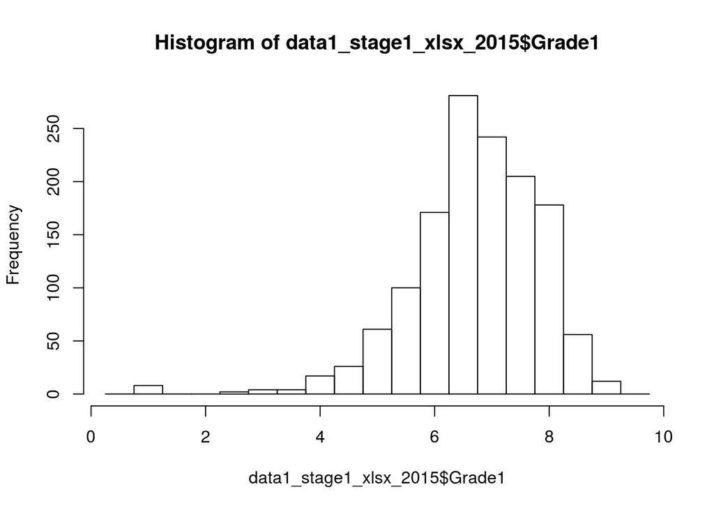

```r
  hist(data1_stage1_xlsx_2015$Grade1,breaks = seq(0.25,9.75,by = 0.5))
```

As a consistency check let us see if the the candidates are ordered correctly (removing the NA values)

```r
  unique(data1_stage1_xlsx_2015$Grade1[!is.na(data1_stage1_xlsx_2015$Grade1)]-sort(data1_stage1_xlsx_2015$Grade1[!is.na(data1_stage1_xlsx_2015$Grade1)],decreasing=TRUE))
```

```
## [1] 0
```

#### 2.3.1.2 After appeal

**DOWNLOAD**

We downloaded the raw data from the direct link at

```r
  file2_stage1_url_2015 <- "https://www.fct.pt/apoios/contratacaodoutorados/investigador-fct/2015/docs/IF2015_Fase1_AposAudienciaPrevia_locked.xlsx"
```

and chose the filename

```r
  file2_stage1_name_2015 <- "2015-file2-stage1-all_candidates_after_appeal.xlsx"
```

To download we call:

```r
  file2_stage1_rel_path_2015 <- make_data_file_download(raw_dir, sub_dir2015, file2_stage1_url_2015,file2_stage1_name_2015)
```

**CLEANUP**

Now we load the file and organise the global sheet

```r
  data2_stage1_xlsx_2015 <- read.xlsx(file2_stage1_rel_path_2015,sheetIndex = 1,startRow = 3, endRow = 1370)[,1:5]
```

The structure is

```r
  str(data2_stage1_xlsx_2015)
```

```
## 'data.frame':    1367 obs. of  5 variables:
##  $ Referência...Reference                            : Factor w/ 1367 levels "IF/00001/2015",..: 62 110 197 470 489 501 550 603 644 872 ...
##  $ Nome.Candidato...Applicant.s.name                 : Factor w/ 1367 levels "Adelino Filipe Carrapatoso Cunha",..: 1045 92 1083 522 250 749 1175 468 106 123 ...
##  $ Instituição.de.Acolhimento...Host.Institution     : Factor w/ 236 levels "Academia das Ciências de Lisboa (ACL)",..: 123 155 213 174 106 131 148 222 86 106 ...
##  $ Classificação.proposta...Recommended.score        : num  9 9 9 9 9 9 9 9 9 9 ...
##  $ X.2ª.fase.Elegibilidade....Elegibility.for.Stage.2: Factor w/ 2 levels "Admitido/Admitted",..: 1 1 1 1 1 1 1 1 1 1 ...
```

The levels for the Reference and Name seem OK because they are all unique as expected. For convenience we now rename the columns:

```r
  colnames(data2_stage1_xlsx_2015) <-c("Ref","Name","Host","Grade2","Status2")
```

Let us check the levels for Status and Final.Grade:

```r
  levels(data2_stage1_xlsx_2015$Status2)
```

```
## [1] "Admitido/Admitted"         "Não Admitido/Not Admitted"
```

```r
  unique(data2_stage1_xlsx_2015$Grade2)
```

```
##  [1] 9.0 8.5 8.0 7.5 7.0 6.5 6.0 5.5 5.0 4.5 4.0 3.5 3.0 2.5 1.0
```

For a uniform notation we rename the levels for the status

```r
  levels(data2_stage1_xlsx_2015$Status2)[1]<- "Yes"
  levels(data2_stage1_xlsx_2015$Status2)[2]<- "No"
```

Let us histogram to make sure everything is OK

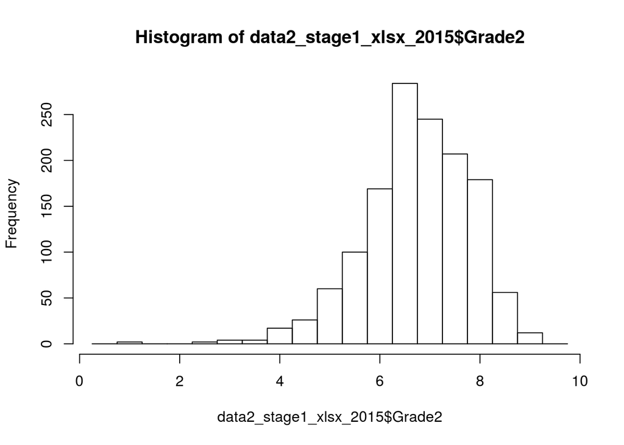

```r
  hist(data2_stage1_xlsx_2015$Grade2,breaks = seq(0.25,9.75,by = 0.5))
```

As a consistency check let us see if the the candidates are ordered correctly (removing the NA values)

```r
  unique(data2_stage1_xlsx_2015$Grade2[!is.na(data2_stage1_xlsx_2015$Grade2)]-sort(data2_stage1_xlsx_2015$Grade2[!is.na(data2_stage1_xlsx_2015$Grade2)],decreasing=TRUE))
```

```
## [1] 0
```

### 2.3.2 Stage 2

#### 2.3.2.1 Before appeal

**DOWNLOAD**

We downloaded the raw data from the direct link at

```r
  file1_stage2_url_2015 <- "https://www.fct.pt/apoios/contratacaodoutorados/investigador-fct/2015/docs/IF2015_Fase2_AposAvaliacao_locked.xlsx"
```

and chose the filename

```r
  file1_stage2_name_2015 <- "2015-file1-stage2-all_candidates_before_appeal.xlsx"
```

To download we call:

```r
  file1_stage2_rel_path_2015<-make_data_file_download(raw_dir, sub_dir2015, file1_stage2_url_2015,file1_stage2_name_2015)
```

**CLEANUP**

Now we load the file and organise the global sheet

```r
  data1_stage2_xlsx_2015_global <- read.xlsx(file1_stage2_rel_path_2015,sheetIndex = 1,startRow = 4, endRow = 701)[,1:4]
```

The structure is

```r
  str(data1_stage2_xlsx_2015_global)
```

```
## 'data.frame':    697 obs. of  4 variables:
##  $ Referência..Reference                        : Factor w/ 697 levels "IF/00001/2015",..: 60 131 172 453 516 445 252 322 677 262 ...
##  $ Candidato...Applicant                        : Factor w/ 697 levels "Adelino Filipe Carrapatoso Cunha",..: 542 338 413 425 618 32 273 242 358 675 ...
##  $ Instiutição.de.Acolhimento...Host.Institution: Factor w/ 183 levels "ARTIS - Instituto de História da Arte, Faculdade de Letras, Universidade de Lisboa (ARTIS)",..: 130 109 131 120 101 136 131 173 151 114 ...
##  $ Classificação.Geral...Overall.Score          : num  9 9 9 9 9 9 9 9 9 9 ...
```

The levels for the Reference and Name seem OK. For convenience we now rename the columns:

```r
  colnames(data1_stage2_xlsx_2015_global) <-c("Ref","Name","Host","Grade3")
```

Let us check the values:

```r
  unique(data1_stage2_xlsx_2015_global$Grade3)
```

```
## [1] 9 8 7 6 5
```

Let us histogram to make sure everything is OK

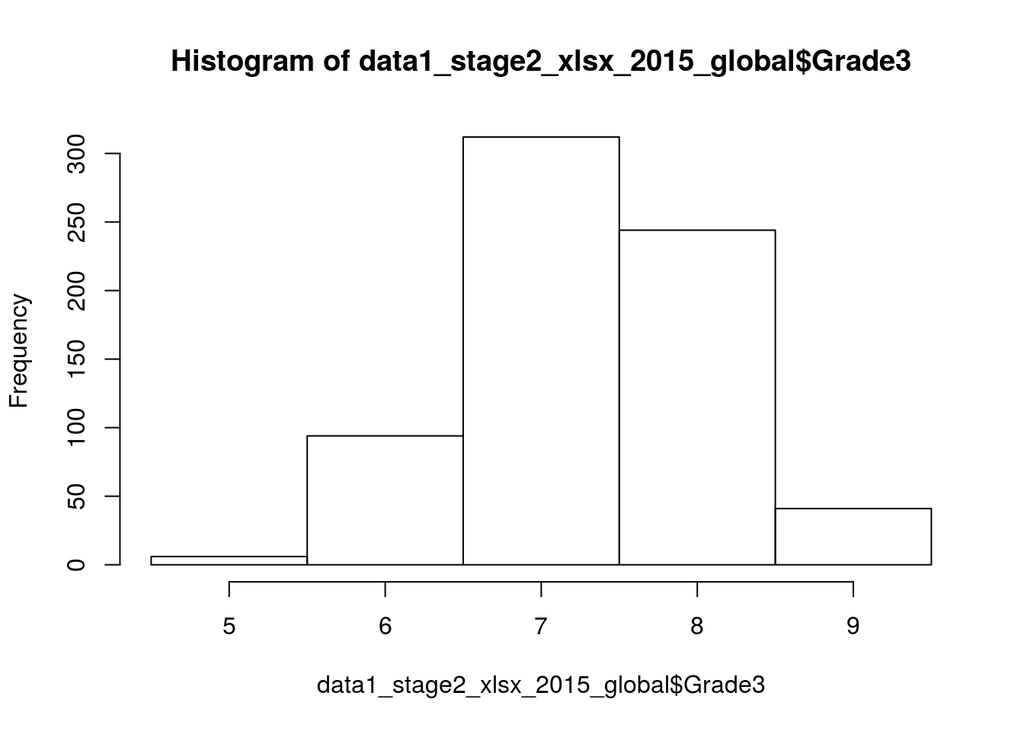

```r
  hist(data1_stage2_xlsx_2015_global$Grade3,breaks = seq(4.5,9.5,by = 1))
```

As a consistency check let us see if the candidates are ordered correctly

```r
  unique(data1_stage2_xlsx_2015_global$Grade3-sort(data1_stage2_xlsx_2015_global$Grade3,decreasing=TRUE))
```

```
## [1] 0
```

But now, in this stage we have information for the various individual panels with detailed scores.

```r
  load_panel2015<- function(round,input_file,panel_name,sheet_num, start_row, end_row, ncolumns){
    # read data
    data <- read.xlsx(input_file,sheetIndex = sheet_num,startRow = start_row, endRow = end_row)[,1:ncolumns]
    # Rename columns
    colnames(data)<-c("Ref","Name",paste("Grade",round,sep = ""),paste("WGrade",round,sep = ""),paste("CVGrade",round,sep = ""),paste("ResearchGrade",round,sep = ""),paste("CareerPlanGrade",round,sep = ""),paste("Status",round,sep = ""))
    # Remove the level "Yes*" to be "Yes" and "*" to "Reserve"
    #levels(data[[paste("Status",round,sep = "")]])<-c("No","Yes","Yes")
    levels(data[[paste("Status",round,sep = "")]])[tolower(levels(data[[paste("Status",round,sep = "")]]))=="yes"]<-"Yes"
    levels(data[[paste("Status",round,sep = "")]])[tolower(levels(data[[paste("Status",round,sep = "")]]))=="yes*"]<-"Yes"
    levels(data[[paste("Status",round,sep = "")]])[tolower(levels(data[[paste("Status",round,sep = "")]]))=="no"]<-"No"
    levels(data[[paste("Status",round,sep = "")]])[tolower(levels(data[[paste("Status",round,sep = "")]]))=="*"]<-"Reserve"
    data$Panel <- rep(panel_name,dim(data)[1])
    data[[paste("PanelRank",round,sep = "")]]<- 1:(dim(data)[1])
    # Return data frame after checks
    data
  }
```

Let us load this information.

** Medical Health Sciences **

```r
  data1_stage2_xlsx_2015_med <-load_panel2015("3",file1_stage2_rel_path_2015,"med",2,4,75,8)
  str(data1_stage2_xlsx_2015_med)
```

```
## 'data.frame':    71 obs. of  10 variables:
##  $ Ref             : Factor w/ 71 levels "IF/00030/2015",..: 7 13 20 51 58 49 67 5 8 15 ...
##  $ Name            : Factor w/ 71 levels "Alejandro Khalil Samhan Arias",..: 52 37 41 44 67 4 55 47 56 58 ...
##  $ Grade3          : num  9 9 9 9 9 9 8 8 8 8 ...
##  $ WGrade3         : num  9 9 9 8.6 8.6 8.5 8 8 8 8 ...
##  $ CVGrade3        : num  9 9 9 9 9 9 9 8 8 8 ...
##  $ ResearchGrade3  : num  9 9 9 8 8 8 7 8 8 8 ...
##  $ CareerPlanGrade3: num  9 9 9 9 9 8 7 8 8 8 ...
##  $ Status3         : Factor w/ 2 levels "No","Yes": 2 2 2 2 2 2 2 2 2 2 ...
##  $ Panel           : chr  "med" "med" "med" "med" ...
##  $ PanelRank3      : int  1 2 3 4 5 6 7 8 9 10 ...
```

```r
  head(data1_stage2_xlsx_2015_med)
```

```
##             Ref                                Name Grade3 WGrade3
## 1 IF/00143/2015       Pedro Eduardo Mendes Ferreira      9     9.0
## 2 IF/00328/2015    João Filipe Pedreira de Oliveira      9     9.0
## 3 IF/00425/2015 Manuela Cristina Fernandes Ferreira      9     9.0
## 4 IF/01074/2015         Marco Aurélio Gouveia Alves      9     8.6
## 5 IF/01227/2015                  Sara Alves Xapelli      9     8.6
## 6 IF/01060/2015     Ana Cristina Correia dos Santos      9     8.5
##   CVGrade3 ResearchGrade3 CareerPlanGrade3 Status3 Panel PanelRank3
## 1        9              9                9     Yes   med          1
## 2        9              9                9     Yes   med          2
## 3        9              9                9     Yes   med          3
## 4        9              8                9     Yes   med          4
## 5        9              8                9     Yes   med          5
## 6        9              8                8     Yes   med          6
```

```r
  tail(data1_stage2_xlsx_2015_med)
```

```
##              Ref                                      Name Grade3 WGrade3
## 66 IF/01162/2015              Olga Catarina Lopes Martinho      7     6.5
## 67 IF/01368/2015              Alexandre José Neto Trindade      7     6.5
## 68 IF/00556/2015              Helena Isabel Martins Pópulo      7     6.4
## 69 IF/00664/2015     Vítor Sérgio Soares do Espírito Santo      6     6.2
## 70 IF/00765/2015 Margarida Isabel de Barros Coelho Martins      6     6.0
## 71 IF/00896/2015            Ana Margarida Martins de Sousa      6     5.5
##    CVGrade3 ResearchGrade3 CareerPlanGrade3 Status3 Panel PanelRank3
## 66        7              6                6      No   med         66
## 67        7              6                6      No   med         67
## 68        6              7                6      No   med         68
## 69        6              6                8      No   med         69
## 70        6              6                6      No   med         70
## 71        6              5                5      No   med         71
```

** Exact Sciences **

```r
  data1_stage2_xlsx_2015_sci <-load_panel2015("3",file1_stage2_rel_path_2015,"sci",3,4,137,8)
  str(data1_stage2_xlsx_2015_sci)
```

```
## 'data.frame':    133 obs. of  10 variables:
##  $ Ref             : Factor w/ 133 levels "IF/00007/2015",..: 46 67 129 49 73 127 113 1 70 78 ...
##  $ Name            : Factor w/ 133 levels "Alexandra Teresa Pires Carvalho",..: 61 48 75 128 104 4 66 63 22 57 ...
##  $ Grade3          : num  9 9 9 9 9 9 9 8 8 8 ...
##  $ WGrade3         : num  9 9 9 8.6 8.6 8.6 8.6 8.5 8.4 8.4 ...
##  $ CVGrade3        : num  9 9 9 9 9 9 9 9 8 8 ...
##  $ ResearchGrade3  : num  9 9 9 8 8 8 8 8 9 9 ...
##  $ CareerPlanGrade3: num  9 9 9 9 9 9 9 8 8 8 ...
##  $ Status3         : Factor w/ 2 levels "No","Yes": 2 2 2 2 2 2 2 2 2 2 ...
##  $ Panel           : chr  "sci" "sci" "sci" "sci" ...
##  $ PanelRank3      : int  1 2 3 4 5 6 7 8 9 10 ...
```

```r
  head(data1_stage2_xlsx_2015_sci)
```

```
##             Ref                                         Name Grade3
## 1 IF/00624/2015                 Gonçalo José Lopes Bernardes      9
## 2 IF/00780/2015  Filipa Margarida Barradas de Morais Marcelo      9
## 3 IF/01635/2015 Jorge Miguel Ramos Domingues Ferreira Vieira      9
## 4 IF/00650/2015                         Vardan Zh. Adibekyan      9
## 5 IF/00852/2015                    Nelson Jose Godinho Nunes      9
## 6 IF/01607/2015                              Alexey Koshelev      9
##   WGrade3 CVGrade3 ResearchGrade3 CareerPlanGrade3 Status3 Panel
## 1     9.0        9              9                9     Yes   sci
## 2     9.0        9              9                9     Yes   sci
## 3     9.0        9              9                9     Yes   sci
## 4     8.6        9              8                9     Yes   sci
## 5     8.6        9              8                9     Yes   sci
## 6     8.6        9              8                9     Yes   sci
##   PanelRank3
## 1          1
## 2          2
## 3          3
## 4          4
## 5          5
## 6          6
```

```r
  tail(data1_stage2_xlsx_2015_sci)
```

```
##               Ref                               Name Grade3 WGrade3
## 128 IF/00245/2015          Joao Antonio Tomasio Pina      6     6.1
## 129 IF/01268/2015        Filipe Miguel Peres Agapito      6     6.0
## 130 IF/01451/2015 Mohammed Sadeq Abdulhameed Al-Rawi      6     6.0
## 131 IF/00660/2015          Luís Miguel Teodoro Frija      5     5.5
## 132 IF/00878/2015  Maria Rita Mendes Bordalo Ventura      5     5.5
## 133 IF/01026/2015      Cláudia Maria Pereira Cardoso      5     5.5
##     CVGrade3 ResearchGrade3 CareerPlanGrade3 Status3 Panel PanelRank3
## 128        6              6                7      No   sci        128
## 129        6              6                6      No   sci        129
## 130        6              6                6      No   sci        130
## 131        6              5                5      No   sci        131
## 132        6              5                5      No   sci        132
## 133        5              6                6      No   sci        133
```

** Environmental Agricultural Sciences **

```r
  data1_stage2_xlsx_2015_env <-load_panel2015("3",file1_stage2_rel_path_2015,"env",4,4,105,8)
  str(data1_stage2_xlsx_2015_env)
```

```
## 'data.frame':    101 obs. of  10 variables:
##  $ Ref             : Factor w/ 101 levels "IF/00010/2015",..: 21 26 48 59 16 50 60 82 99 12 ...
##  $ Name            : Factor w/ 101 levels "Alberto Carlos de Oliveira Antunes de Azevedo",..: 76 67 59 34 8 27 96 48 89 64 ...
##  $ Grade3          : num  9 9 9 9 9 8 8 8 8 8 ...
##  $ WGrade3         : num  9 8.5 8.5 8.5 8.5 8.5 8.5 8.5 8.5 8.4 ...
##  $ CVGrade3        : num  9 9 9 9 8 9 9 9 9 8 ...
##  $ ResearchGrade3  : num  9 8 8 8 9 8 8 8 8 9 ...
##  $ CareerPlanGrade3: num  9 8 8 8 9 8 8 8 8 8 ...
##  $ Status3         : Factor w/ 2 levels "No","Yes": 2 2 2 2 2 2 2 2 2 2 ...
##  $ Panel           : chr  "env" "env" "env" "env" ...
##  $ PanelRank3      : int  1 2 3 4 5 6 7 8 9 10 ...
```

```r
  head(data1_stage2_xlsx_2015_env)
```

```
##             Ref                              Name Grade3 WGrade3 CVGrade3
## 1 IF/00265/2015           Pedro Manuel Broa Costa      9     9.0        9
## 2 IF/00314/2015                Marta Otero Cabero      9     8.5        9
## 3 IF/00802/2015  Marco Paulo Gomes de Sousa Lucas      9     8.5        9
## 4 IF/00940/2015          Gil Pessanha Penha-Lopes      9     8.5        9
## 5 IF/00169/2015 Ana Margarida Costa Macedo Fortes      9     8.5        8
## 6 IF/00817/2015    Emanuel Nemésio de Sousa Dutra      8     8.5        9
##   ResearchGrade3 CareerPlanGrade3 Status3 Panel PanelRank3
## 1              9                9     Yes   env          1
## 2              8                8     Yes   env          2
## 3              8                8     Yes   env          3
## 4              8                8     Yes   env          4
## 5              9                9     Yes   env          5
## 6              8                8     Yes   env          6
```

```r
  tail(data1_stage2_xlsx_2015_env)
```

```
##               Ref                                       Name Grade3
## 96  IF/00097/2015                       Anthony Steven Danko      6
## 97  IF/00678/2015             Nélia Cristina da Costa Mestre      6
## 98  IF/00512/2015                             Vittorio Zanon      6
## 99  IF/00438/2015               Daniela Rebelo de Figueiredo      6
## 100 IF/00229/2015                 João Miguel Magalhães Neto      5
## 101 IF/00786/2015 Amélia Paula Martins Marinho Dias dos Reis      5
##     WGrade3 CVGrade3 ResearchGrade3 CareerPlanGrade3 Status3 Panel
## 96      6.1        6              6                7      No   env
## 97      6.0        6              6                6      No   env
## 98      6.0        6              6                6      No   env
## 99      5.9        6              6                5      No   env
## 100     5.9        7              5                4      No   env
## 101     5.1        6              4                5      No   env
##     PanelRank3
## 96          96
## 97          97
## 98          98
## 99          99
## 100        100
## 101        101
```

** Engineering and Technology ** NOTE: In this panel I have removed the last 2 candidates that quit the competition.

```r
  data1_stage2_xlsx_2015_eng <-load_panel2015("3",file1_stage2_rel_path_2015,"eng",5,4,162,8)
  str(data1_stage2_xlsx_2015_eng)
```

```
## 'data.frame':    158 obs. of  10 variables:
##  $ Ref             : Factor w/ 158 levels "IF/00015/2015",..: 149 66 10 14 25 53 64 131 138 5 ...
##  $ Name            : Factor w/ 158 levels "Adelino Filipe Carrapatoso Cunha",..: 102 49 64 10 134 26 46 83 80 116 ...
##  $ Grade3          : num  9 9 9 9 9 9 9 9 9 8 ...
##  $ WGrade3         : num  9 8.6 8.5 8.5 8.5 8.5 8.5 8.5 8.5 8.5 ...
##  $ CVGrade3        : num  9 9 9 9 9 9 9 9 9 9 ...
##  $ ResearchGrade3  : num  9 8 8 8 8 8 8 8 8 8 ...
##  $ CareerPlanGrade3: num  9 9 8 8 8 8 8 8 8 8 ...
##  $ Status3         : Factor w/ 2 levels "No","Yes": 2 2 2 2 2 2 2 2 2 2 ...
##  $ Panel           : chr  "eng" "eng" "eng" "eng" ...
##  $ PanelRank3      : int  1 2 3 4 5 6 7 8 9 10 ...
```

```r
  head(data1_stage2_xlsx_2015_eng)
```

```
##             Ref                             Name Grade3 WGrade3 CVGrade3
## 1 IF/01566/2015      Matthew Edward Price Davies      9     9.0        9
## 2 IF/00713/2015      Diana Cristina Pinto Leitão      9     8.6        9
## 3 IF/00115/2015  Joana Catarina da Silva Correia      9     8.5        9
## 4 IF/00142/2015     Ana Margarida Palma Teixeira      9     8.5        9
## 5 IF/00286/2015     Rui Miguel Pinheiro Vitorino      9     8.5        9
## 6 IF/00560/2015 Carina Manuela Fernandes Almeida      9     8.5        9
##   ResearchGrade3 CareerPlanGrade3 Status3 Panel PanelRank3
## 1              9                9     Yes   eng          1
## 2              8                9     Yes   eng          2
## 3              8                8     Yes   eng          3
## 4              8                8     Yes   eng          4
## 5              8                8     Yes   eng          5
## 6              8                8     Yes   eng          6
```

```r
  tail(data1_stage2_xlsx_2015_eng)
```

```
##               Ref                                     Name Grade3 WGrade3
## 153 IF/01483/2015                 Rolando da Silva Martins      6     6.1
## 154 IF/00567/2015      Cristiana da Mota Martins Gonçalves      6     6.0
## 155 IF/01255/2015                              Olena Okhay      6     6.0
## 156 IF/01294/2015 Ana Isabel Moreira da Cruz Lobo Ferreira      6     6.0
## 157 IF/01062/2015    Joana Catarina Rocha Moreira da Silva      6     5.9
## 158 IF/01033/2015            Pedro Miguel da Silva Martins      6     5.6
##     CVGrade3 ResearchGrade3 CareerPlanGrade3 Status3 Panel PanelRank3
## 153        6              6                7      No   eng        153
## 154        6              6                6      No   eng        154
## 155        6              6                6      No   eng        155
## 156        6              6                6      No   eng        156
## 157        5              7                6      No   eng        157
## 158        6              5                6      No   eng        158
```

** Natural Animal Sciences **

```r
  data1_stage2_xlsx_2015_nat <-load_panel2015("3",file1_stage2_rel_path_2015,"nat",6,4,106,8)
  str(data1_stage2_xlsx_2015_nat)
```

```
## 'data.frame':    102 obs. of  10 variables:
##  $ Ref             : Factor w/ 102 levels "IF/00001/2015",..: 43 72 30 32 79 57 78 20 27 38 ...
##  $ Name            : Factor w/ 102 levels "Afonso Silva Pinto Basto",..: 21 13 37 62 27 54 41 76 80 55 ...
##  $ Grade3          : num  9 9 9 9 9 8 8 8 8 8 ...
##  $ WGrade3         : num  8.6 8.6 8.5 8.5 8.5 8.5 8.1 8 8 8 ...
##  $ CVGrade3        : num  9 9 8 8 8 9 8 8 8 8 ...
##  $ ResearchGrade3  : num  8 8 9 9 9 8 8 8 8 8 ...
##  $ CareerPlanGrade3: num  9 9 9 9 9 8 9 8 8 8 ...
##  $ Status3         : Factor w/ 2 levels "No","Yes": 2 2 2 2 2 2 2 2 2 2 ...
##  $ Panel           : chr  "nat" "nat" "nat" "nat" ...
##  $ PanelRank3      : int  1 2 3 4 5 6 7 8 9 10 ...
```

```r
  head(data1_stage2_xlsx_2015_nat)
```

```
##             Ref                                          Name Grade3
## 1 IF/00646/2015           Carlos Filipe Ribeiro Lemos Pereira      9
## 2 IF/01105/2015                   Ana Sofia Bregieiro Eulálio      9
## 3 IF/00386/2015                      Fábio Monteiro Fernandes      9
## 4 IF/00414/2015 Maria João Gracias Fernandes da Costa Catalão      9
## 5 IF/01269/2015                           Claus Maria Azzalin      9
## 6 IF/00831/2015                        Karina de Bivar Xavier      8
##   WGrade3 CVGrade3 ResearchGrade3 CareerPlanGrade3 Status3 Panel
## 1     8.6        9              8                9     Yes   nat
## 2     8.6        9              8                9     Yes   nat
## 3     8.5        8              9                9     Yes   nat
## 4     8.5        8              9                9     Yes   nat
## 5     8.5        8              9                9     Yes   nat
## 6     8.5        9              8                8     Yes   nat
##   PanelRank3
## 1          1
## 2          2
## 3          3
## 4          4
## 5          5
## 6          6
```

```r
  tail(data1_stage2_xlsx_2015_nat)
```

```
##               Ref                                Name Grade3 WGrade3
## 97  IF/01582/2015      Ana Catarina Ferreira da Silva      6     6.1
## 98  IF/01603/2015               Patricia Diaz-Rosales      6     6.1
## 99  IF/01501/2015            Afonso Silva Pinto Basto      6     6.0
## 100 IF/01542/2015     Eliana Alexandra Sousa Jerónimo      6     6.0
## 101 IF/00242/2015              Joana Raimundo Pimenta      6     5.7
## 102 IF/00800/2015 Gustavo Oliveira de Meneses Martins      6     5.6
##     CVGrade3 ResearchGrade3 CareerPlanGrade3 Status3 Panel PanelRank3
## 97         6              6                7      No   nat         97
## 98         6              6                7      No   nat         98
## 99         6              6                6      No   nat         99
## 100        6              6                6      No   nat        100
## 101        6              5                7      No   nat        101
## 102        6              5                6      No   nat        102
```

** Social Sciences **

```r
  data1_stage2_xlsx_2015_soc <-load_panel2015("3",file1_stage2_rel_path_2015,"soc",7,4,56,8)
  str(data1_stage2_xlsx_2015_soc)
```

```
## 'data.frame':    52 obs. of  10 variables:
##  $ Ref             : Factor w/ 52 levels "IF/00073/2015",..: 39 11 5 14 3 25 52 22 27 19 ...
##  $ Name            : Factor w/ 52 levels "Ana Alexandra Carvalheira dos Santos",..: 16 32 11 47 45 5 48 6 3 18 ...
##  $ Grade3          : num  9 9 8 8 8 8 8 8 8 8 ...
##  $ WGrade3         : num  8.5 8.4 8.1 8.1 8 8 8 7.6 7.6 7.5 ...
##  $ CVGrade3        : num  9 8 9 8 8 8 8 8 8 7 ...
##  $ ResearchGrade3  : num  8 9 7 8 8 8 8 7 7 8 ...
##  $ CareerPlanGrade3: num  8 8 8 9 8 8 8 8 8 8 ...
##  $ Status3         : Factor w/ 2 levels "No","Yes": 2 2 2 2 2 2 2 2 2 2 ...
##  $ Panel           : chr  "soc" "soc" "soc" "soc" ...
##  $ PanelRank3      : int  1 2 3 4 5 6 7 8 9 10 ...
```

```r
  head(data1_stage2_xlsx_2015_soc)
```

```
##             Ref                                    Name Grade3 WGrade3
## 1 IF/01261/2015                            Diego Garzia      9     8.5
## 2 IF/00506/2015                   Marcelo Oscar Camerlo      9     8.4
## 3 IF/00172/2015             Armando César Ferreira Lima      8     8.1
## 4 IF/00533/2015          Susana Manuela da Silva Araújo      8     8.1
## 5 IF/00091/2015 Sandra da Conceição Ribeiro de Carvalho      8     8.0
## 6 IF/00830/2015          Ana Patrícia Teixeira Pinheiro      8     8.0
##   CVGrade3 ResearchGrade3 CareerPlanGrade3 Status3 Panel PanelRank3
## 1        9              8                8     Yes   soc          1
## 2        8              9                8     Yes   soc          2
## 3        9              7                8     Yes   soc          3
## 4        8              8                9     Yes   soc          4
## 5        8              8                8     Yes   soc          5
## 6        8              8                8     Yes   soc          6
```

```r
  tail(data1_stage2_xlsx_2015_soc)
```

```
##              Ref                                                      Name
## 47 IF/01482/2015                                               Joerg Nowak
## 48 IF/00418/2015                                            luis inostroza
## 49 IF/00462/2015                   Tiago João Correia Fonseca da Conceição
## 50 IF/00630/2015                  Angela Cristina Carvalho da Silva Santos
## 51 IF/00886/2015 Susana Maria Serrão Carinhas Santinho Costa Pires Marques
## 52 IF/00549/2015                                        Giovanna Micarelli
##    Grade3 WGrade3 CVGrade3 ResearchGrade3 CareerPlanGrade3 Status3 Panel
## 47      6     6.4        6              7                6      No   soc
## 48      6     6.2        7              5                7      No   soc
## 49      6     6.2        7              5                7      No   soc
## 50      6     6.1        6              6                7      No   soc
## 51      6     6.1        6              6                7      No   soc
## 52      5     5.6        5              6                7      No   soc
##    PanelRank3
## 47         47
## 48         48
## 49         49
## 50         50
## 51         51
## 52         52
```

** Humanities **

```r
  data1_stage2_xlsx_2015_hum <-load_panel2015("3",file1_stage2_rel_path_2015,"hum",8,4,84,8)
  str(data1_stage2_xlsx_2015_hum)
```

```
## 'data.frame':    80 obs. of  10 variables:
##  $ Ref             : Factor w/ 80 levels "IF/00042/2015",..: 68 78 48 51 21 17 29 39 52 28 ...
##  $ Name            : Factor w/ 80 levels "Afonso Nuno Henrique Martins",..: 73 39 78 49 65 34 11 7 60 32 ...
##  $ Grade3          : num  9 9 9 9 9 9 9 8 8 8 ...
##  $ WGrade3         : num  9 9 9 8.9 8.6 8.5 8.5 8.4 8.4 8.1 ...
##  $ CVGrade3        : num  9 9 9 9 9 9 9 8 8 9 ...
##  $ ResearchGrade3  : num  9 9 9 9 8 8 8 9 9 7 ...
##  $ CareerPlanGrade3: num  9 9 9 8 9 8 8 8 8 8 ...
##  $ Status3         : Factor w/ 2 levels "No","Yes": 2 2 2 2 2 2 2 2 2 2 ...
##  $ Panel           : chr  "hum" "hum" "hum" "hum" ...
##  $ PanelRank3      : int  1 2 3 4 5 6 7 8 9 10 ...
```

```r
  head(data1_stage2_xlsx_2015_hum)
```

```
##             Ref                          Name Grade3 WGrade3 CVGrade3
## 1 IF/01579/2015 Rui Miguel Ponte Vieira Lopes      9     9.0        9
## 2 IF/01671/2015                   Iris Borowy      9     9.0        9
## 3 IF/01157/2015       Vera Lúcia Dias Aldeias      9     9.0        9
## 4 IF/01229/2015        KATIA DAWN HAY RODGERS      9     8.9        9
## 5 IF/00606/2015 Patricia Isabel Lontro Vieira      9     8.6        9
## 6 IF/00537/2015                 GIULIA LAMONI      9     8.5        9
##   ResearchGrade3 CareerPlanGrade3 Status3 Panel PanelRank3
## 1              9                9     Yes   hum          1
## 2              9                9     Yes   hum          2
## 3              9                9     Yes   hum          3
## 4              9                8     Yes   hum          4
## 5              8                9     Yes   hum          5
## 6              8                8     Yes   hum          6
```

```r
  tail(data1_stage2_xlsx_2015_hum)
```

```
##              Ref
## 75 IF/01580/2015
## 76 IF/00157/2015
## 77 IF/01555/2015
## 78 IF/01695/2015
## 79 IF/00416/2015
## 80 IF/00967/2015
##                                                          Name Grade3
## 75                            José Francisco Ferreira Queiroz      6
## 76                        Alexandra Paula de Carvalho Antunes      6
## 77 Margarida Maria Almeida de Campos Rodrigues de Moura Elias      6
## 78                                                 Itay Shani      6
## 79                      Eliana Manuel de Matos Oliveira Pinho      6
## 80                                             Paolo Stellino      6
##    WGrade3 CVGrade3 ResearchGrade3 CareerPlanGrade3 Status3 Panel
## 75     6.0        7              5                5      No   hum
## 76     6.0        6              6                6      No   hum
## 77     6.0        6              6                6      No   hum
## 78     6.0        6              6                6      No   hum
## 79     5.6        6              5                6      No   hum
## 80     5.5        6              5                5      No   hum
##    PanelRank3
## 75         75
## 76         76
## 77         77
## 78         78
## 79         79
## 80         80
```

### 2.3.3 FINAL DATA FRAME OUTPUT

Now we are going to merge all the data from the various data frames. We want a data frame with the following columns:

- Ref
- Name
- Host
- Panel
- Grade1
- Rank1
- Status1
- Grade2
- Rank2
- Status2
- Grade3
- WGrade3
- CVGrade3
- ResearchGrade3
- CareerPlanGrade3
- Rank3
- PanelRank3
- Status3

Let us first list the global data_frames and their dimensions

```r
  dim(data1_stage1_xlsx_2015)
```

```
## [1] 1367    5
```

```r
  dim(data2_stage1_xlsx_2015)
```

```
## [1] 1367    5
```

```r
  dim(data1_stage2_xlsx_2015_global)
```

```
## [1] 697   4
```

Now it is easier to start by creating a data frame only with the candidate details ordered by IF reference.

```r
  data_2015 <- data1_stage1_xlsx_2015[order(data1_stage1_xlsx_2015$Ref),1:3]
  head(data_2015)
```

```
##                Ref                                     Name
## 452  IF/00001/2015                 Jose Manuel Herrera Vega
## 694  IF/00005/2015                  ENRIQUE CERRILLO CUENCA
## 247  IF/00006/2015          Romana Lopes Almeida dos Santos
## 13   IF/00007/2015 Hugo Miguel Baptista Carreira dos Santos
## 975  IF/00008/2015          Ana Mafalda Vaz Martins Pereira
## 1350 IF/00009/2015                     Enrique García Muñoz
##                                                                                         Host
## 452                                                               Universidade de Évora (UE)
## 694  Centro de História de Arte e Investigação Artística da Universidade de Évora (CHAIA/UE)
## 247                                  Faculdade de Ciências da Universidade de Lisboa (FC/UL)
## 13                                     Unidade de Ciências Biomoleculares Aplicadas (UCIBIO)
## 975                 Unidade de Química Orgânica, Produtos Naturais e Agroalimentares (DQ/UA)
## 1350   Centro de Investigação em Biodiversidade de Recursos Genéticos (CIBIO/ICETA-Porto/UP)
```

```r
  tail(data_2015)
```

```
##                Ref                                 Name
## 1349 IF/01692/2015                       sabina de cavi
## 693  IF/01695/2015                           Itay Shani
## 451  IF/01696/2015            Biljana Sljukic Paunkovic
## 1332 IF/01697/2015                    Lyubchik Svetlana
## 973  IF/01698/2015 Stanislav Konstantinovich Kondratyev
## 974  IF/01699/2015                        Cédric Camier
##                                                                                            Host
## 1349 ARTIS - Instituto de História da Arte, Faculdade de Letras, Universidade de Lisboa (ARTIS)
## 693                                                                 Centro de Filosofia (CF/UL)
## 451                               Centro de Física e Engenharia de Materiais Avançados (CeFEMA)
## 1332     Laboratório Associado para a Química Verde - Tecnologias e Processos Limpos (REQUIMTE)
## 973                                                            Centro de Matemática (CM/FCT/UC)
## 974                                                      INESC Tecnologia e Ciência (INESC TEC)
```

Next, we create all all the columns we want to exist.

```r
  nrecords <- dim(data_2015)[1]
  data_2015$Panel <- rep("empty",nrecords)

  data_2015$Grade1 <- rep(NA,nrecords)
  data_2015$Rank1 <- rep(NA,nrecords)
  data_2015$Status1 <- rep("empty",nrecords)

  data_2015$Grade2 <- rep(NA,nrecords)
  data_2015$Rank2 <- rep(NA,nrecords)
  data_2015$Status2 <- rep("empty",nrecords)

  data_2015$Grade3 <- rep(NA,nrecords)
  data_2015$WGrade3 <- rep(NA,nrecords)
  data_2015$CVGrade3 <- rep(NA,nrecords)
  data_2015$ResearchGrade3 <- rep(NA,nrecords)
  data_2015$CareerPlanGrade3 <- rep(NA,nrecords)
  data_2015$Rank3 <- rep(NA,nrecords)
  data_2015$PanelRank3 <- rep(NA,nrecords)
  data_2015$Status3 <- rep("empty",nrecords)

  head(data_2015)
```

```
##                Ref                                     Name
## 452  IF/00001/2015                 Jose Manuel Herrera Vega
## 694  IF/00005/2015                  ENRIQUE CERRILLO CUENCA
## 247  IF/00006/2015          Romana Lopes Almeida dos Santos
## 13   IF/00007/2015 Hugo Miguel Baptista Carreira dos Santos
## 975  IF/00008/2015          Ana Mafalda Vaz Martins Pereira
## 1350 IF/00009/2015                     Enrique García Muñoz
##                                                                                         Host
## 452                                                               Universidade de Évora (UE)
## 694  Centro de História de Arte e Investigação Artística da Universidade de Évora (CHAIA/UE)
## 247                                  Faculdade de Ciências da Universidade de Lisboa (FC/UL)
## 13                                     Unidade de Ciências Biomoleculares Aplicadas (UCIBIO)
## 975                 Unidade de Química Orgânica, Produtos Naturais e Agroalimentares (DQ/UA)
## 1350   Centro de Investigação em Biodiversidade de Recursos Genéticos (CIBIO/ICETA-Porto/UP)
##      Panel Grade1 Rank1 Status1 Grade2 Rank2 Status2 Grade3 WGrade3
## 452  empty     NA    NA   empty     NA    NA   empty     NA      NA
## 694  empty     NA    NA   empty     NA    NA   empty     NA      NA
## 247  empty     NA    NA   empty     NA    NA   empty     NA      NA
## 13   empty     NA    NA   empty     NA    NA   empty     NA      NA
## 975  empty     NA    NA   empty     NA    NA   empty     NA      NA
## 1350 empty     NA    NA   empty     NA    NA   empty     NA      NA
##      CVGrade3 ResearchGrade3 CareerPlanGrade3 Rank3 PanelRank3 Status3
## 452        NA             NA               NA    NA         NA   empty
## 694        NA             NA               NA    NA         NA   empty
## 247        NA             NA               NA    NA         NA   empty
## 13         NA             NA               NA    NA         NA   empty
## 975        NA             NA               NA    NA         NA   empty
## 1350       NA             NA               NA    NA         NA   empty
```

```r
  tail(data_2015)
```

```
##                Ref                                 Name
## 1349 IF/01692/2015                       sabina de cavi
## 693  IF/01695/2015                           Itay Shani
## 451  IF/01696/2015            Biljana Sljukic Paunkovic
## 1332 IF/01697/2015                    Lyubchik Svetlana
## 973  IF/01698/2015 Stanislav Konstantinovich Kondratyev
## 974  IF/01699/2015                        Cédric Camier
##                                                                                            Host
## 1349 ARTIS - Instituto de História da Arte, Faculdade de Letras, Universidade de Lisboa (ARTIS)
## 693                                                                 Centro de Filosofia (CF/UL)
## 451                               Centro de Física e Engenharia de Materiais Avançados (CeFEMA)
## 1332     Laboratório Associado para a Química Verde - Tecnologias e Processos Limpos (REQUIMTE)
## 973                                                            Centro de Matemática (CM/FCT/UC)
## 974                                                      INESC Tecnologia e Ciência (INESC TEC)
##      Panel Grade1 Rank1 Status1 Grade2 Rank2 Status2 Grade3 WGrade3
## 1349 empty     NA    NA   empty     NA    NA   empty     NA      NA
## 693  empty     NA    NA   empty     NA    NA   empty     NA      NA
## 451  empty     NA    NA   empty     NA    NA   empty     NA      NA
## 1332 empty     NA    NA   empty     NA    NA   empty     NA      NA
## 973  empty     NA    NA   empty     NA    NA   empty     NA      NA
## 974  empty     NA    NA   empty     NA    NA   empty     NA      NA
##      CVGrade3 ResearchGrade3 CareerPlanGrade3 Rank3 PanelRank3 Status3
## 1349       NA             NA               NA    NA         NA   empty
## 693        NA             NA               NA    NA         NA   empty
## 451        NA             NA               NA    NA         NA   empty
## 1332       NA             NA               NA    NA         NA   empty
## 973        NA             NA               NA    NA         NA   empty
## 974        NA             NA               NA    NA         NA   empty
```

Next we populate each column by retrieving the information from each data frame. The first data_frame is the easiest

```r
  data_2015$Grade1 <- data1_stage1_xlsx_2015[order(data1_stage1_xlsx_2015$Ref),"Grade1"]
  data_2015$Status1 <- data1_stage1_xlsx_2015[order(data1_stage1_xlsx_2015$Ref),"Status1"]
  data1_stage1_xlsx_2015$Rank1 <- 1:nrecords
  data_2015$Rank1 <- data1_stage1_xlsx_2015[order(data1_stage1_xlsx_2015$Ref),"Rank1"]
  head(data_2015)
```

```
##                Ref                                     Name
## 452  IF/00001/2015                 Jose Manuel Herrera Vega
## 694  IF/00005/2015                  ENRIQUE CERRILLO CUENCA
## 247  IF/00006/2015          Romana Lopes Almeida dos Santos
## 13   IF/00007/2015 Hugo Miguel Baptista Carreira dos Santos
## 975  IF/00008/2015          Ana Mafalda Vaz Martins Pereira
## 1350 IF/00009/2015                     Enrique García Muñoz
##                                                                                         Host
## 452                                                               Universidade de Évora (UE)
## 694  Centro de História de Arte e Investigação Artística da Universidade de Évora (CHAIA/UE)
## 247                                  Faculdade de Ciências da Universidade de Lisboa (FC/UL)
## 13                                     Unidade de Ciências Biomoleculares Aplicadas (UCIBIO)
## 975                 Unidade de Química Orgânica, Produtos Naturais e Agroalimentares (DQ/UA)
## 1350   Centro de Investigação em Biodiversidade de Recursos Genéticos (CIBIO/ICETA-Porto/UP)
##      Panel Grade1 Rank1 Status1 Grade2 Rank2 Status2 Grade3 WGrade3
## 452  empty    7.0   452     Yes     NA    NA   empty     NA      NA
## 694  empty    6.5   694      No     NA    NA   empty     NA      NA
## 247  empty    7.5   247     Yes     NA    NA   empty     NA      NA
## 13   empty    8.5    13     Yes     NA    NA   empty     NA      NA
## 975  empty    6.0   975      No     NA    NA   empty     NA      NA
## 1350 empty    3.5  1350      No     NA    NA   empty     NA      NA
##      CVGrade3 ResearchGrade3 CareerPlanGrade3 Rank3 PanelRank3 Status3
## 452        NA             NA               NA    NA         NA   empty
## 694        NA             NA               NA    NA         NA   empty
## 247        NA             NA               NA    NA         NA   empty
## 13         NA             NA               NA    NA         NA   empty
## 975        NA             NA               NA    NA         NA   empty
## 1350       NA             NA               NA    NA         NA   empty
```

```r
  tail(data_2015)
```

```
##                Ref                                 Name
## 1349 IF/01692/2015                       sabina de cavi
## 693  IF/01695/2015                           Itay Shani
## 451  IF/01696/2015            Biljana Sljukic Paunkovic
## 1332 IF/01697/2015                    Lyubchik Svetlana
## 973  IF/01698/2015 Stanislav Konstantinovich Kondratyev
## 974  IF/01699/2015                        Cédric Camier
##                                                                                            Host
## 1349 ARTIS - Instituto de História da Arte, Faculdade de Letras, Universidade de Lisboa (ARTIS)
## 693                                                                 Centro de Filosofia (CF/UL)
## 451                               Centro de Física e Engenharia de Materiais Avançados (CeFEMA)
## 1332     Laboratório Associado para a Química Verde - Tecnologias e Processos Limpos (REQUIMTE)
## 973                                                            Centro de Matemática (CM/FCT/UC)
## 974                                                      INESC Tecnologia e Ciência (INESC TEC)
##      Panel Grade1 Rank1 Status1 Grade2 Rank2 Status2 Grade3 WGrade3
## 1349 empty    4.0  1349      No     NA    NA   empty     NA      NA
## 693  empty    7.0   693     Yes     NA    NA   empty     NA      NA
## 451  empty    7.5   451     Yes     NA    NA   empty     NA      NA
## 1332 empty    4.5  1332      No     NA    NA   empty     NA      NA
## 973  empty    6.5   973      No     NA    NA   empty     NA      NA
## 974  empty    6.5   974      No     NA    NA   empty     NA      NA
##      CVGrade3 ResearchGrade3 CareerPlanGrade3 Rank3 PanelRank3 Status3
## 1349       NA             NA               NA    NA         NA   empty
## 693        NA             NA               NA    NA         NA   empty
## 451        NA             NA               NA    NA         NA   empty
## 1332       NA             NA               NA    NA         NA   empty
## 973        NA             NA               NA    NA         NA   empty
## 974        NA             NA               NA    NA         NA   empty
```

```r
  rownames(data_2015)<-NULL
  head(data_2015)
```

```
##             Ref                                     Name
## 1 IF/00001/2015                 Jose Manuel Herrera Vega
## 2 IF/00005/2015                  ENRIQUE CERRILLO CUENCA
## 3 IF/00006/2015          Romana Lopes Almeida dos Santos
## 4 IF/00007/2015 Hugo Miguel Baptista Carreira dos Santos
## 5 IF/00008/2015          Ana Mafalda Vaz Martins Pereira
## 6 IF/00009/2015                     Enrique García Muñoz
##                                                                                      Host
## 1                                                              Universidade de Évora (UE)
## 2 Centro de História de Arte e Investigação Artística da Universidade de Évora (CHAIA/UE)
## 3                                 Faculdade de Ciências da Universidade de Lisboa (FC/UL)
## 4                                   Unidade de Ciências Biomoleculares Aplicadas (UCIBIO)
## 5                Unidade de Química Orgânica, Produtos Naturais e Agroalimentares (DQ/UA)
## 6   Centro de Investigação em Biodiversidade de Recursos Genéticos (CIBIO/ICETA-Porto/UP)
##   Panel Grade1 Rank1 Status1 Grade2 Rank2 Status2 Grade3 WGrade3 CVGrade3
## 1 empty    7.0   452     Yes     NA    NA   empty     NA      NA       NA
## 2 empty    6.5   694      No     NA    NA   empty     NA      NA       NA
## 3 empty    7.5   247     Yes     NA    NA   empty     NA      NA       NA
## 4 empty    8.5    13     Yes     NA    NA   empty     NA      NA       NA
## 5 empty    6.0   975      No     NA    NA   empty     NA      NA       NA
## 6 empty    3.5  1350      No     NA    NA   empty     NA      NA       NA
##   ResearchGrade3 CareerPlanGrade3 Rank3 PanelRank3 Status3
## 1             NA               NA    NA         NA   empty
## 2             NA               NA    NA         NA   empty
## 3             NA               NA    NA         NA   empty
## 4             NA               NA    NA         NA   empty
## 5             NA               NA    NA         NA   empty
## 6             NA               NA    NA         NA   empty
```

```r
  tail(data_2015)
```

```
##                Ref                                 Name
## 1362 IF/01692/2015                       sabina de cavi
## 1363 IF/01695/2015                           Itay Shani
## 1364 IF/01696/2015            Biljana Sljukic Paunkovic
## 1365 IF/01697/2015                    Lyubchik Svetlana
## 1366 IF/01698/2015 Stanislav Konstantinovich Kondratyev
## 1367 IF/01699/2015                        Cédric Camier
##                                                                                            Host
## 1362 ARTIS - Instituto de História da Arte, Faculdade de Letras, Universidade de Lisboa (ARTIS)
## 1363                                                                Centro de Filosofia (CF/UL)
## 1364                              Centro de Física e Engenharia de Materiais Avançados (CeFEMA)
## 1365     Laboratório Associado para a Química Verde - Tecnologias e Processos Limpos (REQUIMTE)
## 1366                                                           Centro de Matemática (CM/FCT/UC)
## 1367                                                     INESC Tecnologia e Ciência (INESC TEC)
##      Panel Grade1 Rank1 Status1 Grade2 Rank2 Status2 Grade3 WGrade3
## 1362 empty    4.0  1349      No     NA    NA   empty     NA      NA
## 1363 empty    7.0   693     Yes     NA    NA   empty     NA      NA
## 1364 empty    7.5   451     Yes     NA    NA   empty     NA      NA
## 1365 empty    4.5  1332      No     NA    NA   empty     NA      NA
## 1366 empty    6.5   973      No     NA    NA   empty     NA      NA
## 1367 empty    6.5   974      No     NA    NA   empty     NA      NA
##      CVGrade3 ResearchGrade3 CareerPlanGrade3 Rank3 PanelRank3 Status3
## 1362       NA             NA               NA    NA         NA   empty
## 1363       NA             NA               NA    NA         NA   empty
## 1364       NA             NA               NA    NA         NA   empty
## 1365       NA             NA               NA    NA         NA   empty
## 1366       NA             NA               NA    NA         NA   empty
## 1367       NA             NA               NA    NA         NA   empty
```

The last step was to remove the original rownames and number them from 1 to nrecords ordered by reference.

For the information in the second file we first check if we can take advantage of the fact that they are almost identical. Let us see if the ordering produced from the Ref are the same

```r
  sum(!(data1_stage1_xlsx_2015$Ref[order(data1_stage1_xlsx_2015$Ref)]==data2_stage1_xlsx_2015$Ref[order(data2_stage1_xlsx_2015$Ref)]))
```

```
## [1] 0
```

So we can just add the file 2 information easily

```r
  data_2015$Grade2 <- data2_stage1_xlsx_2015[order(data2_stage1_xlsx_2015$Ref),"Grade2"]
  data_2015$Status2 <- data2_stage1_xlsx_2015[order(data2_stage1_xlsx_2015$Ref),"Status2"]
  data2_stage1_xlsx_2015$Rank2 <- 1:nrecords
  data_2015$Rank2 <- data2_stage1_xlsx_2015[order(data2_stage1_xlsx_2015$Ref),"Rank2"]
  head(data_2015)
```

```
##             Ref                                     Name
## 1 IF/00001/2015                 Jose Manuel Herrera Vega
## 2 IF/00005/2015                  ENRIQUE CERRILLO CUENCA
## 3 IF/00006/2015          Romana Lopes Almeida dos Santos
## 4 IF/00007/2015 Hugo Miguel Baptista Carreira dos Santos
## 5 IF/00008/2015          Ana Mafalda Vaz Martins Pereira
## 6 IF/00009/2015                     Enrique García Muñoz
##                                                                                      Host
## 1                                                              Universidade de Évora (UE)
## 2 Centro de História de Arte e Investigação Artística da Universidade de Évora (CHAIA/UE)
## 3                                 Faculdade de Ciências da Universidade de Lisboa (FC/UL)
## 4                                   Unidade de Ciências Biomoleculares Aplicadas (UCIBIO)
## 5                Unidade de Química Orgânica, Produtos Naturais e Agroalimentares (DQ/UA)
## 6   Centro de Investigação em Biodiversidade de Recursos Genéticos (CIBIO/ICETA-Porto/UP)
##   Panel Grade1 Rank1 Status1 Grade2 Rank2 Status2 Grade3 WGrade3 CVGrade3
## 1 empty    7.0   452     Yes    7.0   455     Yes     NA      NA       NA
## 2 empty    6.5   694      No    6.5   700      No     NA      NA       NA
## 3 empty    7.5   247     Yes    7.5   248     Yes     NA      NA       NA
## 4 empty    8.5    13     Yes    8.5    13     Yes     NA      NA       NA
## 5 empty    6.0   975      No    6.0   984      No     NA      NA       NA
## 6 empty    3.5  1350      No    3.5  1356      No     NA      NA       NA
##   ResearchGrade3 CareerPlanGrade3 Rank3 PanelRank3 Status3
## 1             NA               NA    NA         NA   empty
## 2             NA               NA    NA         NA   empty
## 3             NA               NA    NA         NA   empty
## 4             NA               NA    NA         NA   empty
## 5             NA               NA    NA         NA   empty
## 6             NA               NA    NA         NA   empty
```

```r
  tail(data_2015)
```

```
##                Ref                                 Name
## 1362 IF/01692/2015                       sabina de cavi
## 1363 IF/01695/2015                           Itay Shani
## 1364 IF/01696/2015            Biljana Sljukic Paunkovic
## 1365 IF/01697/2015                    Lyubchik Svetlana
## 1366 IF/01698/2015 Stanislav Konstantinovich Kondratyev
## 1367 IF/01699/2015                        Cédric Camier
##                                                                                            Host
## 1362 ARTIS - Instituto de História da Arte, Faculdade de Letras, Universidade de Lisboa (ARTIS)
## 1363                                                                Centro de Filosofia (CF/UL)
## 1364                              Centro de Física e Engenharia de Materiais Avançados (CeFEMA)
## 1365     Laboratório Associado para a Química Verde - Tecnologias e Processos Limpos (REQUIMTE)
## 1366                                                           Centro de Matemática (CM/FCT/UC)
## 1367                                                     INESC Tecnologia e Ciência (INESC TEC)
##      Panel Grade1 Rank1 Status1 Grade2 Rank2 Status2 Grade3 WGrade3
## 1362 empty    4.0  1349      No    4.0  1355      No     NA      NA
## 1363 empty    7.0   693     Yes    7.0   660     Yes     NA      NA
## 1364 empty    7.5   451     Yes    7.5   452     Yes     NA      NA
## 1365 empty    4.5  1332      No    4.5  1338      No     NA      NA
## 1366 empty    6.5   973      No    6.5   978      No     NA      NA
## 1367 empty    6.5   974      No    6.5   979      No     NA      NA
##      CVGrade3 ResearchGrade3 CareerPlanGrade3 Rank3 PanelRank3 Status3
## 1362       NA             NA               NA    NA         NA   empty
## 1363       NA             NA               NA    NA         NA   empty
## 1364       NA             NA               NA    NA         NA   empty
## 1365       NA             NA               NA    NA         NA   empty
## 1366       NA             NA               NA    NA         NA   empty
## 1367       NA             NA               NA    NA         NA   empty
```

Let us just check that there are only small differences.

```r
  sum(is.na(data_2015$Grade1))
```

```
## [1] 0
```

```r
  sum(is.na(data_2015$Grade2))
```

```
## [1] 0
```

```r
  sum(!(data_2015$Grade2[!is.na(data_2015$Grade2)]==data_2015$Grade1[!is.na(data_2015$Grade1)]))
```

```
## [1] 13
```

```r
  sum(is.na(data_2015$Status1))
```

```
## [1] 0
```

```r
  sum(is.na(data_2015$Status2))
```

```
## [1] 0
```

```r
  sum(!(data_2015$Status2[!is.na(data_2015$Status2)]==data_2015$Status1[!is.na(data_2015$Status1)]))
```

```
## [1] 6
```

For the remaining files we follow a similar strategy. **file 3**

```r
  nrecords3 <- dim(data1_stage2_xlsx_2015_global)[1]
  data1_stage2_xlsx_2015_global$Rank3 <- 1:nrecords3
  for (i in 1:nrecords3) {
    # Determine position of record in final data_frame
    rowpos <- data_2015$Ref==as.character(data1_stage2_xlsx_2015_global[i,"Ref"])
    data_2015$Rank3[rowpos] <- data1_stage2_xlsx_2015_global[i,"Rank3"]
  }
  head(data_2015)
```

```
##             Ref                                     Name
## 1 IF/00001/2015                 Jose Manuel Herrera Vega
## 2 IF/00005/2015                  ENRIQUE CERRILLO CUENCA
## 3 IF/00006/2015          Romana Lopes Almeida dos Santos
## 4 IF/00007/2015 Hugo Miguel Baptista Carreira dos Santos
## 5 IF/00008/2015          Ana Mafalda Vaz Martins Pereira
## 6 IF/00009/2015                     Enrique García Muñoz
##                                                                                      Host
## 1                                                              Universidade de Évora (UE)
## 2 Centro de História de Arte e Investigação Artística da Universidade de Évora (CHAIA/UE)
## 3                                 Faculdade de Ciências da Universidade de Lisboa (FC/UL)
## 4                                   Unidade de Ciências Biomoleculares Aplicadas (UCIBIO)
## 5                Unidade de Química Orgânica, Produtos Naturais e Agroalimentares (DQ/UA)
## 6   Centro de Investigação em Biodiversidade de Recursos Genéticos (CIBIO/ICETA-Porto/UP)
##   Panel Grade1 Rank1 Status1 Grade2 Rank2 Status2 Grade3 WGrade3 CVGrade3
## 1 empty    7.0   452     Yes    7.0   455     Yes     NA      NA       NA
## 2 empty    6.5   694      No    6.5   700      No     NA      NA       NA
## 3 empty    7.5   247     Yes    7.5   248     Yes     NA      NA       NA
## 4 empty    8.5    13     Yes    8.5    13     Yes     NA      NA       NA
## 5 empty    6.0   975      No    6.0   984      No     NA      NA       NA
## 6 empty    3.5  1350      No    3.5  1356      No     NA      NA       NA
##   ResearchGrade3 CareerPlanGrade3 Rank3 PanelRank3 Status3
## 1             NA               NA   235         NA   empty
## 2             NA               NA    NA         NA   empty
## 3             NA               NA   233         NA   empty
## 4             NA               NA    72         NA   empty
## 5             NA               NA    NA         NA   empty
## 6             NA               NA    NA         NA   empty
```

```r
  tail(data_2015)
```

```
##                Ref                                 Name
## 1362 IF/01692/2015                       sabina de cavi
## 1363 IF/01695/2015                           Itay Shani
## 1364 IF/01696/2015            Biljana Sljukic Paunkovic
## 1365 IF/01697/2015                    Lyubchik Svetlana
## 1366 IF/01698/2015 Stanislav Konstantinovich Kondratyev
## 1367 IF/01699/2015                        Cédric Camier
##                                                                                            Host
## 1362 ARTIS - Instituto de História da Arte, Faculdade de Letras, Universidade de Lisboa (ARTIS)
## 1363                                                                Centro de Filosofia (CF/UL)
## 1364                              Centro de Física e Engenharia de Materiais Avançados (CeFEMA)
## 1365     Laboratório Associado para a Química Verde - Tecnologias e Processos Limpos (REQUIMTE)
## 1366                                                           Centro de Matemática (CM/FCT/UC)
## 1367                                                     INESC Tecnologia e Ciência (INESC TEC)
##      Panel Grade1 Rank1 Status1 Grade2 Rank2 Status2 Grade3 WGrade3
## 1362 empty    4.0  1349      No    4.0  1355      No     NA      NA
## 1363 empty    7.0   693     Yes    7.0   660     Yes     NA      NA
## 1364 empty    7.5   451     Yes    7.5   452     Yes     NA      NA
## 1365 empty    4.5  1332      No    4.5  1338      No     NA      NA
## 1366 empty    6.5   973      No    6.5   978      No     NA      NA
## 1367 empty    6.5   974      No    6.5   979      No     NA      NA
##      CVGrade3 ResearchGrade3 CareerPlanGrade3 Rank3 PanelRank3 Status3
## 1362       NA             NA               NA    NA         NA   empty
## 1363       NA             NA               NA   689         NA   empty
## 1364       NA             NA               NA   485         NA   empty
## 1365       NA             NA               NA    NA         NA   empty
## 1366       NA             NA               NA    NA         NA   empty
## 1367       NA             NA               NA    NA         NA   empty
```

Now we retrieve information from each panel but we first concatenate in a big dataframe

```r
  data1_stage2_xlsx_2015_panels<-rbind(data1_stage2_xlsx_2015_hum,data1_stage2_xlsx_2015_soc,data1_stage2_xlsx_2015_nat,data1_stage2_xlsx_2015_env,data1_stage2_xlsx_2015_med,data1_stage2_xlsx_2015_eng,data1_stage2_xlsx_2015_sci)
```

And finally we re-distribute the values

```r
  nrecords3 <- dim(data1_stage2_xlsx_2015_panels)[1]
  for (i in 1:nrecords3) {
    # Determine position of record in final data_fram
    rowpos <- data_2015$Ref==as.character(data1_stage2_xlsx_2015_panels[i,"Ref"])
    data_2015$Grade3[rowpos] <- data1_stage2_xlsx_2015_panels[i,"Grade3"]
    data_2015$WGrade3[rowpos] <- data1_stage2_xlsx_2015_panels[i,"WGrade3"]
    data_2015$CVGrade3[rowpos] <- data1_stage2_xlsx_2015_panels[i,"CVGrade3"]
    data_2015$ResearchGrade3[rowpos] <- data1_stage2_xlsx_2015_panels[i,"ResearchGrade3"]
    data_2015$CareerPlanGrade3[rowpos] <- data1_stage2_xlsx_2015_panels[i,"CareerPlanGrade3"]
    data_2015$Status3[rowpos] <- as.character(data1_stage2_xlsx_2015_panels[i,"Status3"])
    data_2015$PanelRank3[rowpos] <- data1_stage2_xlsx_2015_panels[i,"PanelRank3"]
    data_2015$Panel[rowpos] <- data1_stage2_xlsx_2015_panels[i,"Panel"]
  }
  head(data_2015)
```

```
##             Ref                                     Name
## 1 IF/00001/2015                 Jose Manuel Herrera Vega
## 2 IF/00005/2015                  ENRIQUE CERRILLO CUENCA
## 3 IF/00006/2015          Romana Lopes Almeida dos Santos
## 4 IF/00007/2015 Hugo Miguel Baptista Carreira dos Santos
## 5 IF/00008/2015          Ana Mafalda Vaz Martins Pereira
## 6 IF/00009/2015                     Enrique García Muñoz
##                                                                                      Host
## 1                                                              Universidade de Évora (UE)
## 2 Centro de História de Arte e Investigação Artística da Universidade de Évora (CHAIA/UE)
## 3                                 Faculdade de Ciências da Universidade de Lisboa (FC/UL)
## 4                                   Unidade de Ciências Biomoleculares Aplicadas (UCIBIO)
## 5                Unidade de Química Orgânica, Produtos Naturais e Agroalimentares (DQ/UA)
## 6   Centro de Investigação em Biodiversidade de Recursos Genéticos (CIBIO/ICETA-Porto/UP)
##   Panel Grade1 Rank1 Status1 Grade2 Rank2 Status2 Grade3 WGrade3 CVGrade3
## 1   nat    7.0   452     Yes    7.0   455     Yes      8     7.6        8
## 2 empty    6.5   694      No    6.5   700      No     NA      NA       NA
## 3   nat    7.5   247     Yes    7.5   248     Yes      8     7.9        7
## 4   sci    8.5    13     Yes    8.5    13     Yes      8     8.5        9
## 5 empty    6.0   975      No    6.0   984      No     NA      NA       NA
## 6 empty    3.5  1350      No    3.5  1356      No     NA      NA       NA
##   ResearchGrade3 CareerPlanGrade3 Rank3 PanelRank3 Status3
## 1              7                8   235         20     Yes
## 2             NA               NA    NA         NA   empty
## 3              9                8   233         18     Yes
## 4              8                8    72          8     Yes
## 5             NA               NA    NA         NA   empty
## 6             NA               NA    NA         NA   empty
```